# Combine analysis_0812_rev

```r
#3. overlap-PSM using AUMC, "Young"
OVLP(comb_DF2ovl %>% subset(dataset=="AUMC"&dep_type2=="Surgery"), FORMULA_ovl2_surg, "Ovlp_AUMC_surg", paste0("**Ovlp, AUMC, Surgical unit**"))
```

| **Characteristic** | **Ovlp, AUMC, Surgical unit** **I/C** N=57.5<sup>1</sup> | **Ovlp, AUMC, Surgical unit** **NCC** N=57.5<sup>1</sup> | **p-value**<sup>2</sup> |  |
| --- | --- | --- | --- | --- |
| dataset |  |  |  |  |
| AUMC | 57.5 (100.0%) | 57.5 (100.0%) |  |  |
| age_group |  |  | 0.37 |  |
| 18-39 | 3.8 (6.6%) | 5.4 (9.4%) |  |  |
| 40-49 | 5.3 (9.3%) | 7.5 (13.0%) |  |  |
| 50-59 | 13.2 (23.0%) | 9.2 (15.9%) |  |  |
| 60-69 | 20.8 (36.1%) | 16.5 (28.7%) |  |  |
| 70-79 | 12.4 (21.5%) | 15.6 (27.1%) |  |  |
| 80+ | 2.1 (3.6%) | 3.4 (5.9%) |  |  |
| sex |  |  | >0.99 |  |
| Female | 19.5 (33.9%) | 19.5 (33.9%) |  |  |
| Male | 38.0 (66.1%) | 38.0 (66.1%) |  |  |
| bmi | 24.5 (21.9, 27.8) | 24.5 (21.3, 27.8) | 0.39 |  |
| Unknown | 3 | 1 |  |  |
| weight | 75.0 (75.0, 85.0) | 75.0 (65.0, 85.0) | 0.33 |  |
| Unknown | 3 | 1 |  |  |
| ICU type |  |  |  |  |
| Surgery | 57.5 (100.0%) | 57.5 (100.0%) |  |  |
| drug_name |  |  |  |  |
| Imipenem/cilastatin | 57.5 (100.0%) | 0.0 (0.0%) |  |  |
| Imipenem/cilastatin/relebactam | 0.0 (0.0%) | 0.0 (0.0%) |  |  |
| Meropenem | 0.0 (0.0%) | 57.5 (100.0%) |  |  |
| Doripenem | 0.0 (0.0%) | 0.0 (0.0%) |  |  |
| Ertapenem | 0.0 (0.0%) | 0.0 (0.0%) |  |  |
| Overdose in first 24h |  |  | 0.95 |  |
| not_over | 56.5 (98.3%) | 56.6 (98.4%) |  |  |
| over | 1.0 (1.7%) | 0.9 (1.6%) |  |  |
| Relative initiation dose (with near eGFR) | 0.3 (0.2, 0.3) | 0.3 (0.3, 0.7) | <0.001 |  |
| sofa | 7.0 (5.0, 9.0) | 8.0 (4.0, 9.0) | 0.76 |  |
| Unknown | 7 | 10 |  |  |
| qsofa | 1.0 (0.0, 1.0) | 1.0 (0.0, 1.0) | 0.45 |  |
| sirs | 2.0 (2.0, 3.0) | 2.0 (2.0, 3.0) | 0.89 |  |
| pre_blood_culture | 9.1 (15.8%) | 9.1 (15.8%) | >0.99 |  |
| pre nephrotoxic drugs use | 36.9 (64.1%) | 36.9 (64.1%) | >0.99 |  |
| pre vancomycin use | 30.9 (53.8%) | 32.4 (56.3%) | 0.70 |  |
| pre aminoglycosied use | 9.5 (16.5%) | 4.2 (7.3%) | 0.048 |  |
| pre NSAIDs use | 1.7 (3.0%) | 4.5 (7.8%) | 0.089 |  |
| pre contrast agent use | 1.9 (3.3%) | 0.0 (0.0%) | 0.018 |  |
| pre vasopressor use | 33.6 (58.4%) | 33.6 (58.4%) | >0.99 |  |
| pre ventilation | 36.4 (63.3%) | 32.2 (55.9%) | 0.25 |  |
| Baseline sCr | 0.8 (0.6, 1.2) | 0.8 (0.6, 1.1) | 0.39 |  |
| sCr at treatment start | 1.0 (0.8, 1.4) | 0.9 (0.7, 1.5) | 0.28 |  |
| AKI stage at treatment start |  |  | >0.99 |  |
| 0 | 41.3 (71.8%) | 41.5 (72.1%) |  |  |
| 1 | 12.0 (20.9%) | 11.7 (20.3%) |  |  |
| 2 | 4.2 (7.3%) | 4.4 (7.6%) |  |  |
| near_eGFR | 73.8 (52.1, 99.0) | 82.3 (47.9, 108.0) | 0.39 |  |
| observation time | 168.0 (48.0, 168.0) | 168.0 (87.8, 168.0) | 0.34 |  |
| Cencsored with drug change | 1.8 (3.2%) | 1.4 (2.5%) | 0.76 |  |
| RRT at treatment start | 0.0 (0.0%) | 0.0 (0.0%) |  |  |
| O, AKI develop/progress | 16.9 (29.3%) | 17.9 (31.0%) | 0.77 |  |
| O, Death | 8.0 (13.9%) | 7.8 (13.6%) | 0.94 |  |
| O, AKI d/p or death | 19.5 (33.8%) | 21.0 (36.6%) | 0.66 |  |
| O, RRT-intervention | 5.8 (10.1%) | 8.0 (13.8%) | 0.36 |  |
| O, Death or RRT-intervention | 11.2 (19.5%) | 11.9 (20.8%) | 0.81 |  |
| total_dose_ICM | 7,500.0 (2,500.0, 16,000.0) | 14,000.0 (6,000.0, 24,000.0) | <0.001 |  |
| total_dose_recabrio | NA (NA, NA) | NA (NA, NA) |  |  |
| Unknown | 58 | 58 |  |  |
| total_dose_erta | NA (NA, NA) | NA (NA, NA) |  |  |
| Unknown | 58 | 58 |  |  |
| total_dose_dori | NA (NA, NA) | NA (NA, NA) |  |  |
| Unknown | 58 | 58 |  |  |
| ini24h_dose_ICM | 500.0 (500.0, 500.0) | 1,000.0 (1,000.0, 1,000.0) | <0.001 |  |
| ini24h_dose_recabrio | NA (NA, NA) | NA (NA, NA) |  |  |
| Unknown | 58 | 58 |  |  |
| ini24h_dose_erta | NA (NA, NA) | NA (NA, NA) |  |  |
| Unknown | 58 | 58 |  |  |
| ini24h_dose_dori | NA (NA, NA) | NA (NA, NA) |  |  |
| Unknown | 58 | 58 |  |  |
| last_drug_in_obs | 90.0 (31.0, 168.0) | 105.1 (40.0, 168.0) | 0.58 |  |

<sup>1</sup> n (%); Median (Q1, Q3)  
<sup>2</sup> NA; Pearson’s X^2: Rao & Scott adjustment; Design-based KruskalWallis test

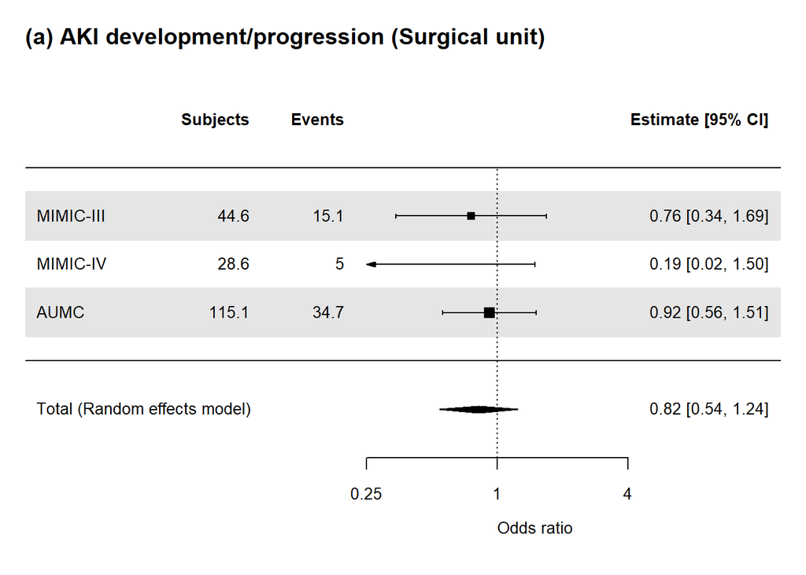

```r
#Forrestplot
FP2("wgt_man_Ovlp_MIMIC3_surg.rds", FORMULA_ovl2_surg)
FP2("wgt_man_Ovlp_MIMIC4_surg.rds", FORMULA_ovl2_surg)
FP2("wgt_man_Ovlp_AUMC_surg.rds", FORMULA_ovl2_surg)

surg_METADF0 <- rbind(
  readRDS("ORRES_wgt_man_Ovlp_MIMIC3_surg.rds") %>% mutate("dataset"="MIMIC-III"),
  readRDS("ORRES_wgt_man_Ovlp_MIMIC4_surg.rds") %>% mutate("dataset"="MIMIC-IV"),
  readRDS("ORRES_wgt_man_Ovlp_AUMC_surg.rds") %>% mutate("dataset"="AUMC"))
surg_METADF_AKID <- surg_METADF0 %>% subset(outcome=="outcome_KDIGO_inc_or_death")
surg_METADF_AKI <- surg_METADF0 %>% subset(outcome=="outcome_KDIGO_inc")
surg_METADF_HD <- surg_METADF0 %>% subset(outcome=="outcome_new_dial")
surg_METADF_D <- surg_METADF0 %>% subset(outcome=="death_in_7d")
surg_METADF_HDD <- surg_METADF0 %>% subset(outcome=="outcome_HDD_in7d")
surg_METARES_AKID <- rma(yi = Estimate, sei = Std.Error, method = "REML", data = surg_METADF_AKID)
surg_METARES_AKI <- rma(yi = Estimate, sei = Std.Error, method = "REML", data = surg_METADF_AKI)
surg_METARES_HD <- rma(yi = Estimate, sei = Std.Error, method = "REML", data = surg_METADF_HD)
surg_METARES_D <- rma(yi = Estimate, sei = Std.Error, method = "REML", data = surg_METADF_D)
surg_METARES_HDD <- rma(yi = Estimate, sei = Std.Error, method = "REML", data = surg_METADF_HDD)

METAF(surg_METARES_AKI, SCALEA1, SCALEB1, SCALEC1, "(a) AKI development/progression (Surgical unit)")
```

```r
surg_METARES_AKI
```

```
##
## Random-Effects Model (k = 3; tau^2 estimator: REML)
##
## tau^2 (estimated amount of total heterogeneity): 0.0000 (SE = 0.1591)
## tau (square root of estimated tau^2 value):      0.0017
## I^2 (total heterogeneity / total variability):   0.00%
## H^2 (total variability / sampling variability):  1.00
##
## Test for Heterogeneity:
## Q(df = 2) = 2.1816, p-val = 0.3359
##
## Model Results:
##
## estimate      se     zval    pval    ci.lb   ci.ub
##  -0.1973  0.2103  -0.9379  0.3483  -0.6095  0.2150
##
## ---
## Signif. codes:  0 '***' 0.001 '**' 0.01 '*' 0.05 '.' 0.1 ' ' 1
```

```r
surg_METADF_AKI %>% dplyr::select(dataset, OR, LCI, UCI, 'Pr(>|z|)') %>% remove_rownames()
```

```
##     dataset        OR        LCI      UCI  Pr(>|z|)
## 1 MIMIC-III 0.7586894 0.34122458 1.686894 0.4981588
## 2  MIMIC-IV 0.1876889 0.02353042 1.497088 0.1143162
## 3      AUMC 0.9201054 0.56104648 1.508955 0.7414694
```

__

__

#### 8d. Backgrounds, outcomes, matching quality, and forest plot among those **non-srugery**

```r
#1. overlap-PSM using MIMIC3, Older
OVLP(comb_DF2ovl %>% subset(dataset=="MIMIC3"&dep_type2=="Non-surgery"), FORMULA_ovl2_surg, "Ovlp_MIMIC3_nonsurg", "**Ovlp, MIMIC-III, Non-surgical unit**")
```

| **Characteristic** | **Ovlp, MIMIC-III, Non-surgical unit** **I/C** N=35.8<sup>1</sup> | **Ovlp, MIMIC-III, Non-surgical unit** **NCC** N=35.8<sup>1</sup> | **p-value**<sup>2</sup> |  |
| --- | --- | --- | --- | --- |
| dataset |  |  |  |  |
| MIMIC3 | 35.8 (100.0%) | 35.8 (100.0%) |  |  |
| age_group |  |  | 0.87 |  |
| 18-39 | 3.1 (8.8%) | 2.9 (8.2%) |  |  |
| 40-49 | 1.6 (4.4%) | 3.3 (9.2%) |  |  |
| 50-59 | 7.6 (21.2%) | 6.9 (19.4%) |  |  |
| 60-69 | 8.7 (24.3%) | 6.8 (18.9%) |  |  |
| 70-79 | 8.8 (24.5%) | 8.9 (24.9%) |  |  |
| 80+ | 6.0 (16.7%) | 7.0 (19.4%) |  |  |
| sex |  |  | >0.99 |  |
| Female | 19.5 (54.6%) | 19.5 (54.6%) |  |  |
| Male | 16.3 (45.4%) | 16.3 (45.4%) |  |  |
| bmi | 26.3 (24.5, 29.0) | 27.7 (23.9, 33.1) | 0.54 |  |
| Unknown | 18 | 24 |  |  |
| weight | 71.0 (62.6, 86.0) | 76.0 (63.0, 93.5) | 0.38 |  |
| Unknown | 4 | 7 |  |  |
| ICU type |  |  |  |  |
| Non-surgery | 35.8 (100.0%) | 35.8 (100.0%) |  |  |
| drug_name |  |  |  |  |
| Imipenem/cilastatin | 35.8 (100.0%) | 0.0 (0.0%) |  |  |
| Imipenem/cilastatin/relebactam | 0.0 (0.0%) | 0.0 (0.0%) |  |  |
| Meropenem | 0.0 (0.0%) | 35.8 (100.0%) |  |  |
| Doripenem | 0.0 (0.0%) | 0.0 (0.0%) |  |  |
| Ertapenem | 0.0 (0.0%) | 0.0 (0.0%) |  |  |
| Overdose in first 24h |  |  | 0.84 |  |
| not_over | 35.1 (97.9%) | 34.9 (97.4%) |  |  |
| over | 0.7 (2.1%) | 0.9 (2.6%) |  |  |
| Relative initiation dose (with near eGFR) | 0.3 (0.2, 0.5) | 0.3 (0.3, 0.5) | 0.27 |  |
| sofa | 5.0 (3.0, 8.0) | 5.0 (3.0, 7.0) | 0.94 |  |
| qsofa | 1.0 (0.0, 1.0) | 1.0 (0.0, 1.0) | 0.70 |  |
| Unknown | 0 | 2 |  |  |
| sirs | 2.0 (1.0, 3.0) | 2.0 (1.0, 3.0) | 0.82 |  |
| pre_blood_culture | 29.7 (83.0%) | 29.7 (83.0%) | >0.99 |  |
| pre nephrotoxic drugs use | 22.8 (63.7%) | 22.8 (63.7%) | >0.99 |  |
| pre vancomycin use | 19.4 (54.3%) | 20.1 (56.2%) | 0.82 |  |
| pre aminoglycosied use | 2.6 (7.1%) | 2.9 (8.1%) | 0.84 |  |
| pre NSAIDs use | 5.1 (14.3%) | 4.8 (13.3%) | 0.86 |  |
| pre contrast agent use | 0.0 (0.0%) | 0.0 (0.0%) |  |  |
| pre vasopressor use | 14.4 (40.1%) | 14.4 (40.1%) | >0.99 |  |
| pre ventilation | 22.4 (62.5%) | 23.7 (66.1%) | 0.65 |  |
| Baseline sCr | 0.9 (0.6, 1.6) | 1.0 (0.6, 1.5) | 0.86 |  |
| sCr at treatment start | 1.1 (0.8, 1.9) | 1.2 (0.8, 1.8) | 0.86 |  |
| AKI stage at treatment start |  |  | 0.48 |  |
| 0 | 23.2 (64.7%) | 24.4 (68.1%) |  |  |
| 1 | 11.8 (33.0%) | 9.4 (26.3%) |  |  |
| 2 | 0.8 (2.2%) | 2.0 (5.6%) |  |  |
| near_eGFR | 62.5 (30.9, 92.3) | 56.9 (32.9, 91.9) | 0.89 |  |
| observation time | 168.0 (123.7, 168.0) | 168.0 (149.4, 168.0) | 0.40 |  |
| Cencsored with drug change | 1.7 (4.6%) | 0.0 (0.0%) | 0.15 |  |
| RRT at treatment start | 0.0 (0.0%) | 0.0 (0.0%) |  |  |
| O, AKI develop/progress | 8.3 (23.1%) | 14.8 (41.3%) | 0.029 |  |
| O, Death | 5.4 (15.0%) | 6.6 (18.5%) | 0.59 |  |
| O, AKI d/p or death | 12.1 (33.7%) | 16.6 (46.4%) | 0.13 |  |
| O, RRT-intervention | 0.8 (2.4%) | 2.4 (6.8%) | 0.28 |  |
| O, Death or RRT-intervention | 6.2 (17.4%) | 8.6 (23.9%) | 0.35 |  |
| total_dose_ICM | 2,375.3 (1,000.0, 3,500.0) | 3,500.0 (2,000.0, 7,000.0) | <0.001 |  |
| total_dose_recabrio | NA (NA, NA) | NA (NA, NA) |  |  |
| Unknown | 36 | 36 |  |  |
| total_dose_erta | NA (NA, NA) | NA (NA, NA) |  |  |
| Unknown | 36 | 36 |  |  |
| total_dose_dori | NA (NA, NA) | NA (NA, NA) |  |  |
| Unknown | 36 | 36 |  |  |
| ini24h_dose_ICM | 500.0 (500.0, 750.0) | 1,000.0 (500.0, 1,000.0) | <0.001 |  |
| ini24h_dose_recabrio | NA (NA, NA) | NA (NA, NA) |  |  |
| Unknown | 36 | 36 |  |  |
| ini24h_dose_erta | NA (NA, NA) | NA (NA, NA) |  |  |
| Unknown | 36 | 36 |  |  |
| ini24h_dose_dori | NA (NA, NA) | NA (NA, NA) |  |  |
| Unknown | 36 | 36 |  |  |
| last_drug_in_obs | 96.0 (48.0, 168.0) | 144.0 (72.0, 168.0) | 0.021 |  |

<sup>1</sup> n (%); Median (Q1, Q3)  
<sup>2</sup> NA; Pearson’s X^2: Rao & Scott adjustment; Design-based KruskalWallis test

```r
#2. overlap-PSM using MIMIC4, Older
OVLP(comb_DF2ovl %>% subset(dataset=="miiv"&dep_type2=="Non-surgery"), FORMULA_ovl2_surg, "Ovlp_MIMIC4_nonsurg", "**Ovlp, MIMIC-IV, Non-surgical unit**")
```

| **Characteristic** | **Ovlp, MIMIC-IV, Non-surgical unit** **I/C** N=70.4<sup>1</sup> | **Ovlp, MIMIC-IV, Non-surgical unit** **NCC** N=70.4<sup>1</sup> | **p-value**<sup>2</sup> |  |
| --- | --- | --- | --- | --- |
| dataset |  |  |  |  |
| miiv | 70.4 (100.0%) | 70.4 (100.0%) |  |  |
| age_group |  |  | 0.63 |  |
| 18-39 | 5.8 (8.3%) | 4.7 (6.7%) |  |  |
| 40-49 | 6.8 (9.7%) | 6.3 (9.0%) |  |  |
| 50-59 | 8.7 (12.4%) | 13.8 (19.6%) |  |  |
| 60-69 | 20.3 (28.8%) | 18.1 (25.8%) |  |  |
| 70-79 | 17.3 (24.6%) | 14.6 (20.7%) |  |  |
| 80+ | 11.4 (16.2%) | 12.9 (18.3%) |  |  |
| sex |  |  | >0.99 |  |
| Female | 32.7 (46.5%) | 32.7 (46.5%) |  |  |
| Male | 37.6 (53.5%) | 37.6 (53.5%) |  |  |
| bmi | 27.1 (24.8, 31.4) | 27.4 (23.4, 33.0) | 0.82 |  |
| Unknown | 39 | 27 |  |  |
| weight | 81.0 (68.4, 99.6) | 77.0 (64.0, 94.0) | 0.18 |  |
| Unknown | 5 | 5 |  |  |
| ICU type |  |  |  |  |
| Non-surgery | 70.4 (100.0%) | 70.4 (100.0%) |  |  |
| drug_name |  |  |  |  |
| Imipenem/cilastatin | 70.4 (100.0%) | 0.0 (0.0%) |  |  |
| Imipenem/cilastatin/relebactam | 0.0 (0.0%) | 0.0 (0.0%) |  |  |
| Meropenem | 0.0 (0.0%) | 69.9 (99.3%) |  |  |
| Doripenem | 0.0 (0.0%) | 0.2 (0.2%) |  |  |
| Ertapenem | 0.0 (0.0%) | 0.3 (0.5%) |  |  |
| Overdose in first 24h |  |  | 0.97 |  |
| not_over | 69.4 (98.6%) | 69.4 (98.7%) |  |  |
| over | 1.0 (1.4%) | 0.9 (1.3%) |  |  |
| Relative initiation dose (with near eGFR) | 0.3 (0.2, 0.3) | 0.3 (0.3, 0.5) | 0.002 |  |
| sofa | 5.0 (3.0, 8.0) | 6.0 (3.0, 9.0) | 0.32 |  |
| qsofa | 1.0 (0.0, 1.0) | 1.0 (0.0, 1.0) | 0.50 |  |
| Unknown | 0 | 0 |  |  |
| sirs | 2.0 (1.0, 3.0) | 2.0 (1.0, 3.0) | 0.92 |  |
| pre_blood_culture | 53.9 (76.6%) | 53.9 (76.6%) | >0.99 |  |
| pre nephrotoxic drugs use | 55.9 (79.5%) | 55.9 (79.5%) | >0.99 |  |
| pre vancomycin use | 50.2 (71.3%) | 53.8 (76.5%) | 0.31 |  |
| pre aminoglycosied use | 8.7 (12.4%) | 5.8 (8.2%) | 0.20 |  |
| pre NSAIDs use | 4.8 (6.9%) | 5.9 (8.4%) | 0.64 |  |
| pre contrast agent use | 1.0 (1.4%) | 0.5 (0.7%) | 0.56 |  |
| pre vasopressor use | 7.7 (10.9%) | 7.7 (10.9%) | >0.99 |  |
| pre ventilation | 11.5 (16.4%) | 6.8 (9.7%) | 0.064 |  |
| Baseline sCr | 1.0 (0.7, 1.6) | 1.0 (0.7, 1.5) | 0.96 |  |
| sCr at treatment start | 1.1 (0.7, 2.0) | 1.2 (0.8, 1.9) | 0.97 |  |
| AKI stage at treatment start |  |  | 0.97 |  |
| 0 | 54.9 (78.0%) | 55.1 (78.4%) |  |  |
| 1 | 12.6 (17.9%) | 12.0 (17.1%) |  |  |
| 2 | 2.9 (4.1%) | 3.2 (4.5%) |  |  |
| near_eGFR | 58.8 (34.1, 93.5) | 62.5 (34.3, 95.9) | 0.95 |  |
| observation time | 168.0 (122.5, 168.0) | 168.0 (139.4, 168.0) | 0.68 |  |
| Cencsored with drug change | 2.9 (4.1%) | 0.0 (0.0%) | 0.076 |  |
| RRT at treatment start | 0.0 (0.0%) | 0.0 (0.0%) |  |  |
| O, AKI develop/progress | 29.8 (42.4%) | 22.9 (32.6%) | 0.082 |  |
| O, Death | 12.5 (17.8%) | 12.0 (17.0%) | 0.87 |  |
| O, AKI d/p or death | 30.8 (43.8%) | 27.9 (39.7%) | 0.48 |  |
| O, RRT-intervention | 2.9 (4.1%) | 4.9 (7.0%) | 0.34 |  |
| O, Death or RRT-intervention | 13.5 (19.1%) | 15.1 (21.4%) | 0.64 |  |
| total_dose_ICM | 1,604.2 (479.2, 3,458.3) | 2,354.2 (1,125.0, 3,791.7) | 0.001 |  |
| Unknown | 0 | 1 |  |  |
| total_dose_recabrio | NA (NA, NA) | NA (NA, NA) |  |  |
| Unknown | 70 | 70 |  |  |
| total_dose_erta | NA (NA, NA) | NA (NA, NA) |  |  |
| Unknown | 70 | 70 |  |  |
| total_dose_dori | NA (NA, NA) | NA (NA, NA) |  |  |
| Unknown | 70 | 70 |  |  |
| ini24h_dose_ICM | 500.0 (500.0, 500.0) | 1,000.0 (500.0, 1,000.0) | <0.001 |  |
| Unknown | 0 | 1 |  |  |
| ini24h_dose_recabrio | NA (NA, NA) | NA (NA, NA) |  |  |
| Unknown | 70 | 70 |  |  |
| ini24h_dose_erta | NA (NA, NA) | NA (NA, NA) |  |  |
| Unknown | 70 | 70 |  |  |
| ini24h_dose_dori | NA (NA, NA) | NA (NA, NA) |  |  |
| Unknown | 70 | 70 |  |  |
| last_drug_in_obs | 60.0 (23.0, 168.0) | 88.4 (32.0, 168.0) | 0.12 |  |

<sup>1</sup> n (%); Median (Q1, Q3)  
<sup>2</sup> NA; Pearson’s X^2: Rao & Scott adjustment; Design-based KruskalWallis test

```r
#3. overlap-PSM using AUMC, Older
OVLP(comb_DF2ovl %>% subset(dataset=="AUMC"&dep_type2=="Non-surgery"), FORMULA_ovl2_surg, "Ovlp_AUMC_nonsurg", "**Ovlp, AUMC, Non-surgical unit**")
```

| **Characteristic** | **Ovlp, AUMC, Non-surgical unit** **I/C** N=84.6<sup>1</sup> | **Ovlp, AUMC, Non-surgical unit** **NCC** N=84.6<sup>1</sup> | **p-value**<sup>2</sup> |  |
| --- | --- | --- | --- | --- |
| dataset |  |  |  |  |
| AUMC | 84.6 (100.0%) | 84.6 (100.0%) |  |  |
| age_group |  |  | 0.71 |  |
| 18-39 | 11.5 (13.6%) | 14.3 (16.9%) |  |  |
| 40-49 | 10.2 (12.0%) | 7.0 (8.3%) |  |  |
| 50-59 | 18.4 (21.7%) | 16.4 (19.4%) |  |  |
| 60-69 | 24.3 (28.7%) | 24.3 (28.7%) |  |  |
| 70-79 | 16.5 (19.5%) | 19.9 (23.5%) |  |  |
| 80+ | 3.8 (4.5%) | 2.7 (3.2%) |  |  |
| sex |  |  | >0.99 |  |
| Female | 31.6 (37.4%) | 31.6 (37.4%) |  |  |
| Male | 53.0 (62.6%) | 53.0 (62.6%) |  |  |
| bmi | 24.5 (21.9, 27.8) | 24.8 (21.9, 27.8) | 0.10 |  |
| Unknown | 5 | 2 |  |  |
| weight | 75.0 (65.0, 85.0) | 85.0 (75.0, 95.0) | 0.022 |  |
| Unknown | 3 | 2 |  |  |
| ICU type |  |  |  |  |
| Non-surgery | 84.6 (100.0%) | 84.6 (100.0%) |  |  |
| drug_name |  |  |  |  |
| Imipenem/cilastatin | 84.6 (100.0%) | 0.0 (0.0%) |  |  |
| Imipenem/cilastatin/relebactam | 0.0 (0.0%) | 0.0 (0.0%) |  |  |
| Meropenem | 0.0 (0.0%) | 84.6 (100.0%) |  |  |
| Doripenem | 0.0 (0.0%) | 0.0 (0.0%) |  |  |
| Ertapenem | 0.0 (0.0%) | 0.0 (0.0%) |  |  |
| Overdose in first 24h |  |  |  |  |
| not_over | 84.6 (100.0%) | 84.6 (100.0%) |  |  |
| Relative initiation dose (with near eGFR) | 0.3 (0.2, 0.3) | 0.5 (0.3, 0.7) | <0.001 |  |
| sofa | 7.0 (5.0, 9.0) | 7.0 (4.0, 9.0) | 0.46 |  |
| Unknown | 13 | 15 |  |  |
| qsofa | 1.0 (0.0, 1.0) | 1.0 (0.0, 1.0) | 0.72 |  |
| Unknown | 0 | 0 |  |  |
| sirs | 2.0 (1.0, 3.0) | 2.0 (1.0, 3.0) | 0.88 |  |
| pre_blood_culture | 11.6 (13.7%) | 11.6 (13.7%) | >0.99 |  |
| pre nephrotoxic drugs use | 44.8 (52.9%) | 44.8 (52.9%) | >0.99 |  |
| pre vancomycin use | 37.9 (44.8%) | 39.0 (46.1%) | 0.80 |  |
| pre aminoglycosied use | 11.6 (13.7%) | 7.5 (8.8%) | 0.16 |  |
| pre NSAIDs use | 1.3 (1.5%) | 6.3 (7.4%) | 0.004 |  |
| pre contrast agent use | 0.5 (0.5%) | 0.0 (0.0%) | 0.16 |  |
| pre vasopressor use | 56.9 (67.3%) | 56.9 (67.3%) | >0.99 |  |
| pre ventilation | 58.9 (69.6%) | 52.4 (61.9%) | 0.13 |  |
| Baseline sCr | 0.8 (0.6, 1.2) | 0.7 (0.6, 1.2) | 0.36 |  |
| sCr at treatment start | 1.0 (0.7, 1.5) | 0.9 (0.6, 1.5) | 0.53 |  |
| AKI stage at treatment start |  |  | 0.80 |  |
| 0 | 63.0 (74.4%) | 63.9 (75.5%) |  |  |
| 1 | 17.9 (21.1%) | 16.0 (18.9%) |  |  |
| 2 | 3.8 (4.5%) | 4.7 (5.6%) |  |  |
| near_eGFR | 77.3 (47.9, 103.8) | 88.8 (45.0, 107.3) | 0.54 |  |
| observation time | 168.0 (65.8, 168.0) | 137.6 (53.6, 168.0) | 0.13 |  |
| Cencsored with drug change | 2.7 (3.2%) | 0.0 (0.0%) | 0.002 |  |
| RRT at treatment start | 0.0 (0.0%) | 0.0 (0.0%) |  |  |
| O, AKI develop/progress | 26.1 (30.8%) | 23.1 (27.3%) | 0.48 |  |
| O, Death | 11.0 (13.0%) | 10.9 (12.8%) | 0.97 |  |
| O, AKI d/p or death | 30.0 (35.4%) | 29.0 (34.2%) | 0.82 |  |
| O, RRT-intervention | 7.9 (9.3%) | 7.7 (9.1%) | 0.95 |  |
| O, Death or RRT-intervention | 16.2 (19.2%) | 15.5 (18.3%) | 0.83 |  |
| total_dose_ICM | 8,500.0 (3,500.0, 16,000.0) | 10,000.0 (5,000.0, 27,000.0) | 0.011 |  |
| total_dose_recabrio | NA (NA, NA) | NA (NA, NA) |  |  |
| Unknown | 85 | 85 |  |  |
| total_dose_erta | NA (NA, NA) | NA (NA, NA) |  |  |
| Unknown | 85 | 85 |  |  |
| total_dose_dori | NA (NA, NA) | NA (NA, NA) |  |  |
| Unknown | 85 | 85 |  |  |
| ini24h_dose_ICM | 500.0 (500.0, 500.0) | 1,000.0 (1,000.0, 2,000.0) | <0.001 |  |
| ini24h_dose_recabrio | NA (NA, NA) | NA (NA, NA) |  |  |
| Unknown | 85 | 85 |  |  |
| ini24h_dose_erta | NA (NA, NA) | NA (NA, NA) |  |  |
| Unknown | 85 | 85 |  |  |
| ini24h_dose_dori | NA (NA, NA) | NA (NA, NA) |  |  |
| Unknown | 85 | 85 |  |  |
| last_drug_in_obs | 110.0 (41.6, 168.0) | 72.0 (31.9, 168.0) | 0.025 |  |

<sup>1</sup> n (%); Median (Q1, Q3)  
<sup>2</sup> NA; Pearson’s X^2: Rao & Scott adjustment; Design-based KruskalWallis test

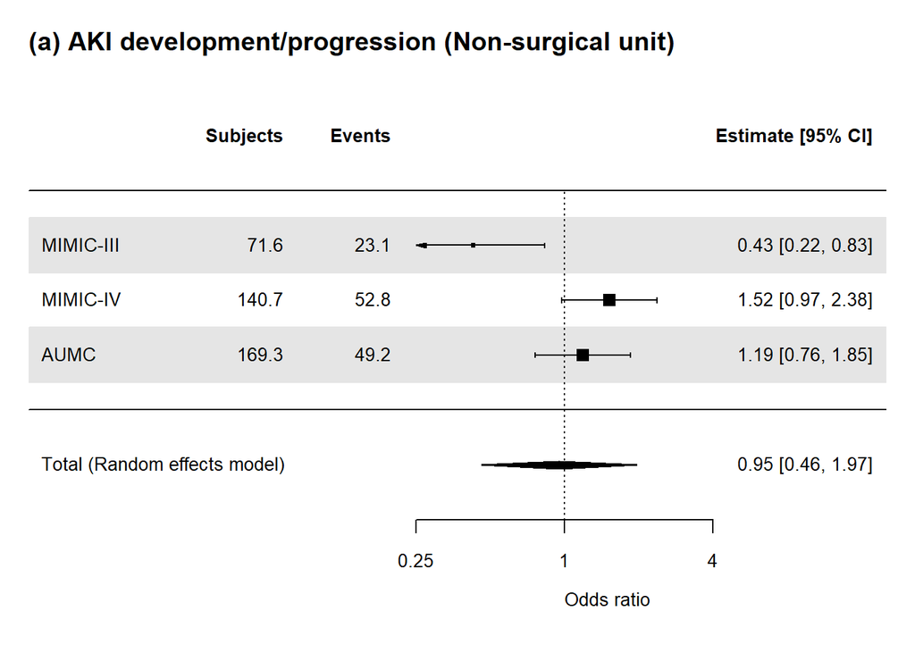

```r
FP2("wgt_man_Ovlp_MIMIC4_nonsurg.rds", FORMULA_ovl2_surg)
FP2("wgt_man_Ovlp_MIMIC3_nonsurg.rds", FORMULA_ovl2_surg)
FP2("wgt_man_Ovlp_AUMC_nonsurg.rds", FORMULA_ovl2_surg)

nonsurg_METADF0 <- rbind(
  readRDS("ORRES_wgt_man_Ovlp_MIMIC3_nonsurg.rds") %>% mutate("dataset"="MIMIC-III"),
  readRDS("ORRES_wgt_man_Ovlp_MIMIC4_nonsurg.rds") %>% mutate("dataset"="MIMIC-IV"),
  readRDS("ORRES_wgt_man_Ovlp_AUMC_nonsurg.rds") %>% mutate("dataset"="AUMC"))
nonsurg_METADF_AKID <- nonsurg_METADF0 %>% subset(outcome=="outcome_KDIGO_inc_or_death")
nonsurg_METADF_AKI <- nonsurg_METADF0 %>% subset(outcome=="outcome_KDIGO_inc")
nonsurg_METADF_HD <- nonsurg_METADF0 %>% subset(outcome=="outcome_new_dial")
nonsurg_METADF_D <- nonsurg_METADF0 %>% subset(outcome=="death_in_7d")
nonsurg_METADF_HDD <- nonsurg_METADF0 %>% subset(outcome=="outcome_HDD_in7d")

nonsurg_METARES_AKID <- rma(yi = Estimate, sei = Std.Error, method = "REML", data = nonsurg_METADF_AKID)
nonsurg_METARES_AKI <-rma(yi = Estimate, sei = Std.Error, method = "REML", data = nonsurg_METADF_AKI)
nonsurg_METARES_HD <- rma(yi = Estimate, sei = Std.Error, method = "REML", data = nonsurg_METADF_HD)
nonsurg_METARES_D <- rma(yi = Estimate, sei = Std.Error, method = "REML", data = nonsurg_METADF_D)
nonsurg_METARES_HDD <- rma(yi = Estimate, sei = Std.Error, method = "REML", data = nonsurg_METADF_HDD)

METAF(nonsurg_METARES_AKI, SCALEA1, SCALEB1, SCALEC1, "(a) AKI development/progression (Non-surgical unit)")
```

```r
nonsurg_METARES_AKI
```

```
##
## Random-Effects Model (k = 3; tau^2 estimator: REML)
##
## tau^2 (estimated amount of total heterogeneity): 0.3384 (SE = 0.4095)
## tau (square root of estimated tau^2 value):      0.5817
## I^2 (total heterogeneity / total variability):   83.55%
## H^2 (total variability / sampling variability):  6.08
##
## Test for Heterogeneity:
## Q(df = 2) = 9.8771, p-val = 0.0072
##
## Model Results:
##
## estimate      se     zval    pval    ci.lb   ci.ub
##  -0.0482  0.3693  -0.1305  0.8962  -0.7720  0.6756
##
## ---
## Signif. codes:  0 '***' 0.001 '**' 0.01 '*' 0.05 '.' 0.1 ' ' 1
```

```r
nonsurg_METADF_AKI %>% dplyr::select(dataset, OR, LCI, UCI, 'Pr(>|z|)') %>% remove_rownames()
```

```
##     dataset        OR       LCI       UCI   Pr(>|z|)
## 1 MIMIC-III 0.4277227 0.2198883 0.8319986 0.01235785
## 2  MIMIC-IV 1.5217595 0.9728417 2.3803995 0.06586459
## 3      AUMC 1.1885383 0.7633546 1.8505466 0.44450781
```

__

#### 9c. Backgrounds, outcomes, matching quality, and forrest plot among those **previous bood culture** at treatment start.

```r
FORMULA_ovl2_bc <- drug01 ~  age_cat + sex + sirs + dep_type2 + nt_drug + vasopressor + base_crea + near_crea +  base_KDIGO
#1. overlap-PSM using MIMIC3, Older
OVLP(comb_DF2ovl %>% subset(dataset=="MIMIC3"&pre_blood_culture==T), FORMULA_ovl2_bc, "Ovlp_MIMIC3_bc", "**Ovlp, MIMIC-III, pre BC**")
```

| **Characteristic** | **Ovlp, MIMIC-III, pre BC** **I/C** N=47.5<sup>1</sup> | **Ovlp, MIMIC-III, pre BC** **NCC** N=47.5<sup>1</sup> | **p-value**<sup>2</sup> |  |
| --- | --- | --- | --- | --- |
| dataset |  |  |  |  |
| MIMIC3 | 47.5 (100.0%) | 47.5 (100.0%) |  |  |
| age_group |  |  | 0.70 |  |
| 18-39 | 3.4 (7.1%) | 3.9 (8.3%) |  |  |
| 40-49 | 3.8 (8.0%) | 4.2 (8.8%) |  |  |
| 50-59 | 9.7 (20.4%) | 8.6 (18.1%) |  |  |
| 60-69 | 11.6 (24.4%) | 8.7 (18.4%) |  |  |
| 70-79 | 9.7 (20.4%) | 14.2 (29.9%) |  |  |
| 80+ | 9.4 (19.7%) | 7.9 (16.6%) |  |  |
| sex |  |  | >0.99 |  |
| Female | 24.2 (50.8%) | 24.2 (50.8%) |  |  |
| Male | 23.3 (49.2%) | 23.3 (49.2%) |  |  |
| bmi | 27.5 (24.5, 29.2) | 27.7 (23.4, 33.3) | 0.93 |  |
| Unknown | 21 | 24 |  |  |
| weight | 78.0 (65.0, 90.0) | 77.5 (62.5, 95.3) | 0.78 |  |
| Unknown | 5 | 7 |  |  |
| ICU type |  |  | >0.99 |  |
| Non-surgery | 29.8 (62.8%) | 29.8 (62.8%) |  |  |
| Surgery | 17.7 (37.2%) | 17.7 (37.2%) |  |  |
| drug_name |  |  |  |  |
| Imipenem/cilastatin | 47.5 (100.0%) | 0.0 (0.0%) |  |  |
| Imipenem/cilastatin/relebactam | 0.0 (0.0%) | 0.0 (0.0%) |  |  |
| Meropenem | 0.0 (0.0%) | 47.5 (100.0%) |  |  |
| Doripenem | 0.0 (0.0%) | 0.0 (0.0%) |  |  |
| Ertapenem | 0.0 (0.0%) | 0.0 (0.0%) |  |  |
| Overdose in first 24h |  |  | 0.066 |  |
| not_over | 47.5 (100.0%) | 46.7 (98.3%) |  |  |
| over | 0.0 (0.0%) | 0.8 (1.7%) |  |  |
| Relative initiation dose (with near eGFR) | 0.3 (0.3, 0.5) | 0.3 (0.3, 0.5) | 0.24 |  |
| sofa | 5.0 (3.0, 9.0) | 4.0 (2.0, 7.0) | 0.37 |  |
| qsofa | 1.0 (0.0, 1.0) | 1.0 (0.0, 1.0) | 0.42 |  |
| Unknown | 0 | 1 |  |  |
| sirs | 2.0 (1.0, 3.0) | 2.0 (1.0, 3.0) | 0.93 |  |
| pre_blood_culture | 47.5 (100.0%) | 47.5 (100.0%) |  |  |
| pre nephrotoxic drugs use | 29.8 (62.8%) | 29.8 (62.8%) | >0.99 |  |
| pre vancomycin use | 25.6 (54.0%) | 27.6 (58.2%) | 0.56 |  |
| pre aminoglycosied use | 5.8 (12.1%) | 4.0 (8.5%) | 0.38 |  |
| pre NSAIDs use | 6.0 (12.7%) | 5.4 (11.3%) | 0.78 |  |
| pre contrast agent use | 0.0 (0.0%) | 0.0 (0.0%) |  |  |
| pre vasopressor use | 22.7 (47.8%) | 22.7 (47.8%) | >0.99 |  |
| pre ventilation | 31.6 (66.6%) | 33.2 (69.9%) | 0.62 |  |
| Baseline sCr | 0.9 (0.6, 1.4) | 0.9 (0.6, 1.4) | 0.97 |  |
| sCr at treatment start | 1.1 (0.8, 1.7) | 1.1 (0.7, 1.7) | 0.89 |  |
| AKI stage at treatment start |  |  | 0.81 |  |
| 0 | 35.4 (74.4%) | 34.8 (73.2%) |  |  |
| 1 | 10.5 (22.2%) | 11.7 (24.6%) |  |  |
| 2 | 1.6 (3.4%) | 1.0 (2.2%) |  |  |
| near_eGFR | 62.5 (36.1, 92.3) | 62.6 (38.8, 95.9) | 0.87 |  |
| observation time | 168.0 (168.0, 168.0) | 168.0 (168.0, 168.0) | 0.75 |  |
| Cencsored with drug change | 2.4 (5.1%) | 0.2 (0.3%) | 0.002 |  |
| RRT at treatment start | 0.0 (0.0%) | 0.0 (0.0%) |  |  |
| O, AKI develop/progress | 12.1 (25.5%) | 18.7 (39.3%) | 0.050 |  |
| O, Death | 4.8 (10.2%) | 7.3 (15.4%) | 0.30 |  |
| O, AKI d/p or death | 13.8 (29.0%) | 20.9 (43.9%) | 0.039 |  |
| O, RRT-intervention | 0.9 (1.9%) | 2.4 (5.0%) | 0.32 |  |
| O, Death or RRT-intervention | 5.7 (12.0%) | 9.2 (19.3%) | 0.20 |  |
| total_dose_ICM | 3,000.0 (1,500.0, 3,750.0) | 4,000.0 (2,500.0, 7,000.0) | <0.001 |  |
| total_dose_recabrio | NA (NA, NA) | NA (NA, NA) |  |  |
| Unknown | 47 | 47 |  |  |
| total_dose_erta | NA (NA, NA) | NA (NA, NA) |  |  |
| Unknown | 47 | 47 |  |  |
| total_dose_dori | NA (NA, NA) | NA (NA, NA) |  |  |
| Unknown | 47 | 47 |  |  |
| ini24h_dose_ICM | 500.0 (500.0, 750.0) | 1,000.0 (500.0, 1,000.0) | <0.001 |  |
| ini24h_dose_recabrio | NA (NA, NA) | NA (NA, NA) |  |  |
| Unknown | 47 | 47 |  |  |
| ini24h_dose_erta | NA (NA, NA) | NA (NA, NA) |  |  |
| Unknown | 47 | 47 |  |  |
| ini24h_dose_dori | NA (NA, NA) | NA (NA, NA) |  |  |
| Unknown | 47 | 47 |  |  |
| last_drug_in_obs | 144.0 (48.0, 168.0) | 168.0 (72.0, 168.0) | 0.16 |  |

<sup>1</sup> n (%); Median (Q1, Q3)  
<sup>2</sup> NA; Pearson’s X^2: Rao & Scott adjustment; Design-based KruskalWallis test

```r
#2. overlap-PSM using MIMIC4, Older
OVLP(comb_DF2ovl %>% subset(dataset=="miiv"&pre_blood_culture==T), FORMULA_ovl2_bc, "Ovlp_MIMIC4_bc", "**Ovlp, MIMIC-IV, pre BC**")
```

| **Characteristic** | **Ovlp, MIMIC-IV, pre BC** **I/C** N=65.6<sup>1</sup> | **Ovlp, MIMIC-IV, pre BC** **NCC** N=65.6<sup>1</sup> | **p-value**<sup>2</sup> |  |
| --- | --- | --- | --- | --- |
| dataset |  |  |  |  |
| miiv | 65.6 (100.0%) | 65.6 (100.0%) |  |  |
| age_group |  |  | 0.23 |  |
| 18-39 | 4.9 (7.4%) | 4.6 (7.0%) |  |  |
| 40-49 | 7.8 (11.9%) | 5.7 (8.7%) |  |  |
| 50-59 | 5.8 (8.8%) | 12.6 (19.1%) |  |  |
| 60-69 | 22.2 (33.8%) | 17.6 (26.8%) |  |  |
| 70-79 | 15.4 (23.5%) | 14.3 (21.9%) |  |  |
| 80+ | 9.5 (14.5%) | 10.8 (16.5%) |  |  |
| sex |  |  | >0.99 |  |
| Female | 29.8 (45.4%) | 29.8 (45.4%) |  |  |
| Male | 35.8 (54.6%) | 35.8 (54.6%) |  |  |
| bmi | 30.0 (25.2, 36.1) | 27.5 (23.6, 33.3) | 0.12 |  |
| Unknown | 35 | 23 |  |  |
| weight | 81.0 (70.4, 100.0) | 78.5 (65.5, 95.0) | 0.13 |  |
| Unknown | 5 | 6 |  |  |
| ICU type |  |  | >0.99 |  |
| Non-surgery | 53.8 (82.1%) | 53.8 (82.1%) |  |  |
| Surgery | 11.8 (17.9%) | 11.8 (17.9%) |  |  |
| drug_name |  |  | <0.001 |  |
| Imipenem/cilastatin | 64.6 (98.5%) | 0.0 (0.0%) |  |  |
| Imipenem/cilastatin/relebactam | 1.0 (1.5%) | 0.0 (0.0%) |  |  |
| Meropenem | 0.0 (0.0%) | 65.2 (99.4%) |  |  |
| Doripenem | 0.0 (0.0%) | 0.2 (0.2%) |  |  |
| Ertapenem | 0.0 (0.0%) | 0.2 (0.3%) |  |  |
| Overdose in first 24h |  |  | <0.001 |  |
| not_over | 65.6 (100.0%) | 64.9 (98.9%) |  |  |
| over | 0.0 (0.0%) | 0.7 (1.1%) |  |  |
| Relative initiation dose (with near eGFR) | 0.3 (0.2, 0.3) | 0.3 (0.3, 0.5) | 0.002 |  |
| sofa | 5.0 (3.0, 8.0) | 6.0 (3.0, 9.0) | 0.42 |  |
| qsofa | 1.0 (0.0, 1.0) | 1.0 (0.0, 1.0) | 0.62 |  |
| Unknown | 0 | 0 |  |  |
| sirs | 2.0 (1.0, 3.0) | 2.0 (1.0, 3.0) | >0.99 |  |
| pre_blood_culture | 65.6 (100.0%) | 65.6 (100.0%) |  |  |
| pre nephrotoxic drugs use | 52.2 (79.6%) | 52.2 (79.6%) | >0.99 |  |
| pre vancomycin use | 47.4 (72.3%) | 50.3 (76.7%) | 0.40 |  |
| pre aminoglycosied use | 6.8 (10.3%) | 5.9 (8.9%) | 0.69 |  |
| pre NSAIDs use | 5.8 (8.8%) | 5.1 (7.8%) | 0.76 |  |
| pre contrast agent use | 1.0 (1.5%) | 0.9 (1.4%) | 0.98 |  |
| pre vasopressor use | 7.6 (11.6%) | 7.6 (11.6%) | >0.99 |  |
| pre ventilation | 10.5 (16.1%) | 7.0 (10.7%) | 0.17 |  |
| Baseline sCr | 1.0 (0.6, 1.5) | 0.9 (0.6, 1.4) | 0.76 |  |
| sCr at treatment start | 1.1 (0.7, 2.0) | 1.1 (0.7, 1.7) | 0.94 |  |
| AKI stage at treatment start |  |  | 0.97 |  |
| 0 | 49.1 (74.8%) | 48.8 (74.3%) |  |  |
| 1 | 12.6 (19.3%) | 13.2 (20.2%) |  |  |
| 2 | 3.9 (5.9%) | 3.6 (5.5%) |  |  |
| near_eGFR | 73.8 (32.4, 99.5) | 67.1 (38.7, 98.2) | 0.94 |  |
| observation time | 168.0 (122.5, 168.0) | 168.0 (160.6, 168.0) | 0.30 |  |
| Cencsored with drug change | 2.9 (4.4%) | 0.0 (0.0%) | 0.076 |  |
| RRT at treatment start | 0.0 (0.0%) | 0.0 (0.0%) |  |  |
| O, AKI develop/progress | 25.0 (38.1%) | 22.9 (35.0%) | 0.60 |  |
| O, Death | 12.5 (19.0%) | 11.4 (17.3%) | 0.71 |  |
| O, AKI d/p or death | 26.9 (41.0%) | 27.2 (41.5%) | 0.94 |  |
| O, RRT-intervention | 2.9 (4.4%) | 4.7 (7.2%) | 0.38 |  |
| O, Death or RRT-intervention | 13.5 (20.5%) | 14.3 (21.7%) | 0.81 |  |
| total_dose_ICM | 1,614.9 (479.2, 3,500.0) | 2,666.7 (1,333.3, 3,958.3) | <0.001 |  |
| Unknown | 1 | 0 |  |  |
| total_dose_recabrio | NA (NA, NA) | NA (NA, NA) |  |  |
| Unknown | 65 | 66 |  |  |
| total_dose_erta | NA (NA, NA) | NA (NA, NA) |  |  |
| Unknown | 66 | 65 |  |  |
| total_dose_dori | NA (NA, NA) | NA (NA, NA) |  |  |
| Unknown | 66 | 65 |  |  |
| ini24h_dose_ICM | 500.0 (500.0, 500.0) | 1,000.0 (500.0, 1,000.0) | <0.001 |  |
| Unknown | 1 | 0 |  |  |
| ini24h_dose_recabrio | NA (NA, NA) | NA (NA, NA) |  |  |
| Unknown | 65 | 66 |  |  |
| ini24h_dose_erta | NA (NA, NA) | NA (NA, NA) |  |  |
| Unknown | 66 | 65 |  |  |
| ini24h_dose_dori | NA (NA, NA) | NA (NA, NA) |  |  |
| Unknown | 66 | 65 |  |  |
| last_drug_in_obs | 60.0 (26.0, 168.0) | 100.0 (41.0, 168.0) | 0.025 |  |

<sup>1</sup> n (%); Median (Q1, Q3)  
<sup>2</sup> NA; Pearson’s X^2: Rao & Scott adjustment; Design-based KruskalWallis test

```r
#3. overlap-PSM using AUMC, Older
OVLP(comb_DF2ovl %>% subset(dataset=="AUMC"&pre_blood_culture==T), FORMULA_ovl2_bc, "Ovlp_AUMC_bc", "**Ovlp, AUMC, pre BC**")
```

| **Characteristic** | **Ovlp, AUMC, pre BC** **I/C** N=20.0<sup>1</sup> | **Ovlp, AUMC, pre BC** **NCC** N=20.0<sup>1</sup> | **p-value**<sup>2</sup> |  |
| --- | --- | --- | --- | --- |
| dataset |  |  |  |  |
| AUMC | 20.0 (100.0%) | 20.0 (100.0%) |  |  |
| age_group |  |  | 0.93 |  |
| 18-39 | 1.7 (8.4%) | 1.0 (4.9%) |  |  |
| 40-49 | 2.1 (10.3%) | 2.7 (13.5%) |  |  |
| 50-59 | 3.9 (19.2%) | 5.1 (25.6%) |  |  |
| 60-69 | 7.1 (35.5%) | 5.6 (28.1%) |  |  |
| 70-79 | 4.6 (23.1%) | 5.1 (25.3%) |  |  |
| 80+ | 0.7 (3.5%) | 0.5 (2.7%) |  |  |
| sex |  |  | >0.99 |  |
| Female | 8.5 (42.5%) | 8.5 (42.5%) |  |  |
| Male | 11.5 (57.5%) | 11.5 (57.5%) |  |  |
| bmi | 24.5 (21.9, 27.8) | 27.5 (23.9, 27.8) | 0.10 |  |
| Unknown | 2 | 1 |  |  |
| weight | 75.0 (75.0, 85.0) | 85.0 (75.0, 85.0) | 0.20 |  |
| Unknown | 1 | 1 |  |  |
| ICU type |  |  | >0.99 |  |
| Non-surgery | 11.4 (56.7%) | 11.4 (56.7%) |  |  |
| Surgery | 8.7 (43.3%) | 8.7 (43.3%) |  |  |
| drug_name |  |  |  |  |
| Imipenem/cilastatin | 20.0 (100.0%) | 0.0 (0.0%) |  |  |
| Imipenem/cilastatin/relebactam | 0.0 (0.0%) | 0.0 (0.0%) |  |  |
| Meropenem | 0.0 (0.0%) | 20.0 (100.0%) |  |  |
| Doripenem | 0.0 (0.0%) | 0.0 (0.0%) |  |  |
| Ertapenem | 0.0 (0.0%) | 0.0 (0.0%) |  |  |
| Overdose in first 24h |  |  |  |  |
| not_over | 20.0 (100.0%) | 20.0 (100.0%) |  |  |
| Relative initiation dose (with near eGFR) | 0.3 (0.2, 0.3) | 0.3 (0.3, 0.7) | <0.001 |  |
| sofa | 8.0 (5.0, 10.0) | 8.0 (5.0, 9.0) | 0.76 |  |
| qsofa | 1.0 (1.0, 1.0) | 1.0 (0.0, 2.0) | >0.99 |  |
| sirs | 2.0 (2.0, 3.0) | 2.0 (2.0, 3.0) | 0.89 |  |
| pre_blood_culture | 20.0 (100.0%) | 20.0 (100.0%) |  |  |
| pre nephrotoxic drugs use | 13.0 (65.0%) | 13.0 (65.0%) | >0.99 |  |
| pre vancomycin use | 9.2 (45.8%) | 10.4 (51.9%) | 0.59 |  |
| pre aminoglycosied use | 5.5 (27.4%) | 3.9 (19.2%) | 0.41 |  |
| pre NSAIDs use | 0.7 (3.4%) | 0.7 (3.3%) | 0.98 |  |
| pre contrast agent use | 0.0 (0.0%) | 0.0 (0.0%) |  |  |
| pre vasopressor use | 13.0 (64.8%) | 13.0 (64.8%) | >0.99 |  |
| pre ventilation | 13.2 (66.1%) | 13.7 (68.4%) | 0.83 |  |
| Baseline sCr | 0.9 (0.6, 1.2) | 0.8 (0.5, 1.1) | 0.65 |  |
| sCr at treatment start | 1.0 (0.7, 1.4) | 0.9 (0.6, 1.4) | 0.51 |  |
| AKI stage at treatment start |  |  | 0.59 |  |
| 0 | 15.4 (76.9%) | 16.1 (80.2%) |  |  |
| 1 | 3.8 (18.9%) | 2.5 (12.4%) |  |  |
| 2 | 0.8 (4.2%) | 1.5 (7.5%) |  |  |
| near_eGFR | 78.4 (49.4, 98.8) | 81.6 (51.1, 100.3) | 0.63 |  |
| observation time | 168.0 (82.5, 168.0) | 168.0 (77.0, 168.0) | 0.89 |  |
| Cencsored with drug change | 0.2 (1.2%) | 0.0 (0.0%) | 0.32 |  |
| RRT at treatment start | 0.0 (0.0%) | 0.0 (0.0%) |  |  |
| O, AKI develop/progress | 7.9 (39.4%) | 6.9 (34.5%) | 0.66 |  |
| O, Death | 2.9 (14.6%) | 3.6 (18.2%) | 0.67 |  |
| O, AKI d/p or death | 9.1 (45.6%) | 9.5 (47.3%) | 0.88 |  |
| O, RRT-intervention | 1.3 (6.5%) | 3.2 (16.0%) | 0.13 |  |
| O, Death or RRT-intervention | 3.9 (19.5%) | 6.3 (31.3%) | 0.23 |  |
| total_dose_ICM | 9,500.0 (5,500.0, 19,500.0) | 12,000.0 (6,000.0, 22,000.0) | 0.14 |  |
| total_dose_recabrio | NA (NA, NA) | NA (NA, NA) |  |  |
| Unknown | 20 | 20 |  |  |
| total_dose_erta | NA (NA, NA) | NA (NA, NA) |  |  |
| Unknown | 20 | 20 |  |  |
| total_dose_dori | NA (NA, NA) | NA (NA, NA) |  |  |
| Unknown | 20 | 20 |  |  |
| ini24h_dose_ICM | 500.0 (500.0, 500.0) | 1,000.0 (1,000.0, 1,000.0) | <0.001 |  |
| ini24h_dose_recabrio | NA (NA, NA) | NA (NA, NA) |  |  |
| Unknown | 20 | 20 |  |  |
| ini24h_dose_erta | NA (NA, NA) | NA (NA, NA) |  |  |
| Unknown | 20 | 20 |  |  |
| ini24h_dose_dori | NA (NA, NA) | NA (NA, NA) |  |  |
| Unknown | 20 | 20 |  |  |
| last_drug_in_obs | 132.0 (62.0, 168.0) | 109.4 (40.0, 168.0) | 0.27 |  |

<sup>1</sup> n (%); Median (Q1, Q3)  
<sup>2</sup> NA; Pearson’s X^2: Rao & Scott adjustment; Design-based KruskalWallis test

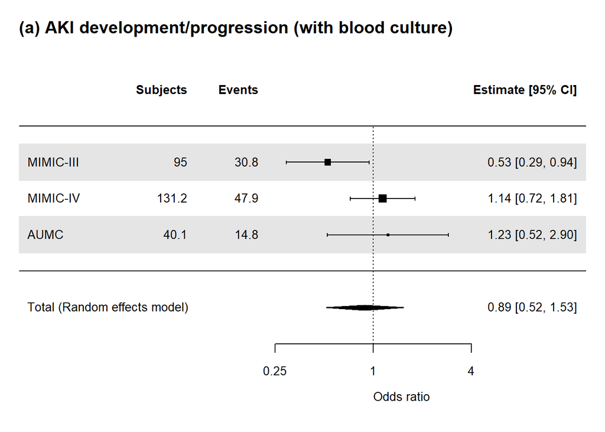

```r
#Forrestplot
FP2("wgt_man_Ovlp_MIMIC3_bc.rds", FORMULA_ovl2_bc)
FP2("wgt_man_Ovlp_MIMIC4_bc.rds", FORMULA_ovl2_bc)
FP2("wgt_man_Ovlp_AUMC_bc.rds", FORMULA_ovl2_bc)

bc_METADF0 <- rbind(
  readRDS("ORRES_wgt_man_Ovlp_MIMIC3_bc.rds") %>% mutate("dataset"="MIMIC-III"),
  readRDS("ORRES_wgt_man_Ovlp_MIMIC4_bc.rds") %>% mutate("dataset"="MIMIC-IV"),
  readRDS("ORRES_wgt_man_Ovlp_AUMC_bc.rds") %>% mutate("dataset"="AUMC"))
bc_METADF_AKID <- bc_METADF0 %>% subset(outcome=="outcome_KDIGO_inc_or_death")
bc_METADF_AKI <- bc_METADF0 %>% subset(outcome=="outcome_KDIGO_inc")
bc_METADF_HD <- bc_METADF0 %>% subset(outcome=="outcome_new_dial")
bc_METADF_D <- bc_METADF0 %>% subset(outcome=="death_in_7d")
bc_METADF_HDD <- bc_METADF0 %>% subset(outcome=="outcome_HDD_in7d")
bc_METARES_AKID <- rma(yi = Estimate, sei = Std.Error, method = "REML", data = bc_METADF_AKID)
bc_METARES_AKI <- rma(yi = Estimate, sei = Std.Error, method = "REML", data = bc_METADF_AKI)
bc_METARES_HD <- rma(yi = Estimate, sei = Std.Error, method = "REML", data = bc_METADF_HD)
bc_METARES_D <- rma(yi = Estimate, sei = Std.Error, method = "REML", data = bc_METADF_D)
bc_METARES_HDD <- rma(yi = Estimate, sei = Std.Error, method = "REML", data = bc_METADF_HDD)

METAF(bc_METARES_AKI, SCALEA1, SCALEB1, SCALEC1, "(a) AKI development/progression (with blood culture)")
```

```r
bc_METARES_AKI
```

```
##
## Random-Effects Model (k = 3; tau^2 estimator: REML)
##
## tau^2 (estimated amount of total heterogeneity): 0.1329 (SE = 0.2337)
## tau (square root of estimated tau^2 value):      0.3646
## I^2 (total heterogeneity / total variability):   58.11%
## H^2 (total variability / sampling variability):  2.39
##
## Test for Heterogeneity:
## Q(df = 2) = 4.8350, p-val = 0.0891
##
## Model Results:
##
## estimate      se     zval    pval    ci.lb   ci.ub
##  -0.1183  0.2778  -0.4258  0.6703  -0.6627  0.4262
##
## ---
## Signif. codes:  0 '***' 0.001 '**' 0.01 '*' 0.05 '.' 0.1 ' ' 1
```

```r
bc_METADF_AKI %>% dplyr::select(dataset, OR, LCI, UCI, 'Pr(>|z|)') %>% remove_rownames()
```

```
##     dataset        OR       LCI       UCI   Pr(>|z|)
## 1 MIMIC-III 0.5266656 0.2942387 0.9426925 0.03087763
## 2  MIMIC-IV 1.1440128 0.7245768 1.8062477 0.56367894
## 3      AUMC 1.2325443 0.5247180 2.8952040 0.63132526
```

__

__

#### 9d. Backgrounds, outcomes, matching quality, and forest plot among those **no previous blood culture**

```r
#1. overlap-PSM using MIMIC3, Older
OVLP(comb_DF2ovl %>% subset(dataset=="MIMIC3"&pre_blood_culture==F), FORMULA_ovl2_bc, "Ovlp_MIMIC3_nonbc", "**Ovlp, MIMIC-III, Non-BC**")
```

| **Characteristic** | **Ovlp, MIMIC-III, Non-BC** **I/C** N=10.2<sup>1</sup> | **Ovlp, MIMIC-III, Non-BC** **NCC** N=10.2<sup>1</sup> | **p-value**<sup>2</sup> |  |
| --- | --- | --- | --- | --- |
| dataset |  |  |  |  |
| MIMIC3 | 10.2 (100.0%) | 10.2 (100.0%) |  |  |
| age_group |  |  | 0.33 |  |
| 18-39 | 0.0 (0.0%) | 0.2 (2.4%) |  |  |
| 40-49 | 2.4 (23.3%) | 0.6 (6.1%) |  |  |
| 50-59 | 0.6 (6.2%) | 1.5 (14.7%) |  |  |
| 60-69 | 1.2 (11.8%) | 2.9 (28.1%) |  |  |
| 70-79 | 3.4 (33.2%) | 3.1 (30.8%) |  |  |
| 80+ | 2.6 (25.6%) | 1.8 (17.9%) |  |  |
| sex |  |  | >0.99 |  |
| Female | 3.9 (38.7%) | 3.9 (38.7%) |  |  |
| Male | 6.2 (61.3%) | 6.2 (61.3%) |  |  |
| bmi | 31.6 (26.4, 34.6) | 29.3 (20.2, 40.8) | 0.65 |  |
| Unknown | 6 | 7 |  |  |
| weight | 72.0 (70.0, 100.0) | 67.8 (57.8, 102.0) | 0.13 |  |
| Unknown | 2 | 2 |  |  |
| ICU type |  |  | >0.99 |  |
| Non-surgery | 4.8 (47.5%) | 4.8 (47.5%) |  |  |
| Surgery | 5.3 (52.5%) | 5.3 (52.5%) |  |  |
| drug_name |  |  |  |  |
| Imipenem/cilastatin | 10.2 (100.0%) | 0.0 (0.0%) |  |  |
| Imipenem/cilastatin/relebactam | 0.0 (0.0%) | 0.0 (0.0%) |  |  |
| Meropenem | 0.0 (0.0%) | 10.2 (100.0%) |  |  |
| Doripenem | 0.0 (0.0%) | 0.0 (0.0%) |  |  |
| Ertapenem | 0.0 (0.0%) | 0.0 (0.0%) |  |  |
| Overdose in first 24h |  |  | 0.51 |  |
| not_over | 9.6 (93.9%) | 9.9 (97.5%) |  |  |
| over | 0.6 (6.1%) | 0.3 (2.5%) |  |  |
| Relative initiation dose (with near eGFR) | 0.2 (0.2, 0.5) | 0.3 (0.3, 0.5) | 0.092 |  |
| sofa | 3.0 (2.0, 6.0) | 4.0 (2.0, 7.0) | 0.82 |  |
| qsofa | 1.0 (0.0, 1.0) | 0.0 (0.0, 1.0) | 0.20 |  |
| Unknown | 0 | 0 |  |  |
| sirs | 2.0 (1.0, 3.0) | 2.0 (1.0, 2.0) | 0.89 |  |
| pre_blood_culture | 0.0 (0.0%) | 0.0 (0.0%) |  |  |
| pre nephrotoxic drugs use | 5.0 (49.1%) | 5.0 (49.1%) | >0.99 |  |
| pre vancomycin use | 4.2 (41.4%) | 3.1 (30.2%) | 0.44 |  |
| pre aminoglycosied use | 0.8 (7.7%) | 1.1 (11.0%) | 0.76 |  |
| pre NSAIDs use | 0.0 (0.0%) | 1.3 (12.3%) | 0.048 |  |
| pre contrast agent use | 0.0 (0.0%) | 0.0 (0.0%) |  |  |
| pre vasopressor use | 1.4 (14.1%) | 1.4 (14.1%) | >0.99 |  |
| pre ventilation | 6.9 (67.9%) | 5.9 (57.8%) | 0.52 |  |
| Baseline sCr | 0.9 (0.6, 1.5) | 1.0 (0.6, 1.6) | 0.97 |  |
| sCr at treatment start | 1.1 (0.7, 1.9) | 1.0 (0.7, 1.7) | 0.94 |  |
| AKI stage at treatment start |  |  | 0.36 |  |
| 0 | 8.1 (79.7%) | 8.6 (84.0%) |  |  |
| 1 | 2.1 (20.3%) | 1.2 (11.7%) |  |  |
| 2 | 0.0 (0.0%) | 0.4 (4.3%) |  |  |
| near_eGFR | 66.7 (34.3, 94.6) | 65.8 (39.2, 94.6) | 0.87 |  |
| observation time | 168.0 (72.3, 168.0) | 168.0 (149.4, 168.0) | 0.48 |  |
| Cencsored with drug change | 0.0 (0.0%) | 0.0 (0.0%) |  |  |
| RRT at treatment start | 0.0 (0.0%) | 0.0 (0.0%) |  |  |
| O, AKI develop/progress | 2.8 (27.2%) | 4.4 (42.7%) | 0.33 |  |
| O, Death | 2.2 (22.1%) | 1.4 (14.2%) | 0.50 |  |
| O, AKI d/p or death | 4.2 (41.2%) | 5.2 (50.8%) | 0.55 |  |
| O, RRT-intervention | 0.8 (8.0%) | 0.5 (5.1%) | 0.73 |  |
| O, Death or RRT-intervention | 2.2 (22.1%) | 2.0 (19.3%) | 0.82 |  |
| total_dose_ICM | 1,567.9 (1,000.0, 3,000.0) | 4,500.0 (3,370.7, 6,500.0) | <0.001 |  |
| total_dose_recabrio | NA (NA, NA) | NA (NA, NA) |  |  |
| Unknown | 10 | 10 |  |  |
| total_dose_erta | NA (NA, NA) | NA (NA, NA) |  |  |
| Unknown | 10 | 10 |  |  |
| total_dose_dori | NA (NA, NA) | NA (NA, NA) |  |  |
| Unknown | 10 | 10 |  |  |
| ini24h_dose_ICM | 500.0 (500.0, 500.0) | 1,000.0 (500.0, 1,000.0) | <0.001 |  |
| ini24h_dose_recabrio | NA (NA, NA) | NA (NA, NA) |  |  |
| Unknown | 10 | 10 |  |  |
| ini24h_dose_erta | NA (NA, NA) | NA (NA, NA) |  |  |
| Unknown | 10 | 10 |  |  |
| ini24h_dose_dori | NA (NA, NA) | NA (NA, NA) |  |  |
| Unknown | 10 | 10 |  |  |
| last_drug_in_obs | 72.0 (48.0, 145.0) | 168.0 (80.9, 168.0) | 0.020 |  |

<sup>1</sup> n (%); Median (Q1, Q3)  
<sup>2</sup> NA; Pearson’s X^2: Rao & Scott adjustment; Design-based KruskalWallis test

```r
#2. overlap-PSM using MIMIC4, Older
OVLP(comb_DF2ovl %>% subset(dataset=="miiv"&pre_blood_culture==F), FORMULA_ovl2_bc, "Ovlp_MIMIC4_nonbc", "**Ovlp, MIMIC-IV, Non-BC**")
```

| **Characteristic** | **Ovlp, MIMIC-IV, Non-BC** **I/C** N=18.9<sup>1</sup> | **Ovlp, MIMIC-IV, Non-BC** **NCC** N=18.9<sup>1</sup> | **p-value**<sup>2</sup> |  |
| --- | --- | --- | --- | --- |
| dataset |  |  |  |  |
| miiv | 18.9 (100.0%) | 18.9 (100.0%) |  |  |
| age_group |  |  | 0.55 |  |
| 18-39 | 2.8 (14.9%) | 1.7 (9.1%) |  |  |
| 40-49 | 1.8 (9.4%) | 2.2 (11.6%) |  |  |
| 50-59 | 4.8 (25.4%) | 4.3 (22.8%) |  |  |
| 60-69 | 1.8 (9.6%) | 4.5 (24.1%) |  |  |
| 70-79 | 2.8 (15.0%) | 3.1 (16.6%) |  |  |
| 80+ | 4.9 (25.8%) | 3.0 (15.7%) |  |  |
| sex |  |  | >0.99 |  |
| Female | 6.6 (34.9%) | 6.6 (34.9%) |  |  |
| Male | 12.3 (65.1%) | 12.3 (65.1%) |  |  |
| bmi | 25.3 (23.0, 28.2) | 27.5 (23.1, 33.4) | 0.35 |  |
| Unknown | 7 | 9 |  |  |
| weight | 83.0 (63.0, 97.6) | 77.3 (64.2, 94.4) | 0.88 |  |
| Unknown | 1 | 1 |  |  |
| ICU type |  |  | >0.99 |  |
| Non-surgery | 16.0 (84.6%) | 16.0 (84.6%) |  |  |
| Surgery | 2.9 (15.4%) | 2.9 (15.4%) |  |  |
| drug_name |  |  |  |  |
| Imipenem/cilastatin | 18.9 (100.0%) | 0.0 (0.0%) |  |  |
| Imipenem/cilastatin/relebactam | 0.0 (0.0%) | 0.0 (0.0%) |  |  |
| Meropenem | 0.0 (0.0%) | 18.8 (99.4%) |  |  |
| Doripenem | 0.0 (0.0%) | 0.0 (0.0%) |  |  |
| Ertapenem | 0.0 (0.0%) | 0.1 (0.6%) |  |  |
| Overdose in first 24h |  |  | 0.46 |  |
| not_over | 18.0 (95.6%) | 18.5 (98.0%) |  |  |
| over | 0.8 (4.4%) | 0.4 (2.0%) |  |  |
| Relative initiation dose (with near eGFR) | 0.3 (0.2, 0.3) | 0.3 (0.3, 0.5) | 0.081 |  |
| sofa | 4.0 (2.0, 6.0) | 5.0 (3.0, 7.0) | 0.28 |  |
| qsofa | 1.0 (0.0, 1.0) | 1.0 (0.0, 1.0) | 0.95 |  |
| Unknown | 0 | 0 |  |  |
| sirs | 1.0 (1.0, 2.0) | 1.0 (0.0, 2.0) | 0.88 |  |
| pre_blood_culture | 0.0 (0.0%) | 0.0 (0.0%) |  |  |
| pre nephrotoxic drugs use | 14.1 (74.9%) | 14.1 (74.9%) | >0.99 |  |
| pre vancomycin use | 13.2 (69.8%) | 13.5 (71.3%) | 0.88 |  |
| pre aminoglycosied use | 1.9 (10.1%) | 0.9 (4.7%) | 0.29 |  |
| pre NSAIDs use | 0.0 (0.0%) | 1.6 (8.5%) | <0.001 |  |
| pre contrast agent use | 0.0 (0.0%) | 0.1 (0.3%) | 0.32 |  |
| pre vasopressor use | 0.0 (0.0%) | 0.0 (0.0%) | <0.001 |  |
| pre ventilation | 0.9 (5.0%) | 0.2 (1.1%) | 0.13 |  |
| Baseline sCr | 1.0 (0.6, 1.5) | 1.1 (0.7, 1.8) | 0.69 |  |
| sCr at treatment start | 1.3 (0.7, 1.7) | 1.3 (0.8, 2.0) | 0.77 |  |
| AKI stage at treatment start |  |  | 0.99 |  |
| 0 | 15.2 (80.7%) | 15.1 (80.2%) |  |  |
| 1 | 2.7 (14.3%) | 2.9 (15.3%) |  |  |
| 2 | 0.9 (5.0%) | 0.9 (4.5%) |  |  |
| near_eGFR | 55.2 (42.0, 114.0) | 59.1 (31.1, 98.2) | 0.80 |  |
| observation time | 168.0 (140.2, 168.0) | 168.0 (126.1, 168.0) | 0.86 |  |
| Cencsored with drug change | 1.0 (5.2%) | 0.0 (0.0%) | 0.30 |  |
| RRT at treatment start | 0.0 (0.0%) | 0.0 (0.0%) |  |  |
| O, AKI develop/progress | 5.6 (29.5%) | 4.6 (24.2%) | 0.59 |  |
| O, Death | 0.9 (5.0%) | 0.9 (4.8%) | 0.97 |  |
| O, AKI d/p or death | 5.6 (29.5%) | 5.1 (27.3%) | 0.83 |  |
| O, RRT-intervention | 0.0 (0.0%) | 1.0 (5.1%) | <0.001 |  |
| O, Death or RRT-intervention | 0.9 (5.0%) | 1.8 (9.6%) | 0.49 |  |
| total_dose_ICM | 2,979.2 (520.8, 3,375.0) | 2,125.0 (875.0, 3,583.3) | 0.65 |  |
| Unknown | 0 | 0 |  |  |
| total_dose_recabrio | NA (NA, NA) | NA (NA, NA) |  |  |
| Unknown | 19 | 19 |  |  |
| total_dose_erta | NA (NA, NA) | NA (NA, NA) |  |  |
| Unknown | 19 | 19 |  |  |
| total_dose_dori | NA (NA, NA) | NA (NA, NA) |  |  |
| Unknown | 19 | 19 |  |  |
| ini24h_dose_ICM | 500.0 (500.0, 500.0) | 1,000.0 (500.0, 1,000.0) | <0.001 |  |
| Unknown | 0 | 0 |  |  |
| ini24h_dose_recabrio | NA (NA, NA) | NA (NA, NA) |  |  |
| Unknown | 19 | 19 |  |  |
| ini24h_dose_erta | NA (NA, NA) | NA (NA, NA) |  |  |
| Unknown | 19 | 19 |  |  |
| ini24h_dose_dori | NA (NA, NA) | NA (NA, NA) |  |  |
| Unknown | 19 | 19 |  |  |
| last_drug_in_obs | 144.0 (25.0, 168.0) | 82.0 (27.0, 156.0) | 0.53 |  |

<sup>1</sup> n (%); Median (Q1, Q3)  
<sup>2</sup> NA; Pearson’s X^2: Rao & Scott adjustment; Design-based KruskalWallis test

```r
#3. overlap-PSM using AUMC, Older
OVLP(comb_DF2ovl %>% subset(dataset=="AUMC"&pre_blood_culture==F), FORMULA_ovl2_bc, "Ovlp_AUMC_nonbc", "**Ovlp, AUMC, Non-BC**")
```

| **Characteristic** | **Ovlp, AUMC, Non-BC** **I/C** N=122.7<sup>1</sup> | **Ovlp, AUMC, Non-BC** **NCC** N=122.7<sup>1</sup> | **p-value**<sup>2</sup> |  |
| --- | --- | --- | --- | --- |
| dataset |  |  |  |  |
| AUMC | 122.7 (100.0%) | 122.7 (100.0%) |  |  |
| age_group |  |  | 0.43 |  |
| 18-39 | 14.3 (11.7%) | 18.7 (15.2%) |  |  |
| 40-49 | 13.1 (10.7%) | 12.3 (10.1%) |  |  |
| 50-59 | 27.1 (22.1%) | 20.1 (16.4%) |  |  |
| 60-69 | 38.2 (31.2%) | 35.2 (28.7%) |  |  |
| 70-79 | 24.7 (20.1%) | 30.7 (25.0%) |  |  |
| 80+ | 5.2 (4.3%) | 5.6 (4.5%) |  |  |
| sex |  |  | >0.99 |  |
| Female | 43.3 (35.3%) | 43.3 (35.3%) |  |  |
| Male | 79.3 (64.7%) | 79.3 (64.7%) |  |  |
| bmi | 24.5 (21.9, 27.8) | 24.5 (21.3, 27.8) | 0.72 |  |
| Unknown | 6 | 3 |  |  |
| weight | 75.0 (65.0, 85.0) | 75.0 (65.0, 95.0) | 0.35 |  |
| Unknown | 5 | 3 |  |  |
| ICU type |  |  | >0.99 |  |
| Non-surgery | 73.5 (59.9%) | 73.5 (59.9%) |  |  |
| Surgery | 49.1 (40.1%) | 49.1 (40.1%) |  |  |
| drug_name |  |  |  |  |
| Imipenem/cilastatin | 122.7 (100.0%) | 0.0 (0.0%) |  |  |
| Imipenem/cilastatin/relebactam | 0.0 (0.0%) | 0.0 (0.0%) |  |  |
| Meropenem | 0.0 (0.0%) | 122.7 (100.0%) |  |  |
| Doripenem | 0.0 (0.0%) | 0.0 (0.0%) |  |  |
| Ertapenem | 0.0 (0.0%) | 0.0 (0.0%) |  |  |
| Overdose in first 24h |  |  | 0.90 |  |
| not_over | 121.6 (99.1%) | 121.7 (99.3%) |  |  |
| over | 1.1 (0.9%) | 0.9 (0.7%) |  |  |
| Relative initiation dose (with near eGFR) | 0.3 (0.2, 0.3) | 0.5 (0.3, 0.7) | <0.001 |  |
| sofa | 7.0 (5.0, 9.0) | 7.0 (4.0, 9.0) | 0.51 |  |
| Unknown | 20 | 25 |  |  |
| qsofa | 1.0 (0.0, 1.0) | 1.0 (0.0, 1.0) | 0.92 |  |
| Unknown | 0 | 0 |  |  |
| sirs | 2.0 (1.0, 3.0) | 2.0 (1.0, 3.0) | 0.88 |  |
| pre_blood_culture | 0.0 (0.0%) | 0.0 (0.0%) |  |  |
| pre nephrotoxic drugs use | 69.6 (56.7%) | 69.6 (56.7%) | >0.99 |  |
| pre vancomycin use | 60.0 (48.9%) | 62.1 (50.6%) | 0.70 |  |
| pre aminoglycosied use | 16.7 (13.7%) | 7.7 (6.3%) | 0.011 |  |
| pre NSAIDs use | 2.3 (1.8%) | 10.3 (8.4%) | <0.001 |  |
| pre contrast agent use | 2.5 (2.1%) | 0.0 (0.0%) | 0.005 |  |
| pre vasopressor use | 77.5 (63.2%) | 77.5 (63.2%) | >0.99 |  |
| pre ventilation | 82.4 (67.2%) | 70.7 (57.7%) | 0.028 |  |
| Baseline sCr | 0.8 (0.6, 1.2) | 0.7 (0.6, 1.2) | 0.28 |  |
| sCr at treatment start | 1.0 (0.7, 1.4) | 0.9 (0.6, 1.5) | 0.37 |  |
| AKI stage at treatment start |  |  | 0.92 |  |
| 0 | 88.9 (72.5%) | 89.7 (73.1%) |  |  |
| 1 | 26.7 (21.8%) | 25.2 (20.6%) |  |  |
| 2 | 7.0 (5.7%) | 7.7 (6.3%) |  |  |
| near_eGFR | 77.1 (47.9, 103.0) | 83.5 (46.1, 108.0) | 0.38 |  |
| observation time | 168.0 (55.5, 168.0) | 151.7 (56.4, 168.0) | 0.64 |  |
| Cencsored with drug change | 4.2 (3.4%) | 1.4 (1.2%) | 0.14 |  |
| RRT at treatment start | 0.0 (0.0%) | 0.0 (0.0%) |  |  |
| O, AKI develop/progress | 35.2 (28.7%) | 34.2 (27.9%) | 0.85 |  |
| O, Death | 17.0 (13.9%) | 14.9 (12.2%) | 0.59 |  |
| O, AKI d/p or death | 41.5 (33.8%) | 40.7 (33.2%) | 0.89 |  |
| O, RRT-intervention | 11.9 (9.7%) | 12.8 (10.4%) | 0.79 |  |
| O, Death or RRT-intervention | 24.4 (19.9%) | 21.3 (17.4%) | 0.48 |  |
| total_dose_ICM | 7,500.0 (3,000.0, 15,500.0) | 11,000.0 (5,000.0, 24,000.0) | <0.001 |  |
| total_dose_recabrio | NA (NA, NA) | NA (NA, NA) |  |  |
| Unknown | 123 | 123 |  |  |
| total_dose_erta | NA (NA, NA) | NA (NA, NA) |  |  |
| Unknown | 123 | 123 |  |  |
| total_dose_dori | NA (NA, NA) | NA (NA, NA) |  |  |
| Unknown | 123 | 123 |  |  |
| ini24h_dose_ICM | 500.0 (500.0, 500.0) | 1,000.0 (1,000.0, 2,000.0) | <0.001 |  |
| ini24h_dose_recabrio | NA (NA, NA) | NA (NA, NA) |  |  |
| Unknown | 123 | 123 |  |  |
| ini24h_dose_erta | NA (NA, NA) | NA (NA, NA) |  |  |
| Unknown | 123 | 123 |  |  |
| ini24h_dose_dori | NA (NA, NA) | NA (NA, NA) |  |  |
| Unknown | 123 | 123 |  |  |
| last_drug_in_obs | 96.0 (35.7, 168.0) | 84.0 (32.0, 168.0) | 0.33 |  |

<sup>1</sup> n (%); Median (Q1, Q3)  
<sup>2</sup> NA; Pearson’s X^2: Rao & Scott adjustment; Design-based KruskalWallis test

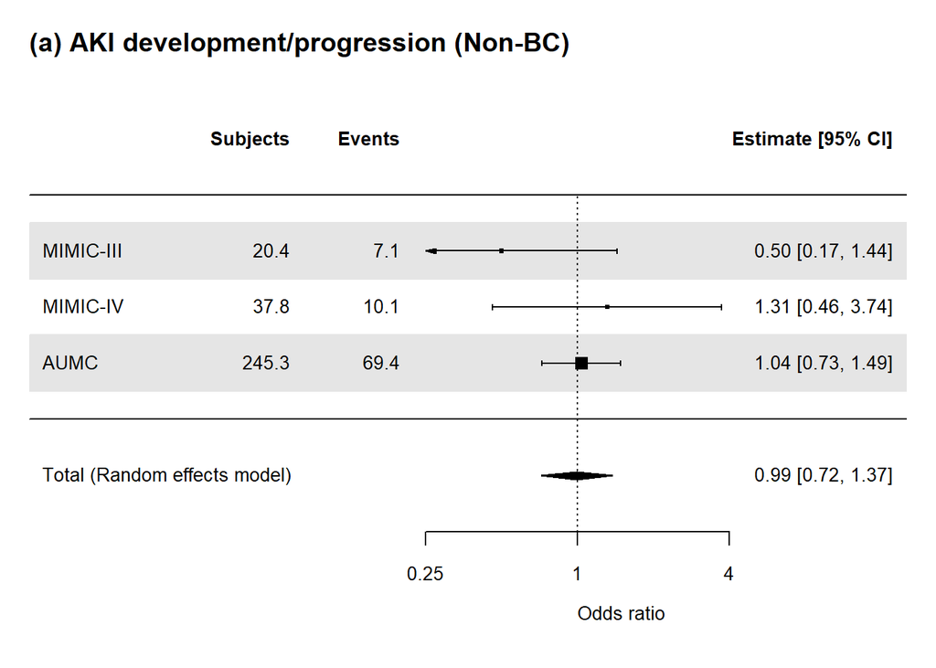

```r
FP2("wgt_man_Ovlp_MIMIC4_nonbc.rds", FORMULA_ovl2_bc)
FP2("wgt_man_Ovlp_MIMIC3_nonbc.rds", FORMULA_ovl2_bc)
FP2("wgt_man_Ovlp_AUMC_nonbc.rds", FORMULA_ovl2_bc)

nonbc_METADF0 <- rbind(
  readRDS("ORRES_wgt_man_Ovlp_MIMIC3_nonbc.rds") %>% mutate("dataset"="MIMIC-III"),
  readRDS("ORRES_wgt_man_Ovlp_MIMIC4_nonbc.rds") %>% mutate("dataset"="MIMIC-IV"),
  readRDS("ORRES_wgt_man_Ovlp_AUMC_nonbc.rds") %>% mutate("dataset"="AUMC"))
nonbc_METADF_AKID <- nonbc_METADF0 %>% subset(outcome=="outcome_KDIGO_inc_or_death")
nonbc_METADF_AKI <- nonbc_METADF0 %>% subset(outcome=="outcome_KDIGO_inc")
nonbc_METADF_HD <- nonbc_METADF0 %>% subset(outcome=="outcome_new_dial")
nonbc_METADF_D <- nonbc_METADF0 %>% subset(outcome=="death_in_7d")
nonbc_METADF_HDD <- nonbc_METADF0 %>% subset(outcome=="outcome_HDD_in7d")

nonbc_METARES_AKID <- rma(yi = Estimate, sei = Std.Error, method = "REML", data = nonbc_METADF_AKID)
nonbc_METARES_AKI <-rma(yi = Estimate, sei = Std.Error, method = "REML", data = nonbc_METADF_AKI)
nonbc_METARES_HD <- rma(yi = Estimate, sei = Std.Error, method = "REML", data = nonbc_METADF_HD)
nonbc_METARES_D <- rma(yi = Estimate, sei = Std.Error, method = "REML", data = nonbc_METADF_D)
nonbc_METARES_HDD <- rma(yi = Estimate, sei = Std.Error, method = "REML", data = nonbc_METADF_HDD)

METAF(nonbc_METARES_AKI, SCALEA1, SCALEB1, SCALEC1, "(a) AKI development/progression (Non-BC)")
```

```r
nonbc_METARES_AKI
```

```
##
## Random-Effects Model (k = 3; tau^2 estimator: REML)
##
## tau^2 (estimated amount of total heterogeneity): 0.0000 (SE = 0.1550)
## tau (square root of estimated tau^2 value):      0.0010
## I^2 (total heterogeneity / total variability):   0.00%
## H^2 (total variability / sampling variability):  1.00
##
## Test for Heterogeneity:
## Q(df = 2) = 1.9502, p-val = 0.3771
##
## Model Results:
##
## estimate      se     zval    pval    ci.lb   ci.ub
##  -0.0080  0.1647  -0.0488  0.9611  -0.3309  0.3148
##
## ---
## Signif. codes:  0 '***' 0.001 '**' 0.01 '*' 0.05 '.' 0.1 ' ' 1
```

```r
nonbc_METADF_AKI %>% dplyr::select(dataset, OR, LCI, UCI, 'Pr(>|z|)') %>% remove_rownames()
```

```
##     dataset        OR       LCI      UCI  Pr(>|z|)
## 1 MIMIC-III 0.4992799 0.1730251 1.440718 0.1989192
## 2  MIMIC-IV 1.3128127 0.4612568 3.736481 0.6100506
## 3      AUMC 1.0382820 0.7255995 1.485709 0.8371922
```

__

#### 10c. Backgrounds, outcomes, matching quality, and forrest plot among those **SIRS<2** at treatment start.

```r
FORMULA_ovl2_sirs <- drug01 ~ age_cat + sex + dep_type2 + pre_blood_culture + nt_drug + vasopressor + base_crea + near_crea +  base_KDIGO

#1. overlap-PSM using MIMIC3, "SIRS<2"
OVLP(comb_DF2ovl %>% subset(dataset=="MIMIC3"&sirs<2), FORMULA_ovl2_sirs, "Ovlp_MIMIC3_Lsirs", "**Ovlp, MIMIC-III, SIRS<2**")
```

| **Characteristic** | **Ovlp, MIMIC-III, SIRS<2** **I/C** N=20.4<sup>1</sup> | **Ovlp, MIMIC-III, SIRS<2** **NCC** N=20.4<sup>1</sup> | **p-value**<sup>2</sup> |  |
| --- | --- | --- | --- | --- |
| dataset |  |  |  |  |
| MIMIC3 | 20.4 (100.0%) | 20.4 (100.0%) |  |  |
| age_group |  |  | 0.68 |  |
| 18-39 | 0.8 (4.2%) | 1.7 (8.5%) |  |  |
| 40-49 | 1.7 (8.4%) | 0.9 (4.4%) |  |  |
| 50-59 | 3.2 (15.8%) | 3.2 (15.6%) |  |  |
| 60-69 | 4.8 (23.4%) | 2.8 (13.9%) |  |  |
| 70-79 | 4.4 (21.6%) | 6.8 (33.4%) |  |  |
| 80+ | 5.4 (26.6%) | 4.9 (24.2%) |  |  |
| sex |  |  | >0.99 |  |
| Female | 9.6 (46.9%) | 9.6 (46.9%) |  |  |
| Male | 10.8 (53.1%) | 10.8 (53.1%) |  |  |
| bmi | 26.0 (23.6, 29.8) | 28.3 (23.1, 31.2) | 0.59 |  |
| Unknown | 9 | 11 |  |  |
| weight | 79.0 (68.1, 91.5) | 71.5 (60.0, 88.5) | 0.32 |  |
| Unknown | 3 | 4 |  |  |
| ICU type |  |  | >0.99 |  |
| Non-surgery | 13.2 (64.6%) | 13.2 (64.6%) |  |  |
| Surgery | 7.2 (35.4%) | 7.2 (35.4%) |  |  |
| drug_name |  |  |  |  |
| Imipenem/cilastatin | 20.4 (100.0%) | 0.0 (0.0%) |  |  |
| Imipenem/cilastatin/relebactam | 0.0 (0.0%) | 0.0 (0.0%) |  |  |
| Meropenem | 0.0 (0.0%) | 20.4 (100.0%) |  |  |
| Doripenem | 0.0 (0.0%) | 0.0 (0.0%) |  |  |
| Ertapenem | 0.0 (0.0%) | 0.0 (0.0%) |  |  |
| Overdose in first 24h |  |  | 0.32 |  |
| not_over | 20.4 (100.0%) | 20.1 (98.4%) |  |  |
| over | 0.0 (0.0%) | 0.3 (1.6%) |  |  |
| Relative initiation dose (with near eGFR) | 0.3 (0.3, 0.5) | 0.3 (0.3, 0.5) | 0.55 |  |
| sofa | 4.0 (3.0, 7.0) | 4.0 (2.0, 7.0) | >0.99 |  |
| qsofa | 0.0 (0.0, 1.0) | 0.0 (0.0, 1.0) | 0.90 |  |
| Unknown | 0 | 2 |  |  |
| sirs | 1.0 (0.0, 1.0) | 1.0 (0.0, 1.0) | 0.69 |  |
| pre_blood_culture | 15.1 (74.3%) | 15.1 (74.3%) | >0.99 |  |
| pre nephrotoxic drugs use | 14.1 (69.2%) | 14.1 (69.2%) | >0.99 |  |
| pre vancomycin use | 11.1 (54.2%) | 12.7 (62.1%) | 0.48 |  |
| pre aminoglycosied use | 2.5 (12.5%) | 1.1 (5.4%) | 0.19 |  |
| pre NSAIDs use | 4.5 (22.1%) | 3.4 (16.7%) | 0.53 |  |
| pre contrast agent use | 0.0 (0.0%) | 0.0 (0.0%) |  |  |
| pre vasopressor use | 6.7 (32.8%) | 6.7 (32.8%) | >0.99 |  |
| pre ventilation | 12.9 (63.4%) | 13.5 (66.2%) | 0.80 |  |
| Baseline sCr | 1.1 (0.8, 1.6) | 1.0 (0.6, 1.7) | 0.61 |  |
| sCr at treatment start | 1.2 (0.9, 1.8) | 1.2 (0.7, 1.8) | 0.59 |  |
| AKI stage at treatment start |  |  | 0.75 |  |
| 0 | 17.1 (83.8%) | 17.2 (84.2%) |  |  |
| 1 | 3.3 (16.2%) | 3.1 (15.4%) |  |  |
| 2 | 0.0 (0.0%) | 0.1 (0.4%) |  |  |
| near_eGFR | 58.8 (31.4, 83.5) | 61.0 (34.5, 90.1) | 0.68 |  |
| observation time | 168.0 (166.5, 168.0) | 168.0 (149.4, 168.0) | 0.86 |  |
| Cencsored with drug change | 0.8 (3.9%) | 0.1 (0.5%) | 0.075 |  |
| RRT at treatment start | 0.0 (0.0%) | 0.0 (0.0%) |  |  |
| O, AKI develop/progress | 5.2 (25.4%) | 6.7 (32.9%) | 0.47 |  |
| O, Death | 1.5 (7.6%) | 2.5 (12.2%) | 0.51 |  |
| O, AKI d/p or death | 6.1 (29.8%) | 8.0 (39.3%) | 0.38 |  |
| O, RRT-intervention | 0.0 (0.0%) | 0.7 (3.3%) | 0.068 |  |
| O, Death or RRT-intervention | 1.5 (7.6%) | 3.2 (15.6%) | 0.31 |  |
| total_dose_ICM | 2,500.0 (1,500.0, 3,500.0) | 4,000.0 (2,500.0, 7,000.0) | <0.001 |  |
| total_dose_recabrio | NA (NA, NA) | NA (NA, NA) |  |  |
| Unknown | 20 | 20 |  |  |
| total_dose_erta | NA (NA, NA) | NA (NA, NA) |  |  |
| Unknown | 20 | 20 |  |  |
| total_dose_dori | NA (NA, NA) | NA (NA, NA) |  |  |
| Unknown | 20 | 20 |  |  |
| ini24h_dose_ICM | 500.0 (500.0, 1,000.0) | 1,000.0 (500.0, 1,000.0) | <0.001 |  |
| ini24h_dose_recabrio | NA (NA, NA) | NA (NA, NA) |  |  |
| Unknown | 20 | 20 |  |  |
| ini24h_dose_erta | NA (NA, NA) | NA (NA, NA) |  |  |
| Unknown | 20 | 20 |  |  |
| ini24h_dose_dori | NA (NA, NA) | NA (NA, NA) |  |  |
| Unknown | 20 | 20 |  |  |
| last_drug_in_obs | 96.0 (48.0, 168.0) | 168.0 (75.2, 168.0) | 0.057 |  |

<sup>1</sup> n (%); Median (Q1, Q3)  
<sup>2</sup> NA; Pearson’s X^2: Rao & Scott adjustment; Design-based KruskalWallis test

```r
#2. overlap-PSM using MIMIC4, "SIRS<2"
OVLP(comb_DF2ovl %>% subset(dataset=="miiv"&sirs<2), FORMULA_ovl2_sirs, "Ovlp_MIMIC4_Lsirs", "**Ovlp, MIMIC-IV, SIRS<2**")
```

| **Characteristic** | **Ovlp, MIMIC-IV, SIRS<2** **I/C** N=30.7<sup>1</sup> | **Ovlp, MIMIC-IV, SIRS<2** **NCC** N=30.7<sup>1</sup> | **p-value**<sup>2</sup> |  |
| --- | --- | --- | --- | --- |
| dataset |  |  |  |  |
| miiv | 30.7 (100.0%) | 30.7 (100.0%) |  |  |
| age_group |  |  | 0.91 |  |
| 18-39 | 1.0 (3.1%) | 1.7 (5.5%) |  |  |
| 40-49 | 3.8 (12.4%) | 2.1 (6.9%) |  |  |
| 50-59 | 4.8 (15.7%) | 5.6 (18.2%) |  |  |
| 60-69 | 7.8 (25.4%) | 7.8 (25.4%) |  |  |
| 70-79 | 6.7 (22.0%) | 7.1 (23.1%) |  |  |
| 80+ | 6.6 (21.4%) | 6.4 (20.8%) |  |  |
| sex |  |  | >0.99 |  |
| Female | 13.5 (44.1%) | 13.5 (44.1%) |  |  |
| Male | 17.2 (55.9%) | 17.2 (55.9%) |  |  |
| bmi | 27.2 (25.3, 36.3) | 28.1 (23.8, 33.8) | 0.39 |  |
| Unknown | 12 | 13 |  |  |
| weight | 81.0 (73.8, 96.0) | 78.9 (64.7, 95.5) | 0.29 |  |
| Unknown | 3 | 2 |  |  |
| ICU type |  |  | >0.99 |  |
| Non-surgery | 22.3 (72.5%) | 22.3 (72.5%) |  |  |
| Surgery | 8.4 (27.5%) | 8.4 (27.5%) |  |  |
| drug_name |  |  |  |  |
| Imipenem/cilastatin | 30.7 (100.0%) | 0.0 (0.0%) |  |  |
| Imipenem/cilastatin/relebactam | 0.0 (0.0%) | 0.0 (0.0%) |  |  |
| Meropenem | 0.0 (0.0%) | 30.5 (99.3%) |  |  |
| Doripenem | 0.0 (0.0%) | 0.0 (0.0%) |  |  |
| Ertapenem | 0.0 (0.0%) | 0.2 (0.7%) |  |  |
| Overdose in first 24h |  |  | 0.39 |  |
| not_over | 29.8 (96.9%) | 30.3 (98.7%) |  |  |
| over | 1.0 (3.1%) | 0.4 (1.3%) |  |  |
| Relative initiation dose (with near eGFR) | 0.3 (0.3, 0.3) | 0.3 (0.3, 0.5) | 0.079 |  |
| sofa | 4.0 (3.0, 8.0) | 5.0 (3.0, 7.0) | 0.72 |  |
| qsofa | 0.0 (0.0, 1.0) | 0.0 (0.0, 1.0) | 0.97 |  |
| Unknown | 0 | 0 |  |  |
| sirs | 1.0 (0.0, 1.0) | 1.0 (0.0, 1.0) | 0.77 |  |
| pre_blood_culture | 18.3 (59.7%) | 18.3 (59.7%) | >0.99 |  |
| pre nephrotoxic drugs use | 24.1 (78.3%) | 24.1 (78.3%) | >0.99 |  |
| pre vancomycin use | 20.2 (65.7%) | 22.9 (74.6%) | 0.26 |  |
| pre aminoglycosied use | 4.9 (15.8%) | 1.8 (5.7%) | 0.021 |  |
| pre NSAIDs use | 1.0 (3.2%) | 3.2 (10.6%) | 0.18 |  |
| pre contrast agent use | 1.0 (3.2%) | 0.2 (0.5%) | 0.065 |  |
| pre vasopressor use | 1.0 (3.2%) | 1.0 (3.2%) | >0.99 |  |
| pre ventilation | 2.0 (6.4%) | 1.3 (4.1%) | 0.53 |  |
| Baseline sCr | 1.1 (0.6, 1.5) | 1.0 (0.7, 1.6) | 0.92 |  |
| sCr at treatment start | 1.3 (0.7, 1.7) | 1.2 (0.8, 1.9) | 0.94 |  |
| AKI stage at treatment start |  |  | >0.99 |  |
| 0 | 22.3 (72.6%) | 22.4 (72.8%) |  |  |
| 1 | 6.6 (21.6%) | 6.5 (21.2%) |  |  |
| 2 | 1.8 (5.8%) | 1.8 (6.0%) |  |  |
| near_eGFR | 61.0 (42.0, 99.5) | 59.1 (33.8, 93.5) | 0.85 |  |
| observation time | 168.0 (128.4, 168.0) | 168.0 (152.0, 168.0) | 0.62 |  |
| Cencsored with drug change | 2.0 (6.4%) | 0.0 (0.0%) | 0.14 |  |
| RRT at treatment start | 0.0 (0.0%) | 0.0 (0.0%) |  |  |
| O, AKI develop/progress | 8.7 (28.3%) | 7.4 (24.1%) | 0.59 |  |
| O, Death | 2.9 (9.5%) | 2.3 (7.6%) | 0.68 |  |
| O, AKI d/p or death | 9.7 (31.5%) | 8.8 (28.7%) | 0.73 |  |
| O, RRT-intervention | 0.0 (0.0%) | 1.2 (3.8%) | <0.001 |  |
| O, Death or RRT-intervention | 2.9 (9.5%) | 3.2 (10.5%) | 0.86 |  |
| total_dose_ICM | 1,791.7 (437.5, 3,312.5) | 2,395.8 (1,166.7, 3,791.7) | 0.041 |  |
| Unknown | 0 | 0 |  |  |
| total_dose_recabrio | NA (NA, NA) | NA (NA, NA) |  |  |
| Unknown | 31 | 31 |  |  |
| total_dose_erta | NA (NA, NA) | NA (NA, NA) |  |  |
| Unknown | 31 | 31 |  |  |
| total_dose_dori | NA (NA, NA) | NA (NA, NA) |  |  |
| Unknown | 31 | 31 |  |  |
| ini24h_dose_ICM | 500.0 (500.0, 500.0) | 1,000.0 (500.0, 1,000.0) | <0.001 |  |
| Unknown | 0 | 0 |  |  |
| ini24h_dose_recabrio | NA (NA, NA) | NA (NA, NA) |  |  |
| Unknown | 31 | 31 |  |  |
| ini24h_dose_erta | NA (NA, NA) | NA (NA, NA) |  |  |
| Unknown | 31 | 31 |  |  |
| ini24h_dose_dori | NA (NA, NA) | NA (NA, NA) |  |  |
| Unknown | 31 | 31 |  |  |
| last_drug_in_obs | 71.0 (25.0, 163.0) | 94.0 (37.1, 168.0) | 0.36 |  |

<sup>1</sup> n (%); Median (Q1, Q3)  
<sup>2</sup> NA; Pearson’s X^2: Rao & Scott adjustment; Design-based KruskalWallis test

```r
#3. overlap-PSM using AUMC, "SIRS<2"
OVLP(comb_DF2ovl %>% subset(dataset=="AUMC"&sirs<2), FORMULA_ovl2_sirs, "Ovlp_AUMC_Lsirs", paste0("**Ovlp, AUMC, SIRS<2**"))
```

| **Characteristic** | **Ovlp, AUMC, SIRS<2** **I/C** N=36.0<sup>1</sup> | **Ovlp, AUMC, SIRS<2** **NCC** N=36.0<sup>1</sup> | **p-value**<sup>2</sup> |  |
| --- | --- | --- | --- | --- |
| dataset |  |  |  |  |
| AUMC | 36.0 (100.0%) | 36.0 (100.0%) |  |  |
| age_group |  |  | 0.77 |  |
| 18-39 | 4.4 (12.2%) | 4.6 (12.8%) |  |  |
| 40-49 | 3.4 (9.5%) | 3.7 (10.3%) |  |  |
| 50-59 | 8.1 (22.5%) | 6.7 (18.5%) |  |  |
| 60-69 | 12.0 (33.3%) | 11.7 (32.6%) |  |  |
| 70-79 | 6.0 (16.7%) | 8.6 (23.9%) |  |  |
| 80+ | 2.1 (5.8%) | 0.7 (1.9%) |  |  |
| sex |  |  | >0.99 |  |
| Female | 10.4 (28.8%) | 10.4 (28.8%) |  |  |
| Male | 25.6 (71.2%) | 25.6 (71.2%) |  |  |
| bmi | 24.5 (21.9, 27.8) | 24.8 (21.9, 27.8) | 0.19 |  |
| Unknown | 3 | 0 |  |  |
| weight | 75.0 (65.0, 85.0) | 85.0 (75.0, 95.0) | 0.051 |  |
| Unknown | 2 | 0 |  |  |
| ICU type |  |  | >0.99 |  |
| Non-surgery | 23.9 (66.3%) | 23.9 (66.3%) |  |  |
| Surgery | 12.1 (33.7%) | 12.1 (33.7%) |  |  |
| drug_name |  |  |  |  |
| Imipenem/cilastatin | 36.0 (100.0%) | 0.0 (0.0%) |  |  |
| Imipenem/cilastatin/relebactam | 0.0 (0.0%) | 0.0 (0.0%) |  |  |
| Meropenem | 0.0 (0.0%) | 36.0 (100.0%) |  |  |
| Doripenem | 0.0 (0.0%) | 0.0 (0.0%) |  |  |
| Ertapenem | 0.0 (0.0%) | 0.0 (0.0%) |  |  |
| Overdose in first 24h |  |  | <0.001 |  |
| not_over | 36.0 (100.0%) | 35.1 (97.7%) |  |  |
| over | 0.0 (0.0%) | 0.8 (2.3%) |  |  |
| Relative initiation dose (with near eGFR) | 0.3 (0.2, 0.3) | 0.5 (0.3, 0.7) | <0.001 |  |
| sofa | 6.0 (4.0, 8.0) | 6.0 (4.0, 8.0) | 0.89 |  |
| Unknown | 5 | 5 |  |  |
| qsofa | 0.0 (0.0, 1.0) | 0.0 (0.0, 1.0) | 0.55 |  |
| sirs | 1.0 (1.0, 1.0) | 1.0 (1.0, 1.0) | 0.25 |  |
| pre_blood_culture | 3.9 (10.8%) | 3.9 (10.8%) | >0.99 |  |
| pre nephrotoxic drugs use | 21.4 (59.4%) | 21.4 (59.4%) | >0.99 |  |
| pre vancomycin use | 17.8 (49.4%) | 16.9 (47.1%) | 0.78 |  |
| pre aminoglycosied use | 6.9 (19.1%) | 2.8 (7.8%) | 0.054 |  |
| pre NSAIDs use | 1.0 (2.9%) | 3.9 (10.9%) | 0.060 |  |
| pre contrast agent use | 0.8 (2.4%) | 0.0 (0.0%) | 0.093 |  |
| pre vasopressor use | 21.7 (60.2%) | 21.7 (60.2%) | >0.99 |  |
| pre ventilation | 26.1 (72.6%) | 22.8 (63.3%) | 0.23 |  |
| Baseline sCr | 0.8 (0.6, 1.2) | 0.7 (0.6, 1.1) | 0.27 |  |
| sCr at treatment start | 0.9 (0.7, 1.3) | 0.8 (0.7, 1.4) | 0.42 |  |
| AKI stage at treatment start |  |  | 0.65 |  |
| 0 | 31.5 (87.4%) | 31.3 (86.9%) |  |  |
| 1 | 4.3 (12.0%) | 4.7 (13.1%) |  |  |
| 2 | 0.2 (0.6%) | 0.0 (0.0%) |  |  |
| near_eGFR | 85.9 (59.1, 102.8) | 92.3 (68.7, 111.0) | 0.31 |  |
| observation time | 167.7 (55.4, 168.0) | 168.0 (68.9, 168.0) | 0.61 |  |
| Cencsored with drug change | 1.4 (3.8%) | 0.0 (0.0%) | 0.052 |  |
| RRT at treatment start | 0.0 (0.0%) | 0.0 (0.0%) |  |  |
| O, AKI develop/progress | 6.3 (17.6%) | 5.5 (15.4%) | 0.72 |  |
| O, Death | 2.0 (5.6%) | 1.6 (4.3%) | 0.75 |  |
| O, AKI d/p or death | 8.0 (22.3%) | 6.3 (17.4%) | 0.48 |  |
| O, RRT-intervention | 1.7 (4.8%) | 1.6 (4.4%) | 0.92 |  |
| O, Death or RRT-intervention | 3.7 (10.4%) | 2.3 (6.5%) | 0.44 |  |
| total_dose_ICM | 8,400.0 (3,500.0, 16,500.0) | 12,000.0 (6,000.0, 26,000.0) | 0.033 |  |
| total_dose_recabrio | NA (NA, NA) | NA (NA, NA) |  |  |
| Unknown | 36 | 36 |  |  |
| total_dose_erta | NA (NA, NA) | NA (NA, NA) |  |  |
| Unknown | 36 | 36 |  |  |
| total_dose_dori | NA (NA, NA) | NA (NA, NA) |  |  |
| Unknown | 36 | 36 |  |  |
| ini24h_dose_ICM | 500.0 (500.0, 500.0) | 1,000.0 (1,000.0, 2,000.0) | <0.001 |  |
| ini24h_dose_recabrio | NA (NA, NA) | NA (NA, NA) |  |  |
| Unknown | 36 | 36 |  |  |
| ini24h_dose_erta | NA (NA, NA) | NA (NA, NA) |  |  |
| Unknown | 36 | 36 |  |  |
| ini24h_dose_dori | NA (NA, NA) | NA (NA, NA) |  |  |
| Unknown | 36 | 36 |  |  |
| last_drug_in_obs | 110.0 (42.0, 168.0) | 75.8 (32.0, 168.0) | 0.19 |  |

<sup>1</sup> n (%); Median (Q1, Q3)  
<sup>2</sup> NA; Pearson’s X^2: Rao & Scott adjustment; Design-based KruskalWallis test

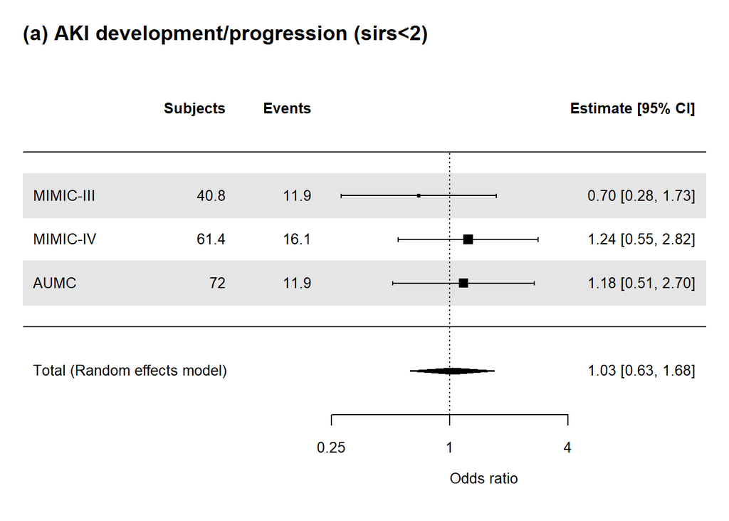

```r
FP2("wgt_man_Ovlp_MIMIC3_Lsirs.rds", FORMULA_ovl2_sirs)
FP2("wgt_man_Ovlp_MIMIC4_Lsirs.rds", FORMULA_ovl2_sirs)
FP2("wgt_man_Ovlp_AUMC_Lsirs.rds", FORMULA_ovl2_sirs)

Lsirs_METADF0 <- rbind(
  readRDS("ORRES_wgt_man_Ovlp_MIMIC3_Lsirs.rds") %>% mutate("dataset"="MIMIC-III"),
  readRDS("ORRES_wgt_man_Ovlp_MIMIC4_Lsirs.rds") %>% mutate("dataset"="MIMIC-IV"),
  readRDS("ORRES_wgt_man_Ovlp_AUMC_Lsirs.rds") %>% mutate("dataset"="AUMC"))
Lsirs_METADF_AKID <- Lsirs_METADF0 %>% subset(outcome=="outcome_KDIGO_inc_or_death")
Lsirs_METADF_AKI <- Lsirs_METADF0 %>% subset(outcome=="outcome_KDIGO_inc")
Lsirs_METADF_HD <- Lsirs_METADF0 %>% subset(outcome=="outcome_new_dial")
Lsirs_METADF_D <- Lsirs_METADF0 %>% subset(outcome=="death_in_7d")
Lsirs_METADF_HDD <- Lsirs_METADF0 %>% subset(outcome=="outcome_HDD_in7d")
Lsirs_METARES_AKID <- rma(yi = Estimate, sei = Std.Error, method = "REML", data = Lsirs_METADF_AKID)
Lsirs_METARES_AKI <- rma(yi = Estimate, sei = Std.Error, method = "REML", data = Lsirs_METADF_AKI)
Lsirs_METARES_HD <- rma(yi = Estimate, sei = Std.Error, method = "REML", data = Lsirs_METADF_HD)
Lsirs_METARES_D <- rma(yi = Estimate, sei = Std.Error, method = "REML", data = Lsirs_METADF_D)
Lsirs_METARES_HDD <- rma(yi = Estimate, sei = Std.Error, method = "REML", data = Lsirs_METADF_HDD)

METAF(Lsirs_METARES_AKI, SCALEA1, SCALEB1, SCALEC1, "(a) AKI development/progression (sirs<2)")
```

```r
Lsirs_METARES_AKI
```

```
##
## Random-Effects Model (k = 3; tau^2 estimator: REML)
##
## tau^2 (estimated amount of total heterogeneity): 0 (SE = 0.1889)
## tau (square root of estimated tau^2 value):      0
## I^2 (total heterogeneity / total variability):   0.00%
## H^2 (total variability / sampling variability):  1.00
##
## Test for Heterogeneity:
## Q(df = 2) = 1.0090, p-val = 0.6038
##
## Model Results:
##
## estimate      se    zval    pval    ci.lb   ci.ub
##   0.0297  0.2507  0.1184  0.9058  -0.4616  0.5210
##
## ---
## Signif. codes:  0 '***' 0.001 '**' 0.01 '*' 0.05 '.' 0.1 ' ' 1
```

```r
Lsirs_METADF_AKI %>% dplyr::select(dataset, OR, LCI, UCI, 'Pr(>|z|)') %>% remove_rownames()
```

```
##     dataset        OR       LCI      UCI  Pr(>|z|)
## 1 MIMIC-III 0.6964954 0.2801810 1.731402 0.4362836
## 2  MIMIC-IV 1.2421340 0.5465215 2.823122 0.6047165
## 3      AUMC 1.1775219 0.5136701 2.699316 0.6994416
```

__

__

#### 10d. Backgrounds, outcomes, matching quality, and forest plot among those **SIRS>1.99**

```r
#1. overlap-PSM using MIMIC3, SIRS>1.99
OVLP(comb_DF2ovl %>% subset(dataset=="MIMIC3"&sirs>1.99), FORMULA_ovl2_sirs, "Ovlp_MIMIC3_Hsirs", "**Ovlp, MIMIC-III, SIRS>1.99**")
```

| **Characteristic** | **Ovlp, MIMIC-III, SIRS>1.99** **I/C** N=38.1<sup>1</sup> | **Ovlp, MIMIC-III, SIRS>1.99** **NCC** N=38.1<sup>1</sup> | **p-value**<sup>2</sup> |  |
| --- | --- | --- | --- | --- |
| dataset |  |  |  |  |
| MIMIC3 | 38.1 (100.0%) | 38.1 (100.0%) |  |  |
| age_group |  |  | >0.99 |  |
| 18-39 | 2.4 (6.2%) | 2.5 (6.5%) |  |  |
| 40-49 | 4.5 (11.8%) | 3.9 (10.3%) |  |  |
| 50-59 | 7.2 (18.9%) | 7.0 (18.3%) |  |  |
| 60-69 | 8.3 (21.8%) | 9.6 (25.3%) |  |  |
| 70-79 | 9.2 (24.0%) | 9.0 (23.7%) |  |  |
| 80+ | 6.5 (17.1%) | 6.1 (15.9%) |  |  |
| sex |  |  | >0.99 |  |
| Female | 19.2 (50.4%) | 19.2 (50.4%) |  |  |
| Male | 18.9 (49.6%) | 18.9 (49.6%) |  |  |
| bmi | 27.7 (25.4, 30.6) | 28.0 (23.8, 35.9) | 0.96 |  |
| Unknown | 17 | 19 |  |  |
| weight | 75.8 (65.0, 90.0) | 80.0 (64.4, 99.5) | 0.35 |  |
| Unknown | 4 | 5 |  |  |
| ICU type |  |  | >0.99 |  |
| Non-surgery | 22.3 (58.5%) | 22.3 (58.5%) |  |  |
| Surgery | 15.8 (41.5%) | 15.8 (41.5%) |  |  |
| drug_name |  |  |  |  |
| Imipenem/cilastatin | 38.1 (100.0%) | 0.0 (0.0%) |  |  |
| Imipenem/cilastatin/relebactam | 0.0 (0.0%) | 0.0 (0.0%) |  |  |
| Meropenem | 0.0 (0.0%) | 38.1 (100.0%) |  |  |
| Doripenem | 0.0 (0.0%) | 0.0 (0.0%) |  |  |
| Ertapenem | 0.0 (0.0%) | 0.0 (0.0%) |  |  |
| Overdose in first 24h |  |  | 0.87 |  |
| not_over | 37.3 (97.8%) | 37.1 (97.3%) |  |  |
| over | 0.8 (2.2%) | 1.0 (2.7%) |  |  |
| Relative initiation dose (with near eGFR) | 0.3 (0.2, 0.5) | 0.3 (0.3, 0.5) | 0.033 |  |
| sofa | 5.0 (3.0, 9.0) | 4.0 (2.0, 8.0) | 0.23 |  |
| qsofa | 1.0 (0.0, 1.0) | 1.0 (0.0, 1.0) | 0.82 |  |
| sirs | 3.0 (2.0, 3.0) | 2.0 (2.0, 3.0) | 0.67 |  |
| pre_blood_culture | 31.6 (82.9%) | 31.6 (82.9%) | >0.99 |  |
| pre nephrotoxic drugs use | 21.3 (55.9%) | 21.3 (55.9%) | >0.99 |  |
| pre vancomycin use | 19.6 (51.5%) | 19.0 (49.8%) | 0.83 |  |
| pre aminoglycosied use | 4.1 (10.8%) | 3.4 (8.8%) | 0.67 |  |
| pre NSAIDs use | 0.9 (2.3%) | 3.5 (9.3%) | 0.12 |  |
| pre contrast agent use | 0.0 (0.0%) | 0.0 (0.0%) |  |  |
| pre vasopressor use | 17.8 (46.7%) | 17.8 (46.7%) | >0.99 |  |
| pre ventilation | 26.8 (70.4%) | 25.9 (68.0%) | 0.75 |  |
| Baseline sCr | 0.8 (0.6, 1.2) | 0.9 (0.6, 1.3) | 0.71 |  |
| sCr at treatment start | 1.1 (0.8, 1.5) | 1.0 (0.7, 1.6) | 0.89 |  |
| AKI stage at treatment start |  |  | 0.96 |  |
| 0 | 26.7 (70.0%) | 26.9 (70.6%) |  |  |
| 1 | 10.0 (26.2%) | 9.5 (24.9%) |  |  |
| 2 | 1.4 (3.8%) | 1.7 (4.5%) |  |  |
| near_eGFR | 70.0 (38.4, 97.7) | 65.8 (40.9, 95.9) | 0.93 |  |
| observation time | 168.0 (168.0, 168.0) | 168.0 (168.0, 168.0) | 0.26 |  |
| Cencsored with drug change | 1.5 (4.0%) | 0.0 (0.0%) | 0.16 |  |
| RRT at treatment start | 0.0 (0.0%) | 0.0 (0.0%) |  |  |
| O, AKI develop/progress | 9.7 (25.4%) | 16.2 (42.5%) | 0.035 |  |
| O, Death | 6.0 (15.8%) | 6.2 (16.2%) | 0.94 |  |
| O, AKI d/p or death | 12.7 (33.3%) | 18.1 (47.5%) | 0.081 |  |
| O, RRT-intervention | 1.5 (3.9%) | 2.0 (5.3%) | 0.68 |  |
| O, Death or RRT-intervention | 6.9 (18.1%) | 7.8 (20.4%) | 0.73 |  |
| total_dose_ICM | 3,000.0 (1,104.6, 4,000.0) | 4,500.0 (3,000.0, 7,000.0) | <0.001 |  |
| total_dose_recabrio | NA (NA, NA) | NA (NA, NA) |  |  |
| Unknown | 38 | 38 |  |  |
| total_dose_erta | NA (NA, NA) | NA (NA, NA) |  |  |
| Unknown | 38 | 38 |  |  |
| total_dose_dori | NA (NA, NA) | NA (NA, NA) |  |  |
| Unknown | 38 | 38 |  |  |
| ini24h_dose_ICM | 500.0 (500.0, 750.0) | 1,000.0 (500.0, 1,000.0) | <0.001 |  |
| ini24h_dose_recabrio | NA (NA, NA) | NA (NA, NA) |  |  |
| Unknown | 38 | 38 |  |  |
| ini24h_dose_erta | NA (NA, NA) | NA (NA, NA) |  |  |
| Unknown | 38 | 38 |  |  |
| ini24h_dose_dori | NA (NA, NA) | NA (NA, NA) |  |  |
| Unknown | 38 | 38 |  |  |
| last_drug_in_obs | 122.3 (48.0, 168.0) | 168.0 (76.4, 168.0) | 0.083 |  |

<sup>1</sup> n (%); Median (Q1, Q3)  
<sup>2</sup> NA; Pearson’s X^2: Rao & Scott adjustment; Design-based KruskalWallis test

```r
#2. overlap-PSM using MIMIC4, SIRS>1.99
OVLP(comb_DF2ovl %>% subset(dataset=="miiv"&sirs>1.99), FORMULA_ovl2_sirs, "Ovlp_MIMIC4_Hsirs", "**Ovlp, MIMIC-IV, SIRS>1.99**")
```

| **Characteristic** | **Ovlp, MIMIC-IV, SIRS>1.99** **I/C** N=53.8<sup>1</sup> | **Ovlp, MIMIC-IV, SIRS>1.99** **NCC** N=53.8<sup>1</sup> | **p-value**<sup>2</sup> |  |
| --- | --- | --- | --- | --- |
| dataset |  |  |  |  |
| miiv | 53.8 (100.0%) | 53.8 (100.0%) |  |  |
| age_group |  |  | 0.50 |  |
| 18-39 | 6.8 (12.6%) | 5.0 (9.3%) |  |  |
| 40-49 | 5.8 (10.8%) | 5.6 (10.5%) |  |  |
| 50-59 | 5.7 (10.7%) | 11.1 (20.5%) |  |  |
| 60-69 | 16.3 (30.3%) | 14.3 (26.6%) |  |  |
| 70-79 | 11.5 (21.4%) | 10.0 (18.6%) |  |  |
| 80+ | 7.6 (14.2%) | 7.8 (14.5%) |  |  |
| sex |  |  | >0.99 |  |
| Female | 23.1 (42.9%) | 23.1 (42.9%) |  |  |
| Male | 30.8 (57.1%) | 30.8 (57.1%) |  |  |
| bmi | 28.2 (24.7, 31.6) | 27.2 (23.3, 32.9) | 0.90 |  |
| Unknown | 31 | 18 |  |  |
| weight | 82.7 (68.0, 100.0) | 77.5 (65.0, 94.4) | 0.30 |  |
| Unknown | 3 | 5 |  |  |
| ICU type |  |  | >0.99 |  |
| Non-surgery | 47.9 (89.0%) | 47.9 (89.0%) |  |  |
| Surgery | 5.9 (11.0%) | 5.9 (11.0%) |  |  |
| drug_name |  |  | <0.001 |  |
| Imipenem/cilastatin | 52.8 (98.2%) | 0.0 (0.0%) |  |  |
| Imipenem/cilastatin/relebactam | 1.0 (1.8%) | 0.0 (0.0%) |  |  |
| Meropenem | 0.0 (0.0%) | 53.5 (99.3%) |  |  |
| Doripenem | 0.0 (0.0%) | 0.2 (0.3%) |  |  |
| Ertapenem | 0.0 (0.0%) | 0.2 (0.3%) |  |  |
| Overdose in first 24h |  |  | <0.001 |  |
| not_over | 53.8 (100.0%) | 53.2 (98.8%) |  |  |
| over | 0.0 (0.0%) | 0.6 (1.2%) |  |  |
| Relative initiation dose (with near eGFR) | 0.3 (0.2, 0.3) | 0.3 (0.3, 0.5) | <0.001 |  |
| sofa | 5.0 (3.0, 8.0) | 6.0 (3.0, 9.0) | 0.22 |  |
| qsofa | 1.0 (1.0, 1.0) | 1.0 (1.0, 2.0) | 0.39 |  |
| sirs | 2.0 (2.0, 3.0) | 2.0 (2.0, 3.0) | 0.54 |  |
| pre_blood_culture | 47.0 (87.3%) | 47.0 (87.3%) | >0.99 |  |
| pre nephrotoxic drugs use | 42.4 (78.8%) | 42.4 (78.8%) | >0.99 |  |
| pre vancomycin use | 40.5 (75.2%) | 41.0 (76.1%) | 0.88 |  |
| pre aminoglycosied use | 3.9 (7.2%) | 5.1 (9.5%) | 0.57 |  |
| pre NSAIDs use | 4.8 (9.0%) | 3.7 (6.9%) | 0.56 |  |
| pre contrast agent use | 0.0 (0.0%) | 0.7 (1.3%) | <0.001 |  |
| pre vasopressor use | 6.7 (12.4%) | 6.7 (12.4%) | >0.99 |  |
| pre ventilation | 9.6 (17.8%) | 5.9 (10.9%) | 0.11 |  |
| Baseline sCr | 0.9 (0.6, 1.5) | 0.9 (0.6, 1.4) | 0.93 |  |
| sCr at treatment start | 1.0 (0.6, 2.0) | 1.1 (0.7, 1.7) | 0.91 |  |
| AKI stage at treatment start |  |  | 0.92 |  |
| 0 | 42.2 (78.4%) | 41.7 (77.5%) |  |  |
| 1 | 8.7 (16.2%) | 9.6 (17.9%) |  |  |
| 2 | 2.9 (5.4%) | 2.5 (4.6%) |  |  |
| near_eGFR | 73.8 (34.1, 100.9) | 70.0 (38.7, 100.9) | 0.91 |  |
| observation time | 168.0 (109.5, 168.0) | 168.0 (154.9, 168.0) | 0.41 |  |
| Cencsored with drug change | 2.0 (3.6%) | 0.0 (0.0%) | 0.15 |  |
| RRT at treatment start | 0.0 (0.0%) | 0.0 (0.0%) |  |  |
| O, AKI develop/progress | 22.0 (40.9%) | 19.8 (36.8%) | 0.53 |  |
| O, Death | 10.5 (19.6%) | 10.3 (19.0%) | 0.92 |  |
| O, AKI d/p or death | 23.0 (42.7%) | 23.4 (43.6%) | 0.89 |  |
| O, RRT-intervention | 2.9 (5.4%) | 4.4 (8.1%) | 0.47 |  |
| O, Death or RRT-intervention | 11.5 (21.4%) | 13.0 (24.1%) | 0.64 |  |
| total_dose_ICM | 1,614.9 (583.3, 3,500.0) | 2,666.7 (1,291.7, 3,958.3) | 0.003 |  |
| Unknown | 1 | 0 |  |  |
| total_dose_recabrio | NA (NA, NA) | NA (NA, NA) |  |  |
| Unknown | 53 | 54 |  |  |
| total_dose_erta | NA (NA, NA) | NA (NA, NA) |  |  |
| Unknown | 54 | 54 |  |  |
| total_dose_dori | NA (NA, NA) | NA (NA, NA) |  |  |
| Unknown | 54 | 54 |  |  |
| ini24h_dose_ICM | 500.0 (500.0, 500.0) | 1,000.0 (500.0, 1,000.0) | <0.001 |  |
| Unknown | 1 | 0 |  |  |
| ini24h_dose_recabrio | NA (NA, NA) | NA (NA, NA) |  |  |
| Unknown | 53 | 54 |  |  |
| ini24h_dose_erta | NA (NA, NA) | NA (NA, NA) |  |  |
| Unknown | 54 | 54 |  |  |
| ini24h_dose_dori | NA (NA, NA) | NA (NA, NA) |  |  |
| Unknown | 54 | 54 |  |  |
| last_drug_in_obs | 46.0 (28.0, 168.0) | 94.0 (36.0, 168.0) | 0.17 |  |

<sup>1</sup> n (%); Median (Q1, Q3)  
<sup>2</sup> NA; Pearson’s X^2: Rao & Scott adjustment; Design-based KruskalWallis test

```r
#3. overlap-PSM using AUMC, SIRS>1.99
OVLP(comb_DF2ovl %>% subset(dataset=="AUMC"&sirs>1.99), FORMULA_ovl2_sirs, "Ovlp_AUMC_Hsirs", "**Ovlp, AUMC, SIRS>1.99**")
```

| **Characteristic** | **Ovlp, AUMC, SIRS>1.99** **I/C** N=104.6<sup>1</sup> | **Ovlp, AUMC, SIRS>1.99** **NCC** N=104.6<sup>1</sup> | **p-value**<sup>2</sup> |  |
| --- | --- | --- | --- | --- |
| dataset |  |  |  |  |
| AUMC | 104.6 (100.0%) | 104.6 (100.0%) |  |  |
| age_group |  |  | 0.34 |  |
| 18-39 | 11.1 (10.6%) | 15.5 (14.8%) |  |  |
| 40-49 | 11.6 (11.1%) | 11.1 (10.6%) |  |  |
| 50-59 | 23.9 (22.9%) | 18.1 (17.3%) |  |  |
| 60-69 | 32.1 (30.7%) | 27.7 (26.5%) |  |  |
| 70-79 | 22.8 (21.8%) | 26.9 (25.7%) |  |  |
| 80+ | 3.1 (3.0%) | 5.3 (5.1%) |  |  |
| sex |  |  | >0.99 |  |
| Female | 41.0 (39.2%) | 41.0 (39.2%) |  |  |
| Male | 63.7 (60.8%) | 63.7 (60.8%) |  |  |
| bmi | 24.5 (21.9, 27.8) | 24.5 (21.3, 27.8) | 0.87 |  |
| Unknown | 5 | 3 |  |  |
| weight | 75.0 (65.0, 85.0) | 75.0 (65.0, 95.0) | 0.79 |  |
| Unknown | 4 | 3 |  |  |
| ICU type |  |  | >0.99 |  |
| Non-surgery | 60.1 (57.5%) | 60.1 (57.5%) |  |  |
| Surgery | 44.5 (42.5%) | 44.5 (42.5%) |  |  |
| drug_name |  |  |  |  |
| Imipenem/cilastatin | 104.6 (100.0%) | 0.0 (0.0%) |  |  |
| Imipenem/cilastatin/relebactam | 0.0 (0.0%) | 0.0 (0.0%) |  |  |
| Meropenem | 0.0 (0.0%) | 104.6 (100.0%) |  |  |
| Doripenem | 0.0 (0.0%) | 0.0 (0.0%) |  |  |
| Ertapenem | 0.0 (0.0%) | 0.0 (0.0%) |  |  |
| Overdose in first 24h |  |  | 0.22 |  |
| not_over | 103.8 (99.2%) | 104.6 (100.0%) |  |  |
| over | 0.8 (0.8%) | 0.0 (0.0%) |  |  |
| Relative initiation dose (with near eGFR) | 0.3 (0.2, 0.3) | 0.3 (0.3, 0.7) | <0.001 |  |
| sofa | 8.0 (5.0, 10.0) | 8.0 (4.0, 10.0) | 0.64 |  |
| Unknown | 15 | 19 |  |  |
| qsofa | 1.0 (0.0, 1.0) | 1.0 (0.0, 1.0) | 0.88 |  |
| Unknown | 0 | 0 |  |  |
| sirs | 2.0 (2.0, 3.0) | 3.0 (2.0, 3.0) | 0.33 |  |
| pre_blood_culture | 17.3 (16.5%) | 17.3 (16.5%) | >0.99 |  |
| pre nephrotoxic drugs use | 59.2 (56.6%) | 59.2 (56.6%) | >0.99 |  |
| pre vancomycin use | 49.4 (47.2%) | 54.1 (51.7%) | 0.36 |  |
| pre aminoglycosied use | 15.4 (14.7%) | 8.3 (7.9%) | 0.038 |  |
| pre NSAIDs use | 1.9 (1.8%) | 6.6 (6.3%) | 0.009 |  |
| pre contrast agent use | 1.4 (1.3%) | 0.0 (0.0%) | 0.032 |  |
| pre vasopressor use | 67.5 (64.5%) | 67.5 (64.5%) | >0.99 |  |
| pre ventilation | 68.6 (65.5%) | 60.8 (58.2%) | 0.12 |  |
| Baseline sCr | 0.8 (0.6, 1.2) | 0.7 (0.6, 1.2) | 0.43 |  |
| sCr at treatment start | 1.0 (0.7, 1.5) | 1.0 (0.6, 1.6) | 0.44 |  |
| AKI stage at treatment start |  |  | >0.99 |  |
| 0 | 72.8 (69.6%) | 73.1 (69.9%) |  |  |
| 1 | 24.0 (23.0%) | 23.5 (22.5%) |  |  |
| 2 | 7.8 (7.4%) | 8.0 (7.6%) |  |  |
| near_eGFR | 72.9 (46.6, 101.1) | 81.1 (44.4, 105.1) | 0.50 |  |
| observation time | 168.0 (60.0, 168.0) | 146.0 (61.0, 168.0) | 0.59 |  |
| Cencsored with drug change | 3.2 (3.0%) | 1.4 (1.4%) | 0.30 |  |
| RRT at treatment start | 0.0 (0.0%) | 0.0 (0.0%) |  |  |
| O, AKI develop/progress | 35.1 (33.6%) | 34.3 (32.8%) | 0.86 |  |
| O, Death | 17.1 (16.3%) | 16.9 (16.2%) | 0.97 |  |
| O, AKI d/p or death | 40.4 (38.6%) | 42.6 (40.7%) | 0.66 |  |
| O, RRT-intervention | 12.1 (11.6%) | 13.8 (13.2%) | 0.61 |  |
| O, Death or RRT-intervention | 24.1 (23.1%) | 24.8 (23.7%) | 0.88 |  |
| total_dose_ICM | 7,500.0 (3,000.0, 15,000.0) | 11,003.5 (5,000.0, 24,000.0) | <0.001 |  |
| total_dose_recabrio | NA (NA, NA) | NA (NA, NA) |  |  |
| Unknown | 105 | 105 |  |  |
| total_dose_erta | NA (NA, NA) | NA (NA, NA) |  |  |
| Unknown | 105 | 105 |  |  |
| total_dose_dori | NA (NA, NA) | NA (NA, NA) |  |  |
| Unknown | 105 | 105 |  |  |
| ini24h_dose_ICM | 500.0 (500.0, 500.0) | 1,000.0 (1,000.0, 1,000.0) | <0.001 |  |
| ini24h_dose_recabrio | NA (NA, NA) | NA (NA, NA) |  |  |
| Unknown | 105 | 105 |  |  |
| ini24h_dose_erta | NA (NA, NA) | NA (NA, NA) |  |  |
| Unknown | 105 | 105 |  |  |
| ini24h_dose_dori | NA (NA, NA) | NA (NA, NA) |  |  |
| Unknown | 105 | 105 |  |  |
| last_drug_in_obs | 90.0 (35.1, 168.0) | 84.5 (35.3, 168.0) | 0.70 |  |

<sup>1</sup> n (%); Median (Q1, Q3)  
<sup>2</sup> NA; Pearson’s X^2: Rao & Scott adjustment; Design-based KruskalWallis test

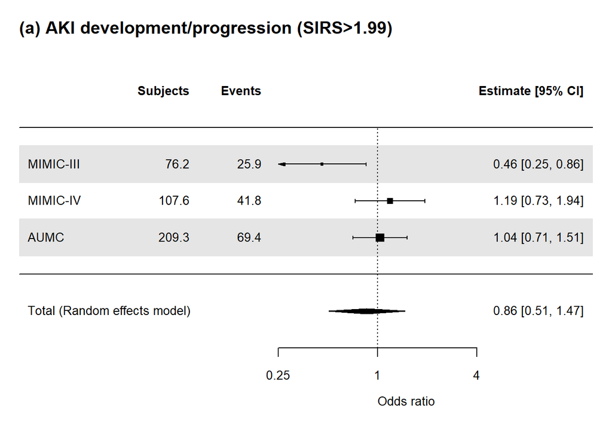

```r
FP2("wgt_man_Ovlp_MIMIC4_Hsirs.rds", FORMULA_ovl2_sirs)
FP2("wgt_man_Ovlp_MIMIC3_Hsirs.rds", FORMULA_ovl2_sirs)
FP2("wgt_man_Ovlp_AUMC_Hsirs.rds", FORMULA_ovl2_sirs)

Hsirs_METADF0 <- rbind(
  readRDS("ORRES_wgt_man_Ovlp_MIMIC3_Hsirs.rds") %>% mutate("dataset"="MIMIC-III"),
  readRDS("ORRES_wgt_man_Ovlp_MIMIC4_Hsirs.rds") %>% mutate("dataset"="MIMIC-IV"),
  readRDS("ORRES_wgt_man_Ovlp_AUMC_Hsirs.rds") %>% mutate("dataset"="AUMC"))
Hsirs_METADF_AKID <- Hsirs_METADF0 %>% subset(outcome=="outcome_KDIGO_inc_or_death")
Hsirs_METADF_AKI <- Hsirs_METADF0 %>% subset(outcome=="outcome_KDIGO_inc")
Hsirs_METADF_HD <- Hsirs_METADF0 %>% subset(outcome=="outcome_new_dial")
Hsirs_METADF_D <- Hsirs_METADF0 %>% subset(outcome=="death_in_7d")
Hsirs_METADF_HDD <- Hsirs_METADF0 %>% subset(outcome=="outcome_HDD_in7d")

Hsirs_METARES_AKID <- rma(yi = Estimate, sei = Std.Error, method = "REML", data = Hsirs_METADF_AKID)
Hsirs_METARES_AKI <-rma(yi = Estimate, sei = Std.Error, method = "REML", data = Hsirs_METADF_AKI)
Hsirs_METARES_HD <- rma(yi = Estimate, sei = Std.Error, method = "REML", data = Hsirs_METADF_HD)
Hsirs_METARES_D <- rma(yi = Estimate, sei = Std.Error, method = "REML", data = Hsirs_METADF_D)
Hsirs_METARES_HDD <- rma(yi = Estimate, sei = Std.Error, method = "REML", data = Hsirs_METADF_HDD)

METAF(Hsirs_METARES_AKI, SCALEA1, SCALEB1, SCALEC1, "(a) AKI development/progression (SIRS>1.99)")
```

```r
Hsirs_METARES_AKI
```

```
##
## Random-Effects Model (k = 3; tau^2 estimator: REML)
##
## tau^2 (estimated amount of total heterogeneity): 0.1581 (SE = 0.2223)
## tau (square root of estimated tau^2 value):      0.3976
## I^2 (total heterogeneity / total variability):   72.03%
## H^2 (total variability / sampling variability):  3.58
##
## Test for Heterogeneity:
## Q(df = 2) = 6.2524, p-val = 0.0439
##
## Model Results:
##
## estimate      se     zval    pval    ci.lb   ci.ub
##  -0.1494  0.2718  -0.5496  0.5826  -0.6821  0.3833
##
## ---
## Signif. codes:  0 '***' 0.001 '**' 0.01 '*' 0.05 '.' 0.1 ' ' 1
```

```r
Hsirs_METADF_AKI %>% dplyr::select(dataset, OR, LCI, UCI, 'Pr(>|z|)') %>% remove_rownames()
```

```
##     dataset        OR       LCI       UCI   Pr(>|z|)
## 1 MIMIC-III 0.4604086 0.2476942 0.8557977 0.01419467
## 2  MIMIC-IV 1.1917961 0.7321866 1.9399124 0.48025431
## 3      AUMC 1.0367107 0.7097810 1.5142262 0.85203920
```

__

#### 11c. Backgrounds, outcomes, matching quality, and forrest plot among those **with vasopressor** at treatment start.

```r
FORMULA_ovl2_vaso <- drug01 ~  age_cat + sex + dep_type2 + sirs + pre_blood_culture + nt_drug + base_crea + near_crea +  base_KDIGO

#1. overlap-PSM using MIMIC3, vasopressor
OVLP(comb_DF2ovl %>% subset(dataset=="MIMIC3"&vasopressor==T), FORMULA_ovl2_vaso, "Ovlp_MIMIC3_vaso", "**Ovlp, MIMIC-III, with vaso**")
```

| **Characteristic** | **Ovlp, MIMIC-III, with vaso** **I/C** N=23.6<sup>1</sup> | **Ovlp, MIMIC-III, with vaso** **NCC** N=23.6<sup>1</sup> | **p-value**<sup>2</sup> |  |
| --- | --- | --- | --- | --- |
| dataset |  |  |  |  |
| MIMIC3 | 23.6 (100.0%) | 23.6 (100.0%) |  |  |
| age_group |  |  | 0.91 |  |
| 18-39 | 0.8 (3.5%) | 1.5 (6.5%) |  |  |
| 40-49 | 2.4 (10.1%) | 1.6 (6.8%) |  |  |
| 50-59 | 4.1 (17.6%) | 3.3 (14.1%) |  |  |
| 60-69 | 4.5 (19.0%) | 4.4 (18.7%) |  |  |
| 70-79 | 7.0 (29.9%) | 8.9 (37.7%) |  |  |
| 80+ | 4.7 (19.9%) | 3.8 (16.2%) |  |  |
| sex |  |  | >0.99 |  |
| Female | 11.7 (49.7%) | 11.7 (49.7%) |  |  |
| Male | 11.9 (50.3%) | 11.9 (50.3%) |  |  |
| bmi | 26.3 (25.4, 29.7) | 27.6 (23.4, 33.1) | 0.87 |  |
| Unknown | 6 | 9 |  |  |
| weight | 78.0 (66.3, 90.0) | 77.9 (62.5, 90.4) | 0.96 |  |
| Unknown | 1 | 1 |  |  |
| ICU type |  |  | >0.99 |  |
| Non-surgery | 13.8 (58.6%) | 13.8 (58.6%) |  |  |
| Surgery | 9.7 (41.4%) | 9.7 (41.4%) |  |  |
| drug_name |  |  |  |  |
| Imipenem/cilastatin | 23.6 (100.0%) | 0.0 (0.0%) |  |  |
| Imipenem/cilastatin/relebactam | 0.0 (0.0%) | 0.0 (0.0%) |  |  |
| Meropenem | 0.0 (0.0%) | 23.6 (100.0%) |  |  |
| Doripenem | 0.0 (0.0%) | 0.0 (0.0%) |  |  |
| Ertapenem | 0.0 (0.0%) | 0.0 (0.0%) |  |  |
| Overdose in first 24h |  |  | 0.54 |  |
| not_over | 22.8 (96.5%) | 23.2 (98.3%) |  |  |
| over | 0.8 (3.5%) | 0.4 (1.7%) |  |  |
| Relative initiation dose (with near eGFR) | 0.3 (0.3, 0.5) | 0.3 (0.3, 0.5) | 0.23 |  |
| sofa | 9.0 (6.0, 10.0) | 7.0 (4.0, 10.0) | 0.22 |  |
| qsofa | 1.0 (1.0, 1.0) | 1.0 (0.0, 1.0) | 0.33 |  |
| sirs | 2.0 (1.0, 3.0) | 2.0 (1.0, 3.0) | 0.86 |  |
| pre_blood_culture | 22.0 (93.1%) | 22.0 (93.1%) | >0.99 |  |
| pre nephrotoxic drugs use | 16.5 (70.1%) | 16.5 (70.1%) | >0.99 |  |
| pre vancomycin use | 15.7 (66.4%) | 15.2 (64.4%) | 0.84 |  |
| pre aminoglycosied use | 3.8 (16.2%) | 1.7 (7.3%) | 0.12 |  |
| pre NSAIDs use | 3.1 (13.1%) | 3.5 (14.8%) | 0.81 |  |
| pre contrast agent use | 0.0 (0.0%) | 0.0 (0.0%) |  |  |
| pre vasopressor use | 23.6 (100.0%) | 23.6 (100.0%) |  |  |
| pre ventilation | 17.2 (72.9%) | 18.6 (79.1%) | 0.47 |  |
| Baseline sCr | 0.9 (0.6, 1.7) | 1.0 (0.7, 1.8) | 0.64 |  |
| sCr at treatment start | 1.1 (0.8, 2.1) | 1.2 (0.8, 2.0) | 0.86 |  |
| AKI stage at treatment start |  |  | 0.68 |  |
| 0 | 18.5 (78.7%) | 18.0 (76.5%) |  |  |
| 1 | 4.1 (17.4%) | 5.1 (21.8%) |  |  |
| 2 | 0.9 (3.9%) | 0.4 (1.7%) |  |  |
| near_eGFR | 58.8 (26.4, 90.1) | 56.9 (30.5, 90.1) | 0.88 |  |
| observation time | 168.0 (168.0, 168.0) | 168.0 (168.0, 168.0) | 0.64 |  |
| Cencsored with drug change | 0.8 (3.5%) | 0.1 (0.6%) | 0.17 |  |
| RRT at treatment start | 0.0 (0.0%) | 0.0 (0.0%) |  |  |
| O, AKI develop/progress | 7.5 (32.0%) | 12.8 (54.3%) | 0.032 |  |
| O, Death | 4.0 (17.1%) | 5.2 (22.0%) | 0.57 |  |
| O, AKI d/p or death | 9.2 (39.2%) | 14.0 (59.2%) | 0.054 |  |
| O, RRT-intervention | 1.6 (6.9%) | 1.9 (8.1%) | 0.83 |  |
| O, Death or RRT-intervention | 4.9 (20.6%) | 6.4 (27.1%) | 0.48 |  |
| total_dose_ICM | 3,500.0 (2,000.0, 3,750.0) | 4,000.0 (2,031.6, 7,000.0) | 0.008 |  |
| total_dose_recabrio | NA (NA, NA) | NA (NA, NA) |  |  |
| Unknown | 24 | 24 |  |  |
| total_dose_erta | NA (NA, NA) | NA (NA, NA) |  |  |
| Unknown | 24 | 24 |  |  |
| total_dose_dori | NA (NA, NA) | NA (NA, NA) |  |  |
| Unknown | 24 | 24 |  |  |
| ini24h_dose_ICM | 500.0 (500.0, 500.0) | 1,000.0 (500.0, 1,000.0) | <0.001 |  |
| ini24h_dose_recabrio | NA (NA, NA) | NA (NA, NA) |  |  |
| Unknown | 24 | 24 |  |  |
| ini24h_dose_erta | NA (NA, NA) | NA (NA, NA) |  |  |
| Unknown | 24 | 24 |  |  |
| ini24h_dose_dori | NA (NA, NA) | NA (NA, NA) |  |  |
| Unknown | 24 | 24 |  |  |
| last_drug_in_obs | 168.0 (72.0, 168.0) | 168.0 (72.0, 168.0) | 0.96 |  |

<sup>1</sup> n (%); Median (Q1, Q3)  
<sup>2</sup> NA; Pearson’s X^2: Rao & Scott adjustment; Design-based KruskalWallis test

```r
#2. overlap-PSM using MIMIC4, vasopressor
OVLP(comb_DF2ovl %>% subset(dataset=="miiv"&vasopressor==T), FORMULA_ovl2_vaso, "Ovlp_MIMIC4_vaso", "**Ovlp, MIMIC-IV, with vaso**")
```

| **Characteristic** | **Ovlp, MIMIC-IV, with vaso** **I/C** N=7.4<sup>1</sup> | **Ovlp, MIMIC-IV, with vaso** **NCC** N=7.4<sup>1</sup> | **p-value**<sup>2</sup> |  |
| --- | --- | --- | --- | --- |
| dataset |  |  |  |  |
| miiv | 7.4 (100.0%) | 7.4 (100.0%) |  |  |
| age_group |  |  | 0.25 |  |
| 18-39 | 0.0 (0.0%) | 0.1 (1.3%) |  |  |
| 40-49 | 1.0 (13.0%) | 0.2 (3.3%) |  |  |
| 50-59 | 0.0 (0.0%) | 1.2 (16.2%) |  |  |
| 60-69 | 2.8 (37.1%) | 2.1 (27.8%) |  |  |
| 70-79 | 1.9 (25.6%) | 2.0 (27.0%) |  |  |
| 80+ | 1.8 (24.3%) | 1.8 (24.3%) |  |  |
| sex |  |  | >0.99 |  |
| Female | 3.7 (49.7%) | 3.7 (49.7%) |  |  |
| Male | 3.7 (50.3%) | 3.7 (50.3%) |  |  |
| bmi | 28.6 (24.8, 33.6) | 26.0 (22.0, 32.3) | 0.34 |  |
| Unknown | 5 | 2 |  |  |
| weight | 74.0 (49.6, 80.0) | 74.0 (63.6, 88.4) | 0.51 |  |
| Unknown | 0 | 0 |  |  |
| ICU type |  |  | 0.002 |  |
| Non-surgery | 7.4 (100.0%) | 7.4 (100.0%) |  |  |
| Surgery | 0.0 (0.0%) | 0.0 (0.0%) |  |  |
| drug_name |  |  |  |  |
| Imipenem/cilastatin | 7.4 (100.0%) | 0.0 (0.0%) |  |  |
| Imipenem/cilastatin/relebactam | 0.0 (0.0%) | 0.0 (0.0%) |  |  |
| Meropenem | 0.0 (0.0%) | 7.4 (100.0%) |  |  |
| Doripenem | 0.0 (0.0%) | 0.0 (0.0%) |  |  |
| Ertapenem | 0.0 (0.0%) | 0.0 (0.0%) |  |  |
| Overdose in first 24h |  |  | 0.23 |  |
| not_over | 7.4 (100.0%) | 7.3 (97.8%) |  |  |
| over | 0.0 (0.0%) | 0.2 (2.2%) |  |  |
| Relative initiation dose (with near eGFR) | 0.3 (0.3, 0.3) | 0.3 (0.3, 0.5) | 0.031 |  |
| sofa | 12.0 (8.0, 13.0) | 10.0 (7.0, 12.0) | 0.30 |  |
| qsofa | 1.0 (0.0, 2.0) | 1.0 (1.0, 2.0) | 0.82 |  |
| sirs | 3.0 (2.0, 3.0) | 3.0 (2.0, 3.0) | >0.99 |  |
| pre_blood_culture | 7.4 (100.0%) | 7.4 (100.0%) | 0.016 |  |
| pre nephrotoxic drugs use | 7.4 (100.0%) | 7.4 (100.0%) | 0.019 |  |
| pre vancomycin use | 5.6 (74.9%) | 7.3 (98.9%) | <0.001 |  |
| pre aminoglycosied use | 0.9 (12.0%) | 0.9 (12.8%) | 0.95 |  |
| pre NSAIDs use | 1.9 (25.5%) | 0.4 (4.7%) | 0.020 |  |
| pre contrast agent use | 1.0 (13.1%) | 0.0 (0.0%) | <0.001 |  |
| pre vasopressor use | 7.4 (100.0%) | 7.4 (100.0%) |  |  |
| pre ventilation | 7.4 (100.0%) | 5.6 (75.0%) | <0.001 |  |
| Baseline sCr | 1.0 (0.7, 1.4) | 0.9 (0.7, 1.3) | 0.69 |  |
| sCr at treatment start | 1.5 (0.7, 1.9) | 1.5 (0.9, 2.0) | 0.93 |  |
| AKI stage at treatment start |  |  | >0.99 |  |
| 0 | 3.7 (50.1%) | 3.8 (50.7%) |  |  |
| 1 | 1.9 (25.5%) | 1.8 (24.3%) |  |  |
| 2 | 1.8 (24.4%) | 1.9 (24.9%) |  |  |
| near_eGFR | 48.2 (34.1, 84.7) | 48.2 (28.9, 83.5) | 0.95 |  |
| observation time | 62.9 (22.5, 168.0) | 120.9 (67.7, 168.0) | 0.22 |  |
| Cencsored with drug change | 0.0 (0.0%) | 0.0 (0.0%) |  |  |
| RRT at treatment start | 0.0 (0.0%) | 0.0 (0.0%) |  |  |
| O, AKI develop/progress | 6.5 (87.3%) | 4.6 (62.6%) | 0.18 |  |
| O, Death | 7.4 (100.0%) | 7.4 (100.0%) |  |  |
| O, AKI d/p or death | 7.4 (100.0%) | 7.4 (100.0%) |  |  |
| O, RRT-intervention | 1.8 (24.4%) | 1.3 (17.6%) | 0.64 |  |
| O, Death or RRT-intervention | 7.4 (100.0%) | 7.4 (100.0%) |  |  |
| total_dose_ICM | 822.9 (239.6, 1,791.7) | 1,437.5 (583.3, 2,458.3) | 0.063 |  |
| total_dose_recabrio | NA (NA, NA) | NA (NA, NA) |  |  |
| Unknown | 7 | 7 |  |  |
| total_dose_erta | NA (NA, NA) | NA (NA, NA) |  |  |
| Unknown | 7 | 7 |  |  |
| total_dose_dori | NA (NA, NA) | NA (NA, NA) |  |  |
| Unknown | 7 | 7 |  |  |
| ini24h_dose_ICM | 500.0 (500.0, 500.0) | 1,000.0 (500.0, 1,000.0) | <0.001 |  |
| ini24h_dose_recabrio | NA (NA, NA) | NA (NA, NA) |  |  |
| Unknown | 7 | 7 |  |  |
| ini24h_dose_erta | NA (NA, NA) | NA (NA, NA) |  |  |
| Unknown | 7 | 7 |  |  |
| ini24h_dose_dori | NA (NA, NA) | NA (NA, NA) |  |  |
| Unknown | 7 | 7 |  |  |
| last_drug_in_obs | 32.0 (10.0, 94.0) | 47.0 (20.0, 81.0) | 0.58 |  |

<sup>1</sup> n (%); Median (Q1, Q3)  
<sup>2</sup> NA; Pearson’s X^2: Rao & Scott adjustment; Design-based KruskalWallis test

```r
#3. overlap-PSM using AUMC, vasopressor
OVLP(comb_DF2ovl %>% subset(dataset=="AUMC"&vasopressor==T), FORMULA_ovl2_vaso, "Ovlp_AUMC_vaso", paste0("**Ovlp, AUMC, with vaso**"))
```

| **Characteristic** | **Ovlp, AUMC, with vaso** **I/C** N=90.3<sup>1</sup> | **Ovlp, AUMC, with vaso** **NCC** N=90.3<sup>1</sup> | **p-value**<sup>2</sup> |  |
| --- | --- | --- | --- | --- |
| dataset |  |  |  |  |
| AUMC | 90.3 (100.0%) | 90.3 (100.0%) |  |  |
| age_group |  |  | 0.85 |  |
| 18-39 | 7.7 (8.6%) | 9.9 (10.9%) |  |  |
| 40-49 | 9.2 (10.2%) | 8.7 (9.6%) |  |  |
| 50-59 | 19.3 (21.4%) | 15.5 (17.1%) |  |  |
| 60-69 | 26.0 (28.7%) | 27.2 (30.1%) |  |  |
| 70-79 | 24.2 (26.8%) | 23.7 (26.2%) |  |  |
| 80+ | 3.9 (4.3%) | 5.4 (6.0%) |  |  |
| sex |  |  | >0.99 |  |
| Female | 29.4 (32.6%) | 29.4 (32.6%) |  |  |
| Male | 60.9 (67.4%) | 60.9 (67.4%) |  |  |
| bmi | 24.5 (21.9, 27.8) | 24.5 (21.9, 27.8) | 0.72 |  |
| Unknown | 2 | 0 |  |  |
| weight | 75.0 (65.0, 85.0) | 75.0 (65.0, 95.0) | 0.54 |  |
| ICU type |  |  | >0.99 |  |
| Non-surgery | 56.5 (62.6%) | 56.5 (62.6%) |  |  |
| Surgery | 33.8 (37.4%) | 33.8 (37.4%) |  |  |
| drug_name |  |  |  |  |
| Imipenem/cilastatin | 90.3 (100.0%) | 0.0 (0.0%) |  |  |
| Imipenem/cilastatin/relebactam | 0.0 (0.0%) | 0.0 (0.0%) |  |  |
| Meropenem | 0.0 (0.0%) | 90.3 (100.0%) |  |  |
| Doripenem | 0.0 (0.0%) | 0.0 (0.0%) |  |  |
| Ertapenem | 0.0 (0.0%) | 0.0 (0.0%) |  |  |
| Overdose in first 24h |  |  | 0.24 |  |
| not_over | 89.8 (99.5%) | 90.3 (100.0%) |  |  |
| over | 0.5 (0.5%) | 0.0 (0.0%) |  |  |
| Relative initiation dose (with near eGFR) | 0.3 (0.2, 0.3) | 0.3 (0.3, 0.7) | <0.001 |  |
| sofa | 8.0 (7.0, 10.0) | 8.0 (6.0, 11.0) | 0.68 |  |
| Unknown | 13 | 17 |  |  |
| qsofa | 1.0 (0.0, 1.0) | 1.0 (0.0, 1.0) | 0.82 |  |
| sirs | 2.0 (2.0, 3.0) | 2.0 (1.0, 3.0) | 0.97 |  |
| pre_blood_culture | 13.5 (14.9%) | 13.5 (14.9%) | >0.99 |  |
| pre nephrotoxic drugs use | 54.1 (60.0%) | 54.1 (60.0%) | >0.99 |  |
| pre vancomycin use | 45.8 (50.7%) | 47.0 (52.0%) | 0.81 |  |
| pre aminoglycosied use | 14.3 (15.9%) | 9.4 (10.4%) | 0.13 |  |
| pre NSAIDs use | 2.2 (2.4%) | 8.1 (8.9%) | 0.004 |  |
| pre contrast agent use | 1.7 (1.8%) | 0.0 (0.0%) | 0.019 |  |
| pre vasopressor use | 90.3 (100.0%) | 90.3 (100.0%) |  |  |
| pre ventilation | 75.1 (83.2%) | 67.3 (74.5%) | 0.039 |  |
| Baseline sCr | 0.8 (0.6, 1.2) | 0.8 (0.6, 1.1) | 0.78 |  |
| sCr at treatment start | 1.0 (0.7, 1.5) | 1.0 (0.7, 1.5) | 0.77 |  |
| AKI stage at treatment start |  |  | 0.73 |  |
| 0 | 63.6 (70.4%) | 64.9 (71.8%) |  |  |
| 1 | 21.4 (23.7%) | 18.8 (20.9%) |  |  |
| 2 | 5.3 (5.9%) | 6.6 (7.3%) |  |  |
| near_eGFR | 72.9 (47.9, 101.3) | 76.5 (46.4, 102.2) | 0.73 |  |
| observation time | 168.0 (88.5, 168.0) | 162.0 (67.0, 168.0) | 0.058 |  |
| Cencsored with drug change | 1.9 (2.1%) | 0.8 (0.9%) | 0.41 |  |
| RRT at treatment start | 0.0 (0.0%) | 0.0 (0.0%) |  |  |
| O, AKI develop/progress | 29.8 (33.0%) | 28.5 (31.5%) | 0.77 |  |
| O, Death | 13.4 (14.9%) | 15.3 (17.0%) | 0.58 |  |
| O, AKI d/p or death | 34.3 (38.0%) | 36.1 (40.0%) | 0.71 |  |
| O, RRT-intervention | 8.8 (9.7%) | 10.1 (11.1%) | 0.66 |  |
| O, Death or RRT-intervention | 19.5 (21.6%) | 20.3 (22.5%) | 0.83 |  |
| total_dose_ICM | 9,000.0 (4,000.0, 17,500.0) | 11,500.0 (5,000.0, 25,000.0) | 0.028 |  |
| total_dose_recabrio | NA (NA, NA) | NA (NA, NA) |  |  |
| Unknown | 90 | 90 |  |  |
| total_dose_erta | NA (NA, NA) | NA (NA, NA) |  |  |
| Unknown | 90 | 90 |  |  |
| total_dose_dori | NA (NA, NA) | NA (NA, NA) |  |  |
| Unknown | 90 | 90 |  |  |
| ini24h_dose_ICM | 500.0 (500.0, 500.0) | 1,000.0 (1,000.0, 1,000.0) | <0.001 |  |
| ini24h_dose_recabrio | NA (NA, NA) | NA (NA, NA) |  |  |
| Unknown | 90 | 90 |  |  |
| ini24h_dose_erta | NA (NA, NA) | NA (NA, NA) |  |  |
| Unknown | 90 | 90 |  |  |
| ini24h_dose_dori | NA (NA, NA) | NA (NA, NA) |  |  |
| Unknown | 90 | 90 |  |  |
| last_drug_in_obs | 120.3 (42.0, 168.0) | 88.0 (32.0, 168.0) | 0.021 |  |

<sup>1</sup> n (%); Median (Q1, Q3)  
<sup>2</sup> NA; Pearson’s X^2: Rao & Scott adjustment; Design-based KruskalWallis test

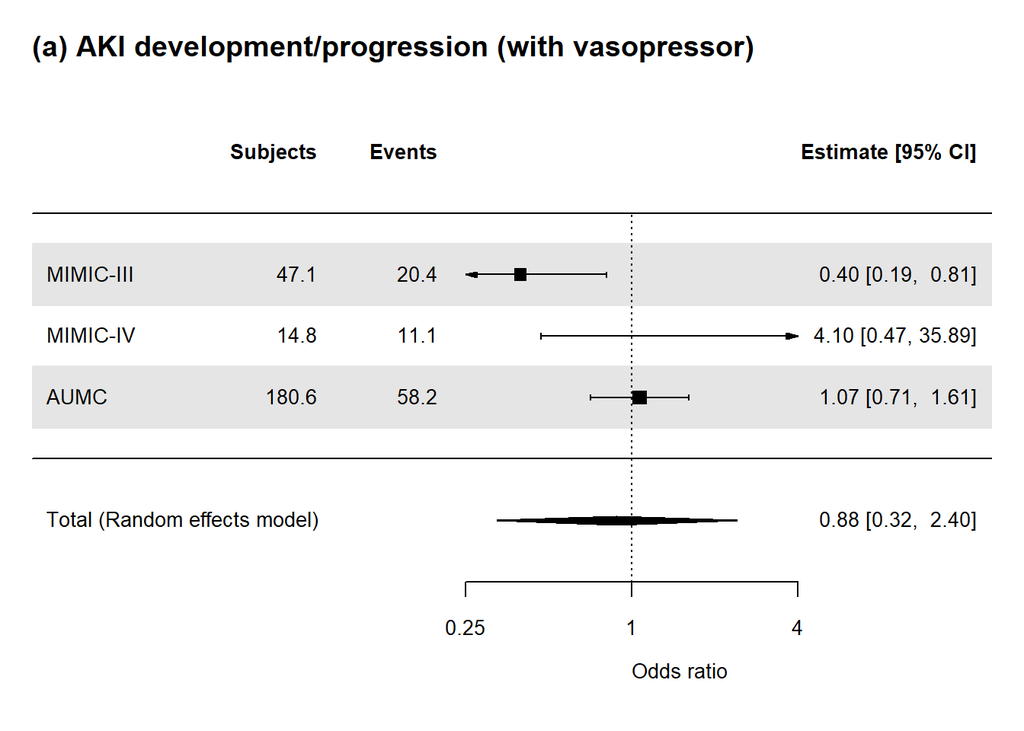

```r
#Forrestplot
FP2("wgt_man_Ovlp_MIMIC3_vaso.rds", FORMULA_ovl2_vaso)
FP2("wgt_man_Ovlp_MIMIC4_vaso.rds", FORMULA_ovl2_vaso)
FP2("wgt_man_Ovlp_AUMC_vaso.rds", FORMULA_ovl2_vaso)

vaso_METADF0 <- rbind(
  readRDS("ORRES_wgt_man_Ovlp_MIMIC3_vaso.rds") %>% mutate("dataset"="MIMIC-III"),
  readRDS("ORRES_wgt_man_Ovlp_MIMIC4_vaso.rds") %>% mutate("dataset"="MIMIC-IV"),
  readRDS("ORRES_wgt_man_Ovlp_AUMC_vaso.rds") %>% mutate("dataset"="AUMC"))
vaso_METADF_AKID <- vaso_METADF0 %>% subset(outcome=="outcome_KDIGO_inc_or_death")
vaso_METADF_AKI <- vaso_METADF0 %>% subset(outcome=="outcome_KDIGO_inc")
vaso_METADF_HD <- vaso_METADF0 %>% subset(outcome=="outcome_new_dial")
vaso_METADF_D <- vaso_METADF0 %>% subset(outcome=="death_in_7d")
vaso_METADF_HDD <- vaso_METADF0 %>% subset(outcome=="outcome_HDD_in7d")
vaso_METARES_AKID <- rma(yi = Estimate, sei = Std.Error, method = "REML", data = vaso_METADF_AKID)
vaso_METARES_AKI <- rma(yi = Estimate, sei = Std.Error, method = "REML", data = vaso_METADF_AKI)
vaso_METARES_HD <- rma(yi = Estimate, sei = Std.Error, method = "REML", data = vaso_METADF_HD)
vaso_METARES_D <- rma(yi = Estimate, sei = Std.Error, method = "REML", data = vaso_METADF_D)
vaso_METARES_HDD <- rma(yi = Estimate, sei = Std.Error, method = "REML", data = vaso_METADF_HDD)

METAF(vaso_METARES_AKI, SCALEA1, SCALEB1, SCALEC1, "(a) AKI development/progression (with vasopressor)")
```

```r
vaso_METARES_AKI
```

```
##
## Random-Effects Model (k = 3; tau^2 estimator: REML)
##
## tau^2 (estimated amount of total heterogeneity): 0.5264 (SE = 0.7935)
## tau (square root of estimated tau^2 value):      0.7255
## I^2 (total heterogeneity / total variability):   76.70%
## H^2 (total variability / sampling variability):  4.29
##
## Test for Heterogeneity:
## Q(df = 2) = 7.5387, p-val = 0.0231
##
## Model Results:
##
## estimate      se     zval    pval    ci.lb   ci.ub
##  -0.1246  0.5105  -0.2441  0.8071  -1.1251  0.8758
##
## ---
## Signif. codes:  0 '***' 0.001 '**' 0.01 '*' 0.05 '.' 0.1 ' ' 1
```

```r
vaso_METADF_AKI %>% dplyr::select(dataset, OR, LCI, UCI, 'Pr(>|z|)') %>% remove_rownames()
```

```
##     dataset        OR       LCI        UCI   Pr(>|z|)
## 1 MIMIC-III 0.3958098 0.1927568  0.8127621 0.01157956
## 2  MIMIC-IV 4.1034361 0.4691323 35.8921940 0.20197662
## 3      AUMC 1.0690212 0.7097502  1.6101530 0.74943583
```

__

__

#### 11d. Backgrounds, outcomes, matching quality, and forest plot among those **non-vasopressor**

```r
#1. overlap-PSM using MIMIC3, Older
OVLP(comb_DF2ovl %>% subset(dataset=="MIMIC3"&vasopressor==F), FORMULA_ovl2_vaso, "Ovlp_MIMIC3_nonvaso", "**Ovlp, MIMIC-III, No-vaso**")
```

| **Characteristic** | **Ovlp, MIMIC-III, No-vaso** **I/C** N=33.2<sup>1</sup> | **Ovlp, MIMIC-III, No-vaso** **NCC** N=33.2<sup>1</sup> | **p-value**<sup>2</sup> |  |
| --- | --- | --- | --- | --- |
| dataset |  |  |  |  |
| MIMIC3 | 33.2 (100.0%) | 33.2 (100.0%) |  |  |
| age_group |  |  | 0.95 |  |
| 18-39 | 2.5 (7.4%) | 3.3 (9.9%) |  |  |
| 40-49 | 4.0 (12.0%) | 3.5 (10.5%) |  |  |
| 50-59 | 6.3 (19.0%) | 6.0 (18.1%) |  |  |
| 60-69 | 8.2 (24.7%) | 6.6 (19.8%) |  |  |
| 70-79 | 6.0 (18.1%) | 7.7 (23.2%) |  |  |
| 80+ | 6.2 (18.7%) | 6.2 (18.5%) |  |  |
| sex |  |  | >0.99 |  |
| Female | 15.5 (46.6%) | 15.5 (46.6%) |  |  |
| Male | 17.7 (53.4%) | 17.7 (53.4%) |  |  |
| bmi | 28.7 (24.3, 31.6) | 28.5 (21.9, 33.2) | 0.93 |  |
| Unknown | 19 | 20 |  |  |
| weight | 75.0 (67.0, 95.0) | 76.0 (60.1, 98.0) | 0.79 |  |
| Unknown | 6 | 9 |  |  |
| ICU type |  |  | >0.99 |  |
| Non-surgery | 20.6 (62.0%) | 20.6 (62.0%) |  |  |
| Surgery | 12.6 (38.0%) | 12.6 (38.0%) |  |  |
| drug_name |  |  |  |  |
| Imipenem/cilastatin | 33.2 (100.0%) | 0.0 (0.0%) |  |  |
| Imipenem/cilastatin/relebactam | 0.0 (0.0%) | 0.0 (0.0%) |  |  |
| Meropenem | 0.0 (0.0%) | 33.2 (100.0%) |  |  |
| Doripenem | 0.0 (0.0%) | 0.0 (0.0%) |  |  |
| Ertapenem | 0.0 (0.0%) | 0.0 (0.0%) |  |  |
| Overdose in first 24h |  |  | 0.11 |  |
| not_over | 33.2 (100.0%) | 32.8 (98.7%) |  |  |
| over | 0.0 (0.0%) | 0.4 (1.3%) |  |  |
| Relative initiation dose (with near eGFR) | 0.3 (0.2, 0.5) | 0.3 (0.3, 0.5) | 0.21 |  |
| sofa | 3.0 (2.0, 5.0) | 3.0 (1.0, 6.0) | 0.79 |  |
| qsofa | 0.0 (0.0, 1.0) | 1.0 (0.0, 1.0) | 0.21 |  |
| Unknown | 0 | 2 |  |  |
| sirs | 2.0 (1.0, 3.0) | 2.0 (1.0, 2.0) | 0.93 |  |
| pre_blood_culture | 23.9 (72.0%) | 23.9 (72.0%) | >0.99 |  |
| pre nephrotoxic drugs use | 17.9 (54.0%) | 17.9 (54.0%) | >0.99 |  |
| pre vancomycin use | 13.7 (41.4%) | 15.8 (47.5%) | 0.48 |  |
| pre aminoglycosied use | 2.6 (7.7%) | 2.8 (8.3%) | 0.89 |  |
| pre NSAIDs use | 2.6 (7.7%) | 3.3 (10.0%) | 0.65 |  |
| pre contrast agent use | 0.0 (0.0%) | 0.0 (0.0%) |  |  |
| pre vasopressor use | 0.0 (0.0%) | 0.0 (0.0%) |  |  |
| pre ventilation | 21.3 (64.0%) | 19.1 (57.6%) | 0.45 |  |
| Baseline sCr | 0.9 (0.6, 1.4) | 0.8 (0.6, 1.3) | 0.44 |  |
| sCr at treatment start | 1.1 (0.7, 1.6) | 1.0 (0.6, 1.6) | 0.43 |  |
| AKI stage at treatment start |  |  | 0.41 |  |
| 0 | 24.3 (73.1%) | 25.2 (75.7%) |  |  |
| 1 | 8.6 (26.0%) | 6.9 (20.7%) |  |  |
| 2 | 0.3 (1.0%) | 1.2 (3.6%) |  |  |
| near_eGFR | 64.9 (38.4, 97.7) | 74.5 (41.5, 104.5) | 0.46 |  |
| observation time | 168.0 (145.0, 168.0) | 168.0 (149.4, 168.0) | 0.70 |  |
| Cencsored with drug change | 1.5 (4.6%) | 0.0 (0.0%) | 0.15 |  |
| RRT at treatment start | 0.0 (0.0%) | 0.0 (0.0%) |  |  |
| O, AKI develop/progress | 7.1 (21.5%) | 11.7 (35.2%) | 0.10 |  |
| O, Death | 3.2 (9.7%) | 4.5 (13.7%) | 0.49 |  |
| O, AKI d/p or death | 8.8 (26.5%) | 13.4 (40.2%) | 0.11 |  |
| O, RRT-intervention | 0.0 (0.0%) | 1.3 (3.8%) | 0.012 |  |
| O, Death or RRT-intervention | 3.2 (9.7%) | 5.6 (17.0%) | 0.23 |  |
| total_dose_ICM | 2,495.2 (1,000.0, 3,500.0) | 4,000.0 (2,871.8, 7,000.0) | <0.001 |  |
| total_dose_recabrio | NA (NA, NA) | NA (NA, NA) |  |  |
| Unknown | 33 | 33 |  |  |
| total_dose_erta | NA (NA, NA) | NA (NA, NA) |  |  |
| Unknown | 33 | 33 |  |  |
| total_dose_dori | NA (NA, NA) | NA (NA, NA) |  |  |
| Unknown | 33 | 33 |  |  |
| ini24h_dose_ICM | 500.0 (500.0, 1,000.0) | 1,000.0 (500.0, 1,000.0) | <0.001 |  |
| ini24h_dose_recabrio | NA (NA, NA) | NA (NA, NA) |  |  |
| Unknown | 33 | 33 |  |  |
| ini24h_dose_erta | NA (NA, NA) | NA (NA, NA) |  |  |
| Unknown | 33 | 33 |  |  |
| ini24h_dose_dori | NA (NA, NA) | NA (NA, NA) |  |  |
| Unknown | 33 | 33 |  |  |
| last_drug_in_obs | 72.0 (48.0, 168.0) | 168.0 (75.2, 168.0) | 0.004 |  |

<sup>1</sup> n (%); Median (Q1, Q3)  
<sup>2</sup> NA; Pearson’s X^2: Rao & Scott adjustment; Design-based KruskalWallis test

```r
#2. overlap-PSM using MIMIC4, Older
OVLP(comb_DF2ovl %>% subset(dataset=="miiv"&vasopressor==F), FORMULA_ovl2_vaso, "Ovlp_MIMIC4_nonvaso", "**Ovlp, MIMIC-IV, No-vaso**")
```

| **Characteristic** | **Ovlp, MIMIC-IV, No-vaso** **I/C** N=77.4<sup>1</sup> | **Ovlp, MIMIC-IV, No-vaso** **NCC** N=77.4<sup>1</sup> | **p-value**<sup>2</sup> |  |
| --- | --- | --- | --- | --- |
| dataset |  |  |  |  |
| miiv | 77.4 (100.0%) | 77.4 (100.0%) |  |  |
| age_group |  |  | 0.79 |  |
| 18-39 | 7.8 (10.1%) | 6.7 (8.7%) |  |  |
| 40-49 | 8.7 (11.3%) | 7.3 (9.5%) |  |  |
| 50-59 | 10.6 (13.8%) | 15.5 (20.1%) |  |  |
| 60-69 | 21.3 (27.5%) | 20.3 (26.2%) |  |  |
| 70-79 | 16.4 (21.2%) | 15.2 (19.7%) |  |  |
| 80+ | 12.5 (16.2%) | 12.3 (15.9%) |  |  |
| sex |  |  | >0.99 |  |
| Female | 32.9 (42.5%) | 32.9 (42.5%) |  |  |
| Male | 44.5 (57.5%) | 44.5 (57.5%) |  |  |
| bmi | 27.2 (25.1, 31.6) | 27.5 (23.6, 33.5) | 0.55 |  |
| Unknown | 38 | 30 |  |  |
| weight | 83.0 (70.5, 99.6) | 78.7 (65.0, 95.3) | 0.075 |  |
| Unknown | 6 | 6 |  |  |
| ICU type |  |  | >0.99 |  |
| Non-surgery | 62.8 (81.1%) | 62.8 (81.1%) |  |  |
| Surgery | 14.6 (18.9%) | 14.6 (18.9%) |  |  |
| drug_name |  |  | <0.001 |  |
| Imipenem/cilastatin | 76.4 (98.7%) | 0.0 (0.0%) |  |  |
| Imipenem/cilastatin/relebactam | 1.0 (1.3%) | 0.0 (0.0%) |  |  |
| Meropenem | 0.0 (0.0%) | 76.9 (99.3%) |  |  |
| Doripenem | 0.0 (0.0%) | 0.1 (0.2%) |  |  |
| Ertapenem | 0.0 (0.0%) | 0.4 (0.5%) |  |  |
| Overdose in first 24h |  |  | 0.83 |  |
| not_over | 76.4 (98.7%) | 76.6 (99.0%) |  |  |
| over | 1.0 (1.3%) | 0.8 (1.0%) |  |  |
| Relative initiation dose (with near eGFR) | 0.3 (0.2, 0.3) | 0.3 (0.3, 0.5) | 0.002 |  |
| sofa | 4.0 (3.0, 6.0) | 5.0 (3.0, 8.0) | 0.16 |  |
| qsofa | 1.0 (0.0, 1.0) | 1.0 (0.0, 1.0) | 0.74 |  |
| Unknown | 0 | 0 |  |  |
| sirs | 2.0 (1.0, 3.0) | 2.0 (1.0, 3.0) | 0.92 |  |
| pre_blood_culture | 58.1 (75.1%) | 58.1 (75.1%) | >0.99 |  |
| pre nephrotoxic drugs use | 59.1 (76.4%) | 59.1 (76.4%) | >0.99 |  |
| pre vancomycin use | 55.3 (71.4%) | 56.7 (73.2%) | 0.72 |  |
| pre aminoglycosied use | 7.7 (10.0%) | 5.9 (7.6%) | 0.43 |  |
| pre NSAIDs use | 3.9 (5.0%) | 6.4 (8.2%) | 0.30 |  |
| pre contrast agent use | 0.0 (0.0%) | 0.9 (1.1%) | <0.001 |  |
| pre vasopressor use | 0.0 (0.0%) | 0.0 (0.0%) |  |  |
| pre ventilation | 3.9 (5.0%) | 1.4 (1.8%) | 0.040 |  |
| Baseline sCr | 1.0 (0.6, 1.5) | 1.0 (0.6, 1.5) | 0.93 |  |
| sCr at treatment start | 1.0 (0.6, 2.0) | 1.1 (0.7, 1.8) | 0.86 |  |
| AKI stage at treatment start |  |  | >0.99 |  |
| 0 | 60.9 (78.7%) | 61.0 (78.8%) |  |  |
| 1 | 13.6 (17.5%) | 13.3 (17.2%) |  |  |
| 2 | 2.9 (3.8%) | 3.1 (4.0%) |  |  |
| near_eGFR | 67.1 (36.5, 100.9) | 66.7 (36.9, 99.5) | 0.78 |  |
| observation time | 168.0 (140.2, 168.0) | 168.0 (167.4, 168.0) | 0.46 |  |
| Cencsored with drug change | 3.9 (5.0%) | 0.0 (0.0%) | 0.040 |  |
| RRT at treatment start | 0.0 (0.0%) | 0.0 (0.0%) |  |  |
| O, AKI develop/progress | 24.2 (31.2%) | 22.2 (28.7%) | 0.62 |  |
| O, Death | 5.8 (7.5%) | 4.6 (5.9%) | 0.54 |  |
| O, AKI d/p or death | 25.1 (32.5%) | 24.2 (31.3%) | 0.82 |  |
| O, RRT-intervention | 1.0 (1.3%) | 4.3 (5.6%) | 0.10 |  |
| O, Death or RRT-intervention | 6.8 (8.8%) | 8.3 (10.8%) | 0.57 |  |
| total_dose_ICM | 1,895.8 (520.8, 3,500.0) | 2,708.3 (1,333.3, 4,000.0) | <0.001 |  |
| Unknown | 1 | 1 |  |  |
| total_dose_recabrio | NA (NA, NA) | NA (NA, NA) |  |  |
| Unknown | 76 | 77 |  |  |
| total_dose_erta | NA (NA, NA) | NA (NA, NA) |  |  |
| Unknown | 77 | 77 |  |  |
| total_dose_dori | NA (NA, NA) | NA (NA, NA) |  |  |
| Unknown | 77 | 77 |  |  |
| ini24h_dose_ICM | 500.0 (500.0, 500.0) | 1,000.0 (500.0, 1,000.0) | <0.001 |  |
| Unknown | 1 | 1 |  |  |
| ini24h_dose_recabrio | NA (NA, NA) | NA (NA, NA) |  |  |
| Unknown | 76 | 77 |  |  |
| ini24h_dose_erta | NA (NA, NA) | NA (NA, NA) |  |  |
| Unknown | 77 | 77 |  |  |
| ini24h_dose_dori | NA (NA, NA) | NA (NA, NA) |  |  |
| Unknown | 77 | 77 |  |  |
| last_drug_in_obs | 71.0 (25.0, 168.0) | 103.0 (41.0, 168.0) | 0.11 |  |

<sup>1</sup> n (%); Median (Q1, Q3)  
<sup>2</sup> NA; Pearson’s X^2: Rao & Scott adjustment; Design-based KruskalWallis test

```r
#3. overlap-PSM using AUMC, Older
OVLP(comb_DF2ovl %>% subset(dataset=="AUMC"&vasopressor==F), FORMULA_ovl2_vaso, "Ovlp_AUMC_nonvaso", "**Ovlp, AUMC, No-vaso**")
```

| **Characteristic** | **Ovlp, AUMC, No-vaso** **I/C** N=52.0<sup>1</sup> | **Ovlp, AUMC, No-vaso** **NCC** N=52.0<sup>1</sup> | **p-value**<sup>2</sup> |  |
| --- | --- | --- | --- | --- |
| dataset |  |  |  |  |
| AUMC | 52.0 (100.0%) | 52.0 (100.0%) |  |  |
| age_group |  |  | 0.063 |  |
| 18-39 | 8.0 (15.3%) | 10.2 (19.6%) |  |  |
| 40-49 | 6.3 (12.2%) | 6.0 (11.6%) |  |  |
| 50-59 | 12.2 (23.5%) | 9.2 (17.8%) |  |  |
| 60-69 | 18.4 (35.3%) | 13.7 (26.3%) |  |  |
| 70-79 | 4.9 (9.5%) | 12.2 (23.5%) |  |  |
| 80+ | 2.2 (4.2%) | 0.6 (1.2%) |  |  |
| sex |  |  | >0.99 |  |
| Female | 22.1 (42.5%) | 22.1 (42.5%) |  |  |
| Male | 29.9 (57.5%) | 29.9 (57.5%) |  |  |
| bmi | 24.5 (21.9, 27.8) | 24.8 (21.9, 27.8) | 0.45 |  |
| Unknown | 7 | 3 |  |  |
| weight | 75.0 (65.0, 85.0) | 75.0 (65.0, 95.0) | 0.26 |  |
| Unknown | 6 | 3 |  |  |
| ICU type |  |  | >0.99 |  |
| Non-surgery | 27.5 (52.9%) | 27.5 (52.9%) |  |  |
| Surgery | 24.5 (47.1%) | 24.5 (47.1%) |  |  |
| drug_name |  |  |  |  |
| Imipenem/cilastatin | 52.0 (100.0%) | 0.0 (0.0%) |  |  |
| Imipenem/cilastatin/relebactam | 0.0 (0.0%) | 0.0 (0.0%) |  |  |
| Meropenem | 0.0 (0.0%) | 52.0 (100.0%) |  |  |
| Doripenem | 0.0 (0.0%) | 0.0 (0.0%) |  |  |
| Ertapenem | 0.0 (0.0%) | 0.0 (0.0%) |  |  |
| Overdose in first 24h |  |  | 0.79 |  |
| not_over | 51.6 (99.1%) | 51.3 (98.7%) |  |  |
| over | 0.5 (0.9%) | 0.7 (1.3%) |  |  |
| Relative initiation dose (with near eGFR) | 0.3 (0.2, 0.3) | 0.5 (0.3, 0.7) | <0.001 |  |
| sofa | 5.0 (3.0, 7.0) | 4.0 (3.0, 7.0) | 0.87 |  |
| Unknown | 7 | 8 |  |  |
| qsofa | 1.0 (0.0, 1.0) | 1.0 (0.0, 1.0) | 0.95 |  |
| Unknown | 0 | 0 |  |  |
| sirs | 2.0 (1.0, 3.0) | 2.0 (1.0, 3.0) | 0.95 |  |
| pre_blood_culture | 7.5 (14.3%) | 7.5 (14.3%) | >0.99 |  |
| pre nephrotoxic drugs use | 27.7 (53.2%) | 27.7 (53.2%) | >0.99 |  |
| pre vancomycin use | 23.0 (44.3%) | 24.9 (47.9%) | 0.59 |  |
| pre aminoglycosied use | 6.8 (13.1%) | 2.0 (3.8%) | 0.027 |  |
| pre NSAIDs use | 0.9 (1.8%) | 2.8 (5.4%) | 0.14 |  |
| pre contrast agent use | 0.6 (1.1%) | 0.0 (0.0%) | 0.16 |  |
| pre vasopressor use | 0.0 (0.0%) | 0.0 (0.0%) |  |  |
| pre ventilation | 21.2 (40.7%) | 17.6 (33.8%) | 0.31 |  |
| Baseline sCr | 0.8 (0.6, 1.1) | 0.7 (0.5, 1.1) | 0.079 |  |
| sCr at treatment start | 1.0 (0.7, 1.4) | 0.8 (0.6, 1.5) | 0.11 |  |
| AKI stage at treatment start |  |  | 0.98 |  |
| 0 | 40.3 (77.4%) | 40.0 (77.0%) |  |  |
| 1 | 8.8 (16.8%) | 9.2 (17.8%) |  |  |
| 2 | 3.0 (5.7%) | 2.7 (5.3%) |  |  |
| near_eGFR | 82.4 (52.3, 103.0) | 96.3 (45.0, 111.8) | 0.16 |  |
| observation time | 117.3 (38.0, 168.0) | 162.0 (51.7, 168.0) | 0.10 |  |
| Cencsored with drug change | 2.6 (5.1%) | 0.6 (1.1%) | 0.10 |  |
| RRT at treatment start | 0.0 (0.0%) | 0.0 (0.0%) |  |  |
| O, AKI develop/progress | 12.4 (23.9%) | 12.3 (23.7%) | 0.97 |  |
| O, Death | 5.5 (10.6%) | 3.5 (6.6%) | 0.32 |  |
| O, AKI d/p or death | 14.7 (28.3%) | 13.7 (26.3%) | 0.75 |  |
| O, RRT-intervention | 4.6 (8.8%) | 6.2 (11.9%) | 0.46 |  |
| O, Death or RRT-intervention | 8.2 (15.7%) | 7.6 (14.5%) | 0.82 |  |
| total_dose_ICM | 6,000.0 (2,500.0, 12,500.0) | 12,750.0 (6,000.0, 24,000.0) | <0.001 |  |
| total_dose_recabrio | NA (NA, NA) | NA (NA, NA) |  |  |
| Unknown | 52 | 52 |  |  |
| total_dose_erta | NA (NA, NA) | NA (NA, NA) |  |  |
| Unknown | 52 | 52 |  |  |
| total_dose_dori | NA (NA, NA) | NA (NA, NA) |  |  |
| Unknown | 52 | 52 |  |  |
| ini24h_dose_ICM | 500.0 (500.0, 500.0) | 1,000.0 (1,000.0, 2,000.0) | <0.001 |  |
| ini24h_dose_recabrio | NA (NA, NA) | NA (NA, NA) |  |  |
| Unknown | 52 | 52 |  |  |
| ini24h_dose_erta | NA (NA, NA) | NA (NA, NA) |  |  |
| Unknown | 52 | 52 |  |  |
| ini24h_dose_dori | NA (NA, NA) | NA (NA, NA) |  |  |
| Unknown | 52 | 52 |  |  |
| last_drug_in_obs | 66.0 (24.0, 168.0) | 80.0 (35.1, 168.0) | 0.31 |  |

<sup>1</sup> n (%); Median (Q1, Q3)  
<sup>2</sup> NA; Pearson’s X^2: Rao & Scott adjustment; Design-based KruskalWallis test

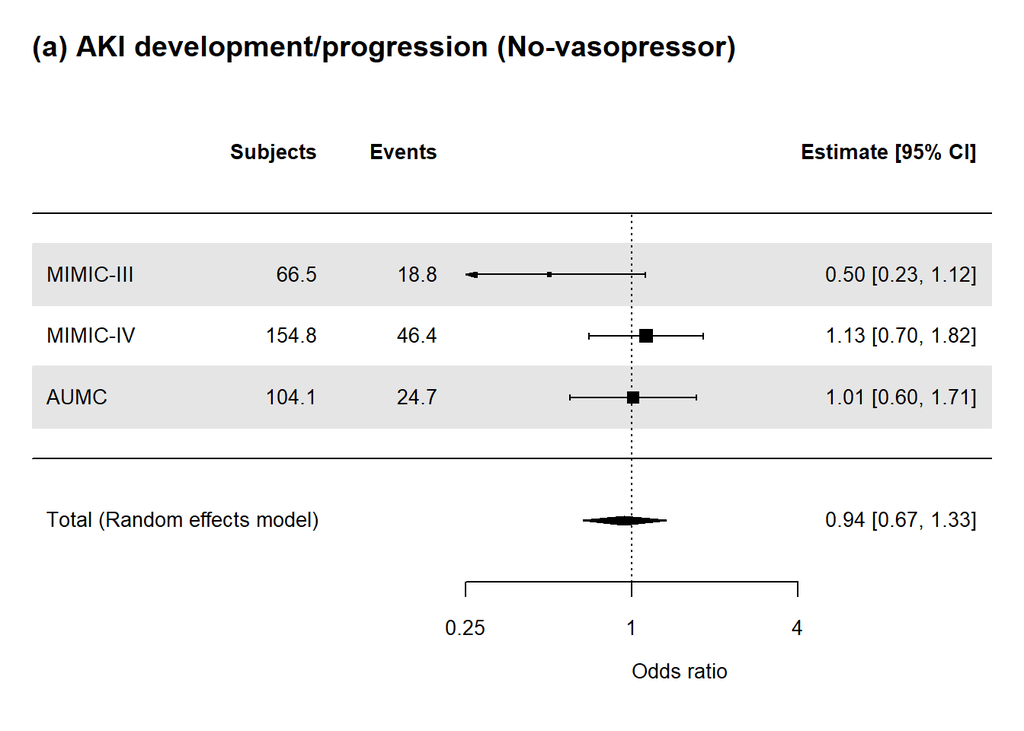

```r
FP2("wgt_man_Ovlp_MIMIC4_nonvaso.rds", FORMULA_ovl2_vaso)
FP2("wgt_man_Ovlp_MIMIC3_nonvaso.rds", FORMULA_ovl2_vaso)
FP2("wgt_man_Ovlp_AUMC_nonvaso.rds", FORMULA_ovl2_vaso)

nonvaso_METADF0 <- rbind(
  readRDS("ORRES_wgt_man_Ovlp_MIMIC3_nonvaso.rds") %>% mutate("dataset"="MIMIC-III"),
  readRDS("ORRES_wgt_man_Ovlp_MIMIC4_nonvaso.rds") %>% mutate("dataset"="MIMIC-IV"),
  readRDS("ORRES_wgt_man_Ovlp_AUMC_nonvaso.rds") %>% mutate("dataset"="AUMC"))
nonvaso_METADF_AKID <- nonvaso_METADF0 %>% subset(outcome=="outcome_KDIGO_inc_or_death")
nonvaso_METADF_AKI <- nonvaso_METADF0 %>% subset(outcome=="outcome_KDIGO_inc")
nonvaso_METADF_HD <- nonvaso_METADF0 %>% subset(outcome=="outcome_new_dial")
nonvaso_METADF_D <- nonvaso_METADF0 %>% subset(outcome=="death_in_7d")
nonvaso_METADF_HDD <- nonvaso_METADF0 %>% subset(outcome=="outcome_HDD_in7d")

nonvaso_METARES_AKID <- rma(yi = Estimate, sei = Std.Error, method = "REML", data = nonvaso_METADF_AKID)
nonvaso_METARES_AKI <-rma(yi = Estimate, sei = Std.Error, method = "REML", data = nonvaso_METADF_AKI)
nonvaso_METARES_HD <- rma(yi = Estimate, sei = Std.Error, method = "REML", data = nonvaso_METADF_HD)
nonvaso_METARES_D <- rma(yi = Estimate, sei = Std.Error, method = "REML", data = nonvaso_METADF_D)
nonvaso_METARES_HDD <- rma(yi = Estimate, sei = Std.Error, method = "REML", data = nonvaso_METADF_HDD)

METAF(nonvaso_METARES_AKI, SCALEA1, SCALEB1, SCALEC1, "(a) AKI development/progression (No-vasopressor)")
```

```r
nonvaso_METARES_AKI
```

```
##
## Random-Effects Model (k = 3; tau^2 estimator: REML)
##
## tau^2 (estimated amount of total heterogeneity): 0.0100 (SE = 0.0947)
## tau (square root of estimated tau^2 value):      0.1001
## I^2 (total heterogeneity / total variability):   10.23%
## H^2 (total variability / sampling variability):  1.11
##
## Test for Heterogeneity:
## Q(df = 2) = 2.9719, p-val = 0.2263
##
## Model Results:
##
## estimate      se     zval    pval    ci.lb   ci.ub
##  -0.0619  0.1763  -0.3514  0.7253  -0.4074  0.2835
##
## ---
## Signif. codes:  0 '***' 0.001 '**' 0.01 '*' 0.05 '.' 0.1 ' ' 1
```

```r
nonvaso_METADF_AKI %>% dplyr::select(dataset, OR, LCI, UCI, 'Pr(>|z|)') %>% remove_rownames()
```

```
##     dataset        OR       LCI      UCI  Pr(>|z|)
## 1 MIMIC-III 0.5032994 0.2260094 1.120795 0.0928043
## 2  MIMIC-IV 1.1282572 0.6993666 1.820168 0.6209233
## 3      AUMC 1.0126782 0.5980791 1.714685 0.9626026
```

#### 12. Firth’s regression -> forest plot.

In some subgroup analyses, outcomes only developed one group. Then, we couldn’t estimate odds ratio. Therefore, we estimated the ratio using Firth’s regression

```r
#Firth's method function
library(logistf) #install.packages("logistf")
DF <- readRDS("wgt_man_Ovlp_MIMIC3_base12.rds")
DF$drug_type <- DF$drug_type %>% factor() %>% relevel(, ref = "NCC")
saveRDS(DF,"wgt_man_Ovlp_MIMIC3_base12.rds")
#logistf(formula = as.formula("outcome_KDIGO_inc ~ drug_type"), data  = readRDS("wgt_man_Ovlp_MIMIC3_base12.rds"), weights = ovlp_wgt)

OVLP_OR_F <- function(DF, FORM, OUTCOME, TITLE){
fit <- logistf(formula = as.formula(paste0(OUTCOME," ~ drug_type")), data  = DF, weights = ovlp_wgt)
fit %>% summary() %>% print()
est<-coef(fit)["drug_typeI/C"]
ci<-confint(fit)["drug_typeI/C", ]
summary1 <- data.frame(Estimate = est, Std.Error = (ci[2] - ci[1]) / (2 * 1.96), lwr=ci[1], upr=ci[2],
                       study=TITLE, outcome=OUTCOME)
svy_design <- svydesign(~1, data = DF %>% as.data.frame(), weights = DF$ovlp_wgt)
fmla <- as.formula(paste("~", OUTCOME))
summary1 <- summary1 %>% mutate("pts"= svytable(fmla, svy_design) %>% as.data.frame() %>% .$Freq %>% sum(),
                                "events"=svytable(fmla, svy_design) %>% as.data.frame() %>% filter(.data[[OUTCOME]]==T) %>% .$Freq %>% sum())
summary1
}

FP2_F <- function(RDS, FORM,  OUTCOME, TITLE){
OR_RES_F <- OVLP_OR_F(readRDS(RDS), FORM, OUTCOME, TITLE) %>%
  mutate("events_percentage"=events/sum(.$event), "pts_percentage"=pts/sum(.$pts))
saveRDS(OR_RES_F, paste0("ORRES_F_",RDS))}



### Start with each assessment
## Subgroup with AKI at treatment start -> AKI progression in mimic3
FP2_F("wgt_man_Ovlp_MIMIC3_base12.rds", FORMULA_ovl2, "outcome_KDIGO_inc", "AKI progression")
```

```
## logistf(formula = as.formula(paste0(OUTCOME, " ~ drug_type")),
##     data = DF, weights = ovlp_wgt)
##
## Model fitted by Penalized ML
## Coefficients:
##                   coef  se(coef) lower 0.95 upper 0.95    Chisq           p
## (Intercept)  -1.573733 0.6802401  -3.166596 -0.3859496 7.130255 0.007579393
## drug_typeI/C -1.807034 1.5908389  -6.766677  0.7953502 1.730872 0.188299601
##              method
## (Intercept)       2
## drug_typeI/C      2
##
## Method: 1-Wald, 2-Profile penalized log-likelihood, 3-None
##
## Likelihood ratio test=1.730872 on 1 df, p=0.1882996, n=28.39331
## Wald test = 10.87904 on 1 df, p = 0.000972589logistf(formula = as.formula(paste0(OUTCOME, " ~ drug_type")),
##     data = DF, weights = ovlp_wgt)
## Model fitted by Penalized ML
## Confidence intervals and p-values by Profile Likelihood
##
## Coefficients:
##  (Intercept) drug_typeI/C
##    -1.573733    -1.807034
##
## Likelihood ratio test=1.730872 on 1 df, p=0.1882996, n=28.39331
```

```r
base12_METADF_F0 <- rbind( #Firth method only used for MIMIC3
  readRDS("ORRES_F_wgt_man_Ovlp_MIMIC3_base12.rds") %>% dplyr::select(Estimate, Std.Error, outcome, pts, events) %>% mutate("dataset"="MIMIC-III"),
  readRDS("ORRES_wgt_man_Ovlp_MIMIC4_base12.rds") %>% dplyr::select(Estimate, Std.Error, outcome, pts, events) %>% mutate("dataset"="MIMIC-IV"),
  readRDS("ORRES_wgt_man_Ovlp_AUMC_base12.rds") %>% dplyr::select(Estimate, Std.Error, outcome, pts, events) %>%mutate("dataset"="AUMC"))

base12_METADF_F_AKI <- base12_METADF_F0 %>% subset(outcome=="outcome_KDIGO_inc")
base12_METARES_F_AKI <- rma(yi = Estimate, sei = Std.Error, method = "REML", data = base12_METADF_F_AKI)

base12_METARES_F_AKI
```

```
##
## Random-Effects Model (k = 3; tau^2 estimator: REML)
##
## tau^2 (estimated amount of total heterogeneity): 0 (SE = 0.1588)
## tau (square root of estimated tau^2 value):      0
## I^2 (total heterogeneity / total variability):   0.00%
## H^2 (total variability / sampling variability):  1.00
##
## Test for Heterogeneity:
## Q(df = 2) = 1.4119, p-val = 0.4936
##
## Model Results:
##
## estimate      se     zval    pval    ci.lb   ci.ub
##  -0.2380  0.2298  -1.0358  0.3003  -0.6884  0.2124
##
## ---
## Signif. codes:  0 '***' 0.001 '**' 0.01 '*' 0.05 '.' 0.1 ' ' 1
```

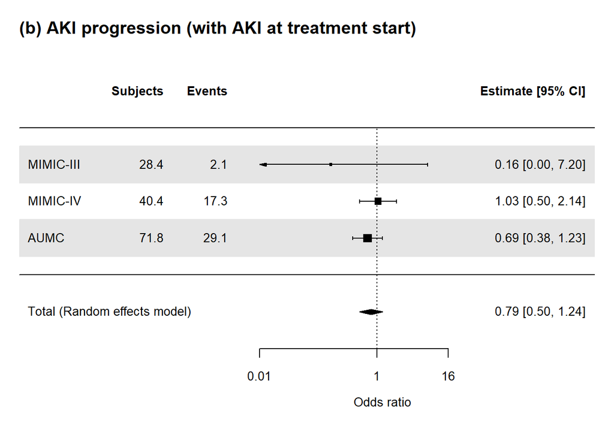

```r
SCALEA4<-c(0.01, 1, 16)
SCALEB4 <- c(-14,8.5)
SCALEC4 <- c(-8,-5.5)
METAF(base12_METARES_F_AKI, SCALEA4, SCALEB4, SCALEC4, "(b) AKI progression (with AKI at treatment start)")
```

```r
## Subgroup without AKI at treatment start -> RRT in mimic4
DFbase <- readRDS("wgt_man_Ovlp_MIMIC4_base0.rds")
DFbase$drug_type <- DFbase$drug_type %>% factor() %>% relevel(, ref = "NCC")
saveRDS(DFbase,"wgt_man_Ovlp_MIMIC4_base0.rds")
FP2_F("wgt_man_Ovlp_MIMIC4_base0.rds", FORMULA_ovl2, "outcome_new_dial", "hemodialysis")
```

```
## logistf(formula = as.formula(paste0(OUTCOME, " ~ drug_type")),
##     data = DF, weights = ovlp_wgt)
##
## Model fitted by Penalized ML
## Coefficients:
##                   coef  se(coef) lower 0.95 upper 0.95     Chisq            p
## (Intercept)  -3.067682 0.5986906  -4.499930 -2.0663533 67.396484 2.220446e-16
## drug_typeI/C -1.802483 1.5407059  -6.724216  0.6446877  1.940798 1.635819e-01
##              method
## (Intercept)       2
## drug_typeI/C      2
##
## Method: 1-Wald, 2-Profile penalized log-likelihood, 3-None
##
## Likelihood ratio test=1.940798 on 1 df, p=0.1635819, n=129.3424
## Wald test = 38.0242 on 1 df, p = 6.987263e-10logistf(formula = as.formula(paste0(OUTCOME, " ~ drug_type")),
##     data = DF, weights = ovlp_wgt)
## Model fitted by Penalized ML
## Confidence intervals and p-values by Profile Likelihood
##
## Coefficients:
##  (Intercept) drug_typeI/C
##    -3.067682    -1.802483
##
## Likelihood ratio test=1.940798 on 1 df, p=0.1635819, n=129.3424
```

```r
base0_METADF_F0 <- rbind( #Firth method only used for MIMIC4
  readRDS("ORRES_wgt_man_Ovlp_MIMIC3_base0.rds") %>% dplyr::select(Estimate, Std.Error, outcome, pts, events) %>% mutate("dataset"="MIMIC-III"),
  readRDS("ORRES_F_wgt_man_Ovlp_MIMIC4_base0.rds") %>% dplyr::select(Estimate, Std.Error, outcome, pts, events) %>% mutate("dataset"="MIMIC-IV"),
  readRDS("ORRES_wgt_man_Ovlp_AUMC_base0.rds") %>% dplyr::select(Estimate, Std.Error, outcome, pts, events) %>%mutate("dataset"="AUMC"))

base0_METADF_F_HD <- base0_METADF_F0 %>% subset(outcome=="outcome_new_dial")
base0_METARES_F_HD <- rma(yi = Estimate, sei = Std.Error, method = "REML", data = base0_METADF_F_HD)

base0_METARES_F_HD
```

```
##
## Random-Effects Model (k = 3; tau^2 estimator: REML)
##
## tau^2 (estimated amount of total heterogeneity): 0 (SE = 0.5516)
## tau (square root of estimated tau^2 value):      0
## I^2 (total heterogeneity / total variability):   0.00%
## H^2 (total variability / sampling variability):  1.00
##
## Test for Heterogeneity:
## Q(df = 2) = 1.1304, p-val = 0.5682
##
## Model Results:
##
## estimate      se     zval    pval    ci.lb   ci.ub
##  -0.2214  0.3673  -0.6027  0.5467  -0.9413  0.4986
##
## ---
## Signif. codes:  0 '***' 0.001 '**' 0.01 '*' 0.05 '.' 0.1 ' ' 1
```

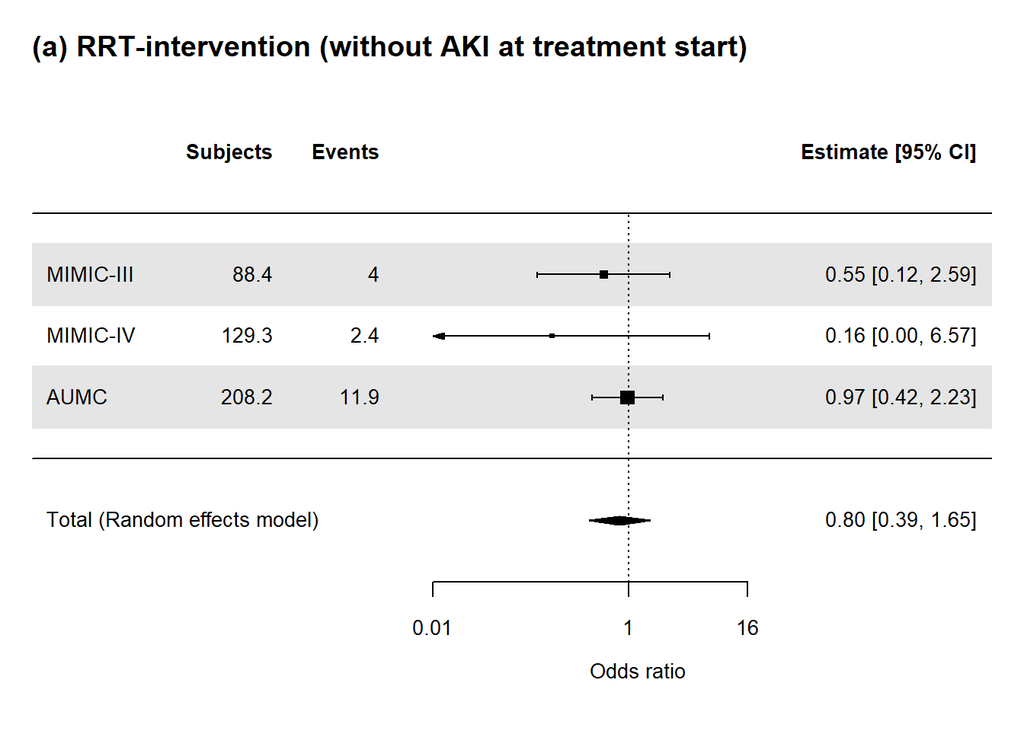

```r
METAF(base0_METARES_F_HD, SCALEA4, SCALEB4, SCALEC4, "(a) RRT-intervention (without AKI at treatment start)")
```

```r
## Subgroup with AKI at treatment start -> RRT in mimic3
DFbase <- readRDS("wgt_man_Ovlp_MIMIC3_base12.rds")
DFbase$drug_type <- DFbase$drug_type %>% factor() %>% relevel(, ref = "NCC")
saveRDS(DFbase,"wgt_man_Ovlp_MIMIC3_base12.rds")
FP2_F("wgt_man_Ovlp_MIMIC3_base12.rds", FORMULA_ovl2, "outcome_new_dial", "hemodialysis")
```

```
## logistf(formula = as.formula(paste0(OUTCOME, " ~ drug_type")),
##     data = DF, weights = ovlp_wgt)
##
## Model fitted by Penalized ML
## Coefficients:
##                    coef se(coef) lower 0.95 upper 0.95      Chisq            p
## (Intercept)  -2.6464967 1.031701  -5.530466  -1.047267 13.6598645 0.0002190873
## drug_typeI/C -0.7342704 1.769873  -5.815681   2.797787  0.1822875 0.6694147669
##              method
## (Intercept)       2
## drug_typeI/C      2
##
## Method: 1-Wald, 2-Profile penalized log-likelihood, 3-None
##
## Likelihood ratio test=0.1822875 on 1 df, p=0.6694148, n=28.39331
## Wald test = 12.1069 on 1 df, p = 0.0005023564logistf(formula = as.formula(paste0(OUTCOME, " ~ drug_type")),
##     data = DF, weights = ovlp_wgt)
## Model fitted by Penalized ML
## Confidence intervals and p-values by Profile Likelihood
##
## Coefficients:
##  (Intercept) drug_typeI/C
##   -2.6464967   -0.7342704
##
## Likelihood ratio test=0.1822875 on 1 df, p=0.6694148, n=28.39331
```

```r
base12_METADF_F0 <- rbind( #Firth method only used for MIMIC3
  readRDS("ORRES_F_wgt_man_Ovlp_MIMIC3_base12.rds") %>% dplyr::select(Estimate, Std.Error, outcome, pts, events) %>% mutate("dataset"="MIMIC-III"),
  readRDS("ORRES_wgt_man_Ovlp_MIMIC4_base12.rds") %>% dplyr::select(Estimate, Std.Error, outcome, pts, events) %>% mutate("dataset"="MIMIC-IV"),
  readRDS("ORRES_wgt_man_Ovlp_AUMC_base12.rds") %>% dplyr::select(Estimate, Std.Error, outcome, pts, events) %>%mutate("dataset"="AUMC"))

base12_METADF_F_HD <- base12_METADF_F0 %>% subset(outcome=="outcome_new_dial")
base12_METARES_F_HD <- rma(yi = Estimate, sei = Std.Error, method = "REML", data = base12_METADF_F_HD)

base12_METARES_F_HD
```

```
##
## Random-Effects Model (k = 3; tau^2 estimator: REML)
##
## tau^2 (estimated amount of total heterogeneity): 0 (SE = 0.2616)
## tau (square root of estimated tau^2 value):      0
## I^2 (total heterogeneity / total variability):   0.00%
## H^2 (total variability / sampling variability):  1.00
##
## Test for Heterogeneity:
## Q(df = 2) = 0.4050, p-val = 0.8167
##
## Model Results:
##
## estimate      se     zval    pval    ci.lb   ci.ub
##  -0.2385  0.2868  -0.8316  0.4056  -0.8007  0.3237
##
## ---
## Signif. codes:  0 '***' 0.001 '**' 0.01 '*' 0.05 '.' 0.1 ' ' 1
```

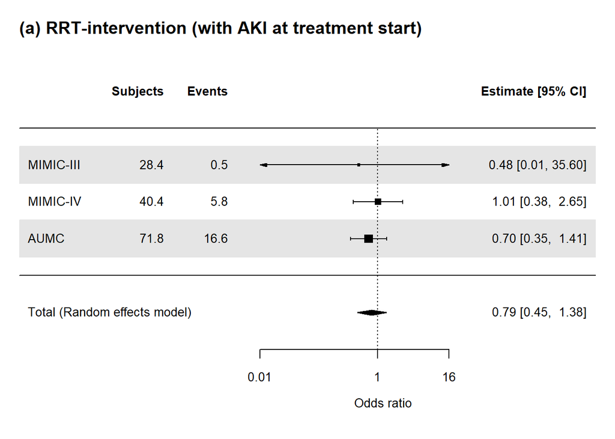

```r
METAF(base12_METARES_F_HD, SCALEA4, SCALEB4, SCALEC4, "(a) RRT-intervention (with AKI at treatment start)")
```

```r
#export
#subgroup main
tiff("Figure 4 (subgroup AKI).tif",
     width = 6,
     height = 8,     # Tall file to fit 3 plots vertically
     units = "in",
     res = 300,
     compression = "lzw")
par(mfrow = c(2, 1))
METAF(base0_METARES_AKI, SCALEA1, SCALEB1, SCALEC1, "(a) AKI development (without AKI at treatment start)")
METAF(base12_METARES_F_AKI, SCALEA4, SCALEB4, SCALEC4, "(b) AKI progression (with AKI at treatment start)")
dev.off()
```

```r
#export wo AKI
tiff("eFigure 4 (secondary wo AKI).tif",
     width = 6,
     height = 8,
     units = "in",
     res = 300,
     compression = "lzw")
par(mfrow = c(3, 1))
METAF(base0_METARES_F_HD, SCALEA4, SCALEB4, SCALEC4, "(a) RRT-intervention (without AKI at treatment start)")
METAF(base0_METARES_D, SCALEA1, SCALEB1, SCALEC1, "(b) Death (without AKI at treatment start)")
METAF(base0_METARES_HDD, SCALEA1, SCALEB1, SCALEC1, "(c) RRT-intervention or death (without AKI at treatment start)")
dev.off()
```

```r
#export w AKI
tiff("eFigure 5 (secondary w AKI).tif",
     width = 6,
     height = 8,
     units = "in",
     res = 300,
     compression = "lzw")
par(mfrow = c(3, 1))
METAF(base12_METARES_F_HD, SCALEA4, SCALEB4, SCALEC4, "(a) RRT-intervention (with AKI at treatment start)")
METAF(base12_METARES_D, SCALEA1, SCALEB1, SCALEC1, "(b) Death (with AKI at treatment start)")
METAF(base12_METARES_HDD, SCALEA1, SCALEB1, SCALEC1, "(c) RRT-intervention or death (with AKI at treatment start)")
dev.off()
```

__

#### 13. Summary of subgroup analysis

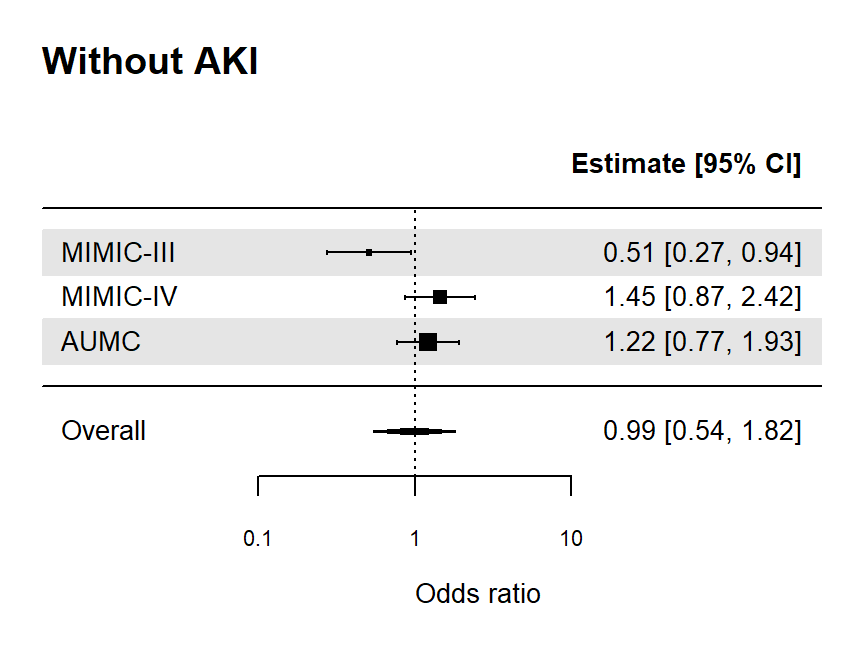

```r
SCALEAsub<-c(0.25, 1, 4)
SCALEBsub <- c(-2.8,3.5)

SCALEAsub2<-c(0.1, 1, 10)
SCALEBsub2 <- c(-5.5, 6)

METAF2 <- function(METARES, AAA, BBB,TITLE){
metafor::forest(METARES,  atransf=exp, at=log(AAA), slab = dataset,
       xlim=BBB,
       #ilab=cbind(round(pts, digits=1), round(events, digits=1)),
       #ilab.lab=c("Subjects","Events"), ilab.pos = 2,
       #ilab.xpos=CCC,
       cex=0.85, cex.axis=0.7, annotate=T,
       header="", xlab="Odds ratio", mlab="Overall", shade=TRUE,
       main=TITLE, adj=0)
}
METAF2(base0_METARES_AKI, SCALEAsub2, SCALEBsub2,  "Without AKI")
```

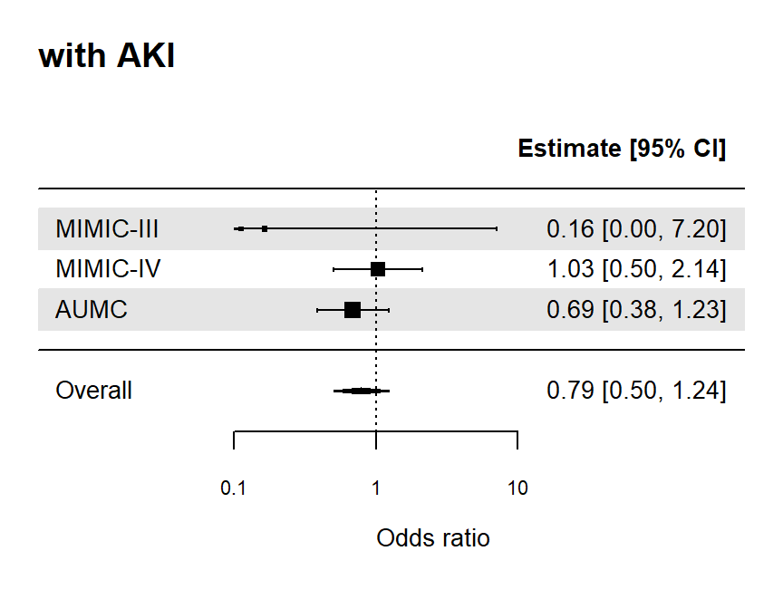

```r
METAF2(base12_METARES_F_AKI, SCALEAsub2, SCALEBsub2, "with AKI") #Filth!!!
```

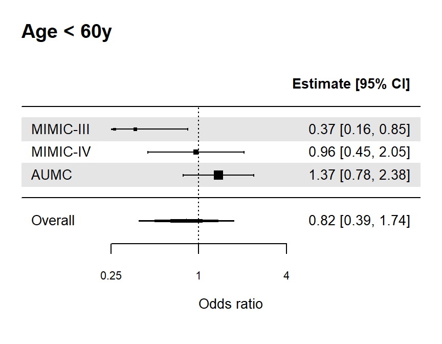

```r
METAF2(Young_METARES_AKI, SCALEAsub, SCALEBsub, "Age < 60y")
```

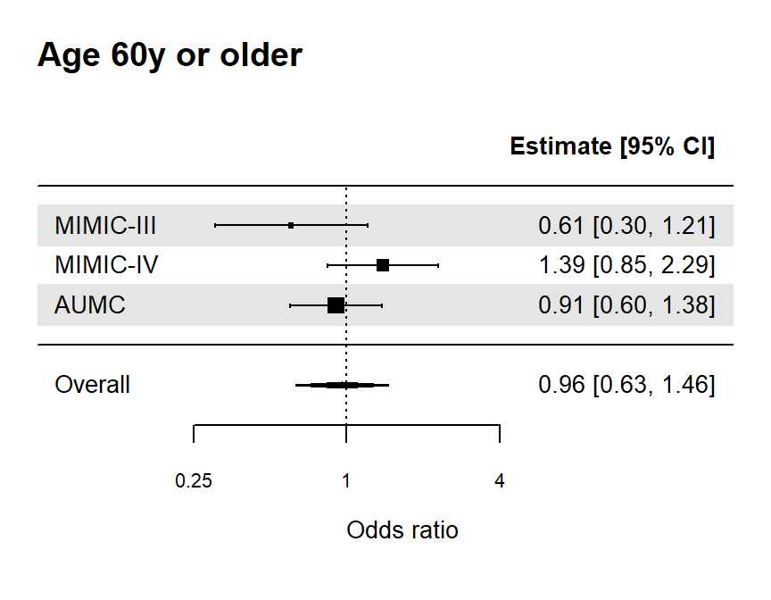

```r
METAF2(Old_METARES_AKI, SCALEAsub, SCALEBsub, "Age 60y or older")
```

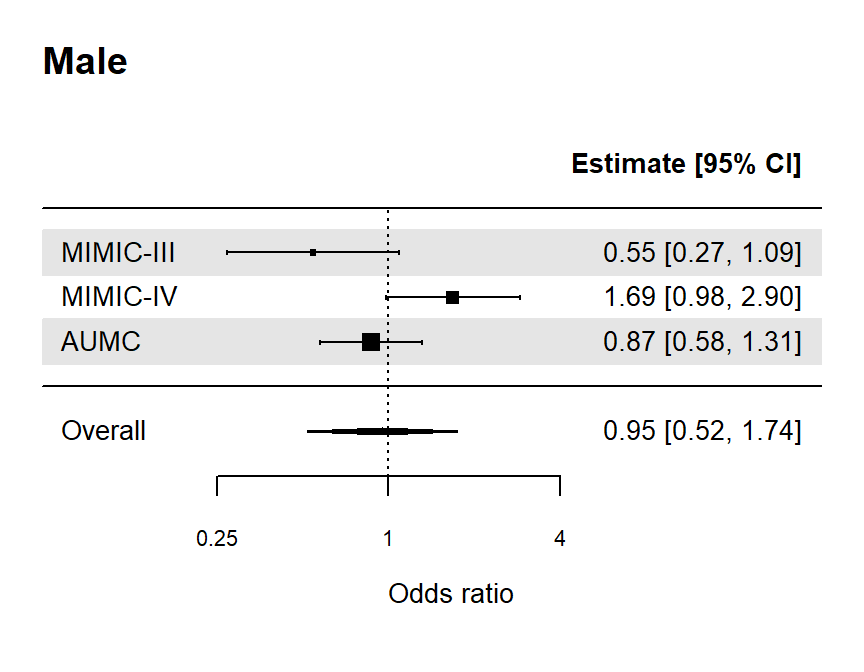

```r
METAF2(Male_METARES_AKI, SCALEAsub, SCALEBsub, "Male")
```

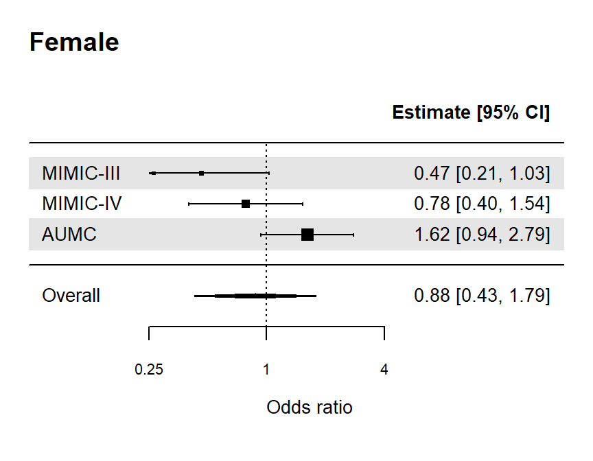

```r
METAF2(Female_METARES_AKI, SCALEAsub, SCALEBsub, "Female")
```

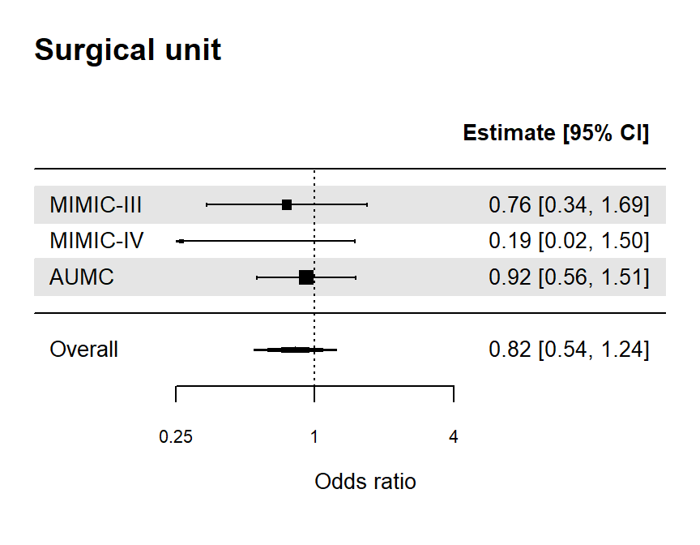

```r
METAF2(surg_METARES_AKI, SCALEAsub, SCALEBsub, "Surgical unit")
```

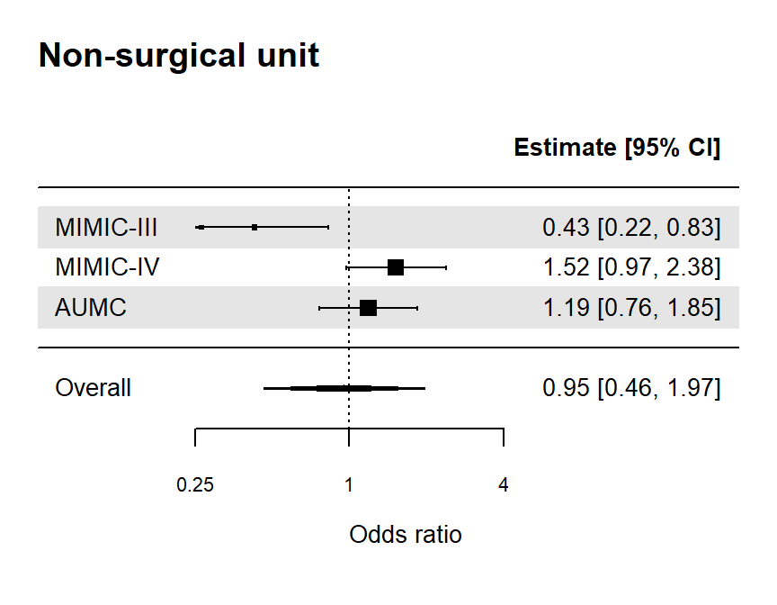

```r
METAF2(nonsurg_METARES_AKI, SCALEAsub, SCALEBsub, "Non-surgical unit")
```

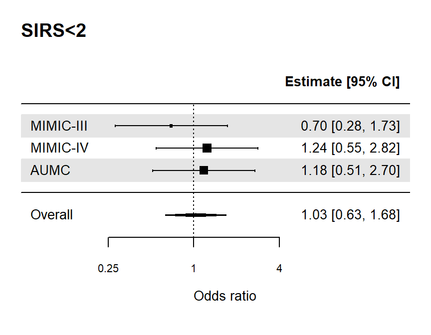

```r
METAF2(Lsirs_METARES_AKI, SCALEAsub, SCALEBsub, "SIRS<2")
```

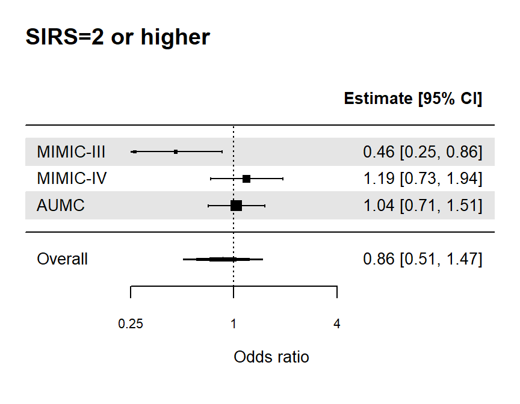

```r
METAF2(Hsirs_METARES_AKI, SCALEAsub, SCALEBsub, "SIRS=2 or higher")
```

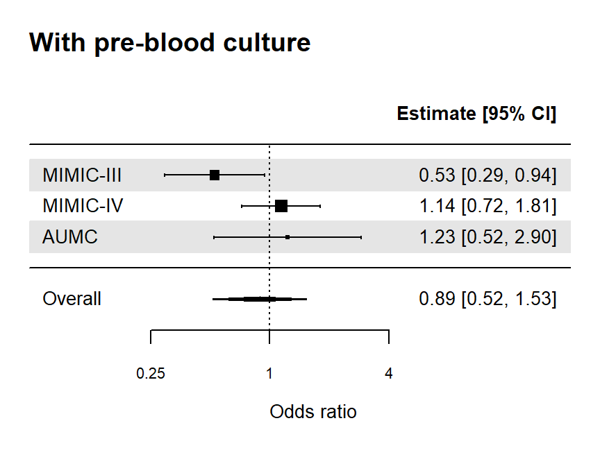

```r
METAF2(bc_METARES_AKI, SCALEAsub, SCALEBsub, "With pre-blood culture")
```

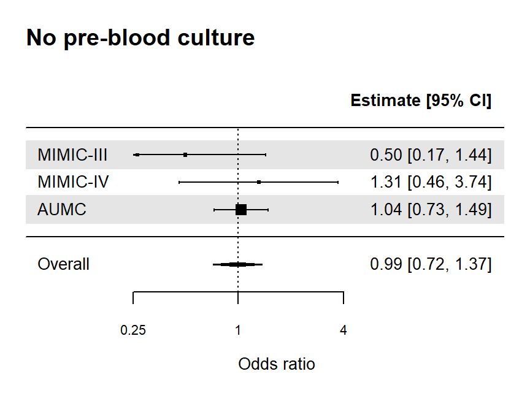

```r
METAF2(nonbc_METARES_AKI, SCALEAsub, SCALEBsub, "No pre-blood culture")
```

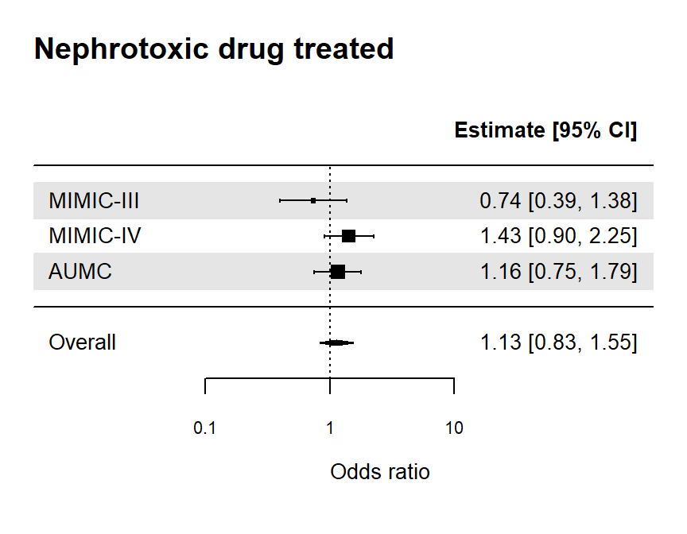

```r
METAF2(nt_METARES_AKI, SCALEAsub2, SCALEBsub2, "Nephrotoxic drug treated")
```

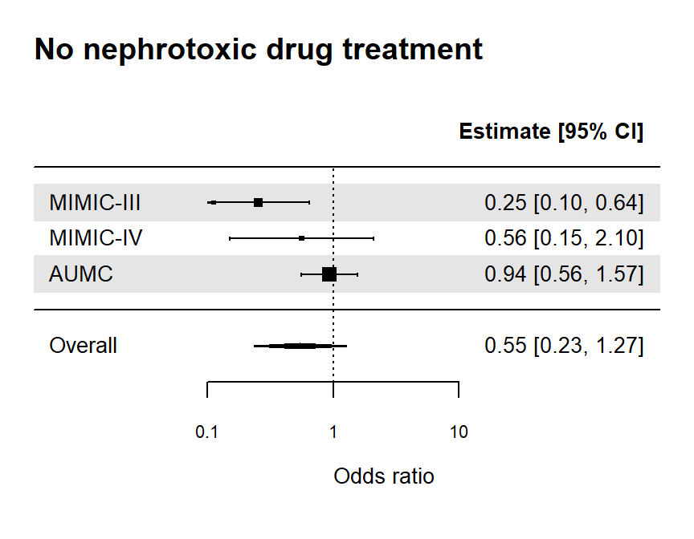

```r
METAF2(nont_METARES_AKI, SCALEAsub2, SCALEBsub2, "No nephrotoxic drug treatment")
```

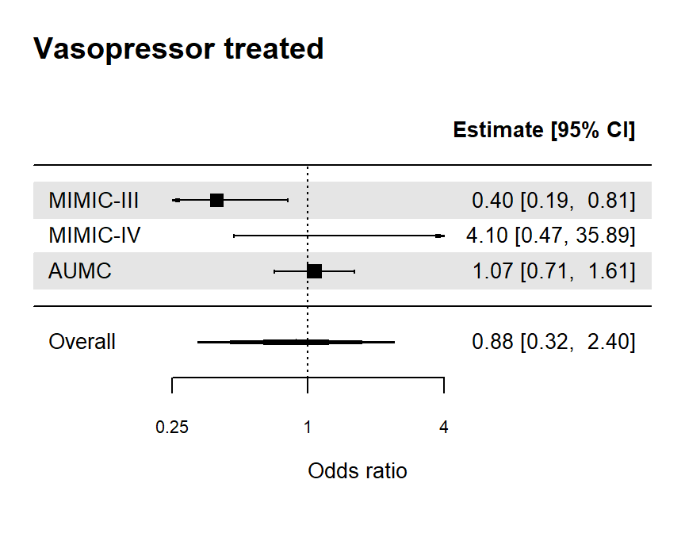

```r
METAF2(vaso_METARES_AKI, SCALEAsub, SCALEBsub, "Vasopressor treated")
```

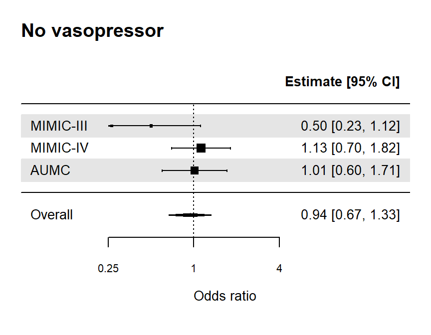

```r
METAF2(nonvaso_METARES_AKI, SCALEAsub, SCALEBsub, "No vasopressor")
```

```r
#export
tiff("eFigure 6 (various subgroup).tif",
     width = 16,
     height = 16,     # Tall file to fit 3 plots vertically
     units = "in",
     res = 300,
     compression = "lzw")
par(mfrow = c(4, 4))
METAF2(Young_METARES_AKI, SCALEAsub, SCALEBsub, "Age < 60y")
METAF2(Old_METARES_AKI, SCALEAsub, SCALEBsub, "Age 60y or older")
METAF2(Male_METARES_AKI, SCALEAsub, SCALEBsub, "Male")
METAF2(Female_METARES_AKI, SCALEAsub, SCALEBsub, "Female")
METAF2(surg_METARES_AKI, SCALEAsub, SCALEBsub, "Surgical unit")
METAF2(nonsurg_METARES_AKI, SCALEAsub, SCALEBsub, "Non-surgical unit")
METAF2(Lsirs_METARES_AKI, SCALEAsub, SCALEBsub, "SIRS<2")
METAF2(Hsirs_METARES_AKI, SCALEAsub, SCALEBsub, "SIRS=2 or higher")
METAF2(bc_METARES_AKI, SCALEAsub, SCALEBsub, "with pre-blood culture")
METAF2(nonbc_METARES_AKI, SCALEAsub, SCALEBsub, "No pre-blood culture")
METAF2(nt_METARES_AKI, SCALEAsub, SCALEBsub, "With nephrotoxic drugs")
METAF2(nont_METARES_AKI, SCALEAsub, SCALEBsub, "No nephrotoxic drugs")
METAF2(vaso_METARES_AKI, SCALEAsub, SCALEBsub, "Treated with vasopressor")
METAF2(nonvaso_METARES_AKI, SCALEAsub, SCALEBsub, "No vasopressor")
dev.off()
```

### **14. Post hoc analysis for revision**

Logistic regression model adjusting for baseline factors, relative carbapenem dose in first 24h, and treatment duration

```r
phDF_m3 <- comb_DF2 %>% subset(dataset=="MIMIC3")
phDF_m4 <- comb_DF2 %>% subset(dataset=="miiv")
phDF_aumc <- comb_DF2 %>% subset(dataset=="AUMC")

#Crude model
LG <- rbind(
  glm(formula=paste("outcome_KDIGO_inc ~", "drug01"), data = phDF_m3, family = binomial(link = "logit")) %>% broom::tidy(exponentiate = T, conf.int = T),
  glm(formula=paste("outcome_KDIGO_inc ~", "drug01"), data = phDF_m4, family = binomial(link = "logit")) %>% broom::tidy(exponentiate = T, conf.int = T),
  glm(formula=paste("outcome_KDIGO_inc ~", "drug01"), data = phDF_aumc, family = binomial(link = "logit")) %>% broom::tidy(exponentiate = T, conf.int = T)) %>%
  subset(term=="drug01") %>% mutate(dataset=c("MIMIC-III", "MIMIC-IV", "AUMC"), model="Crude")

#Model 1<- adjusted with base factors which were used for PSM
PHvars1 <- "drug01 + age_cat + sex + dep_type2 + sirs + pre_blood_culture + nt_drug + vasopressor + base_crea + near_crea + base_KDIGO"
LG1 <- rbind(
  glm(formula=paste("outcome_KDIGO_inc ~", PHvars1), data = phDF_m3, family = binomial(link = "logit")) %>% broom::tidy(exponentiate = T, conf.int = T),
  glm(formula=paste("outcome_KDIGO_inc ~", PHvars1), data = phDF_m4, family = binomial(link = "logit")) %>% broom::tidy(exponentiate = T, conf.int = T),
  glm(formula=paste("outcome_KDIGO_inc ~", PHvars1), data = phDF_aumc, family = binomial(link = "logit")) %>% broom::tidy(exponentiate = T, conf.int = T)) %>%
  subset(term=="drug01") %>% mutate(dataset=c("MIMIC-III", "MIMIC-IV", "AUMC"), model="Model 1")

#Model 2 <- adjusted with base factors and relative carbapenem dose at first 24h (dose_status2)
PHvars2 <- "drug01 + dose_status2 + age_cat + sex + dep_type2 + sirs + pre_blood_culture + nt_drug + vasopressor + base_crea + near_crea + base_KDIGO"

LG2 <- rbind(
  glm(formula=paste("outcome_KDIGO_inc ~", PHvars2), data = phDF_m3, family = binomial(link = "logit")) %>% broom::tidy(exponentiate = T, conf.int = T),
  glm(formula=paste("outcome_KDIGO_inc ~", PHvars2), data = phDF_m4, family = binomial(link = "logit")) %>% broom::tidy(exponentiate = T, conf.int = T),
  glm(formula=paste("outcome_KDIGO_inc ~", PHvars2), data = phDF_aumc, family = binomial(link = "logit")) %>% broom::tidy(exponentiate = T, conf.int = T)) %>%
  subset(term=="drug01") %>% mutate(dataset=c("MIMIC-III", "MIMIC-IV", "AUMC"), model="Model 2")

#Model 3 <- adjusted with base factors and treatment duration
PHvars3 <- "drug01 + last_drug_in_obs + age_cat + sex + dep_type2 + sirs + pre_blood_culture + nt_drug + vasopressor + base_crea + near_crea + base_KDIGO"
LG3 <- rbind(
  glm(formula=paste("outcome_KDIGO_inc ~", PHvars3), data = phDF_m3, family = binomial(link = "logit")) %>% broom::tidy(exponentiate = T, conf.int = T),
  glm(formula=paste("outcome_KDIGO_inc ~", PHvars3), data = phDF_m4, family = binomial(link = "logit")) %>% broom::tidy(exponentiate = T, conf.int = T),
  glm(formula=paste("outcome_KDIGO_inc ~", PHvars3), data = phDF_aumc, family = binomial(link = "logit")) %>% broom::tidy(exponentiate = T, conf.int = T)) %>%
  subset(term=="drug01") %>% mutate(dataset=c("MIMIC-III", "MIMIC-IV", "AUMC"), model="Model 3")

#Model 4 <- adjusted with base factors, relative dose at first 24h, and treatment duration
PHvars4 <- "drug01 + dose_status2 + last_drug_in_obs + age_cat + sex + dep_type2 + sirs + pre_blood_culture + nt_drug + vasopressor + base_crea + near_crea + base_KDIGO"
LG4 <- rbind(
  glm(formula=paste("outcome_KDIGO_inc ~", PHvars4), data = phDF_m3, family = binomial(link = "logit")) %>% broom::tidy(exponentiate = T, conf.int = T),
  glm(formula=paste("outcome_KDIGO_inc ~", PHvars4), data = phDF_m4, family = binomial(link = "logit")) %>% broom::tidy(exponentiate = T, conf.int = T),
  glm(formula=paste("outcome_KDIGO_inc ~", PHvars4), data = phDF_aumc, family = binomial(link = "logit")) %>% broom::tidy(exponentiate = T, conf.int = T)) %>%
  subset(term=="drug01") %>% mutate(dataset=c("MIMIC-III", "MIMIC-IV", "AUMC"), model="Model 4")

comb_LG <- rbind(LG, LG1, LG2, LG3, LG4) %>%
  mutate(OR_fmt = round(estimate, 2),
         lower_fmt = round(conf.low, 2),
         upper_fmt = round(conf.high, 2),
         p_fmt = round(p.value, 3),
         table=paste0(OR_fmt, " [", lower_fmt, ", ", upper_fmt, "]"))

comb_LG %>% subset(dataset=="MIMIC-III") %>% dplyr::select(model, table, p_fmt) %>% arrange(model) %>% rename("MIMIC-III"="model")
```

```
## # A tibble: 5 × 3
##   `MIMIC-III` table             p_fmt
##   <chr>       <chr>             <dbl>
## 1 Crude       0.5 [0.28, 0.87]  0.017
## 2 Model 1     0.43 [0.22, 0.81] 0.011
## 3 Model 2     0.42 [0.22, 0.79] 0.009
## 4 Model 3     0.41 [0.21, 0.77] 0.007
## 5 Model 4     0.4 [0.2, 0.76]   0.006
```

```r
comb_LG %>% subset(dataset=="MIMIC-IV") %>% dplyr::select(model, table, p_fmt) %>% arrange(model) %>% rename("MIMIC-IV"="model")
```

```
## # A tibble: 5 × 3
##   `MIMIC-IV` table             p_fmt
##   <chr>      <chr>             <dbl>
## 1 Crude      1.18 [0.75, 1.83] 0.458
## 2 Model 1    1.26 [0.78, 1.99] 0.333
## 3 Model 2    1.28 [0.8, 2.03]  0.297
## 4 Model 3    1.26 [0.78, 1.99] 0.339
## 5 Model 4    1.28 [0.79, 2.02] 0.303
```

```r
comb_LG %>% subset(dataset=="AUMC") %>% dplyr::select(model, table, p_fmt) %>% arrange(model) %>% rename("AUMC"="model")
```

```
## # A tibble: 5 × 3
##   AUMC    table             p_fmt
##   <chr>   <chr>             <dbl>
## 1 Crude   1.1 [0.77, 1.57]  0.613
## 2 Model 1 1.06 [0.72, 1.56] 0.785
## 3 Model 2 1.07 [0.64, 1.79] 0.805
## 4 Model 3 1.03 [0.7, 1.53]  0.875
## 5 Model 4 1.03 [0.62, 1.74] 0.906
```